# Algoritmos en Bioinformática Estructural

# 2 TEORÍA: Plegamiento y dinámica de macromoléculas

Ahora que conocemos de qué están hechas las macromoléculas y sabemos lo importantes que son en biologı́a, haremos un pequeño repaso sobre las ideas centrales del proceso de plegamiento (*folding*), responsable de que estas moléculas adquieran la estructura tridimensional que les confiere su función.

## 2.1 Plegamiento y desnaturalización

El interés sobre el plegamiento de las macromoléculas se despertó al estudiar sus reacciones de desnaturalización. Si tenemos proteı́nas o ácidos nucleicos en disolución y cambiamos de forma notable las condiciones en que suelen encontrarse en su medio biológico, pierden su estructura y función nativas. Este proceso, llamado reacción de desnaturalización, puede ser reversible en ciertas condiciones y los cambios pueden ser por ejemplo de temperatura, por encima de su temperatura de fusión ($T_{m}$), o en la naturaleza del solvente.  
Anfinsen et al. (1961) mostró experimentalmente que la desnaturalización es reversible al menos para proteı́nas pequeñas, añadiendo y retirando agentes desnaturalizantes a disoluciones de enzimas que ganaban y perdı́an su actividad. Ası́ demostró que el plegamiento de una proteı́na depende exclusivamente de su secuencia, aunque hoy sabemos que algunas necesitan la ayuda de chaperoninas (Hartl and Hayer-Hartl 2002).  
Todavía hoy el proceso de plegamiento no se comprende bien debido a su complejidad (ver secciones 2.3 y 2.4), aunque llevemos décadas estudiándolo (Dill and MacCallum 2012). Sí sospechamos que es un proceso robusto, dado que las proteínas globulares mayormente toleran mutaciones al azar (Escobedo et al. 2025).

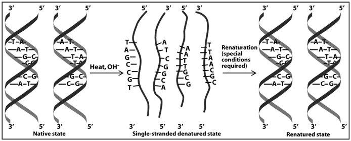

Figura. Reacción de desnaturalización y renaturalización (hibridación) de una molécula de ADN, tomada de Hernandez-Lemus, Nicasio-Collazo, and Castaneda-Priego (2012) y reproducido con permiso de los autores.

La $T_{m}$ de los ácidos nucleicos es proporcional al contenido en bases GC de su secuencia, ya que estos pares de bases (ver figura 1.17) establecen entre sı́ 3 puentes de hidrógeno, mientras que los AT/AU sólo 2. Si la temperatura supera $T_{m}$, las moléculas de ADN se separan en dos hebras polinucleotı́dicas (como se muestra en la figura 2.1), pero si la bajamos lentamente ambas hebras vuelven a unirse de forma complementaria en una reacción llamada hibridación. De nuevo vemos cómo en este caso la secuencia es suficiente para guiar el plegamiento, al menos para moléculas pequeñas.

## 2.2 Fuerzas que influyen en el proceso de plegamiento de macromoléculas

Se han reconocido varias propiedades e interacciones fı́sicas que guı́an al proceso de plegamiento, como las que mencionamos en la sección 1.2.3. Algunas son especı́ficas del plegamiento de proteı́nas, como la formación de enlaces disulfuro entre cisteı́nas o la formación de puentes salinos entre aminoácidos básicos y ácidos, pero en general se acepta que las principales son la hidrofobicidad en un medio acuoso y la formación de puentes de hidrógeno (Dill 1990; Lehninger 1982; Mathews, Holde, and Ahern 1999).

Algunas de estas propiedades pueden estimarse directamente desde la secuencia. Por ejemplo, se han propuesto escalas de hidrofobicidad como la de la tabla siguiente, que quedan englobadas en clasificaciones de aminoácidos como la de sección 1.5.

| A | 1.8 | M | 1.9 |
| --- | --- | --- | --- |
| C | 2.5 | N | -3.5 |
| D | -3.5 | P | -1.6 |
| E | -3.5 | Q | -3.5 |
| F | 2.8 | R | -4.5 |
| G | -0.4 | S | -0.8 |
| H | -3.2 | T | -0.7 |
| I | 4.5 | V | 4.2 |
| K | -3.9 | W | -0.9 |
| L | 3.8 | Y | -1.3 |

**Tabla**. Escala de hidrofobicidad de los 20 aminoácidos, con valores positivos para los residuos hidrofóbicos y negativos para los demás (Kyte 1982).

Como resultado del proceso de plegamiento en medios acuosos, las macromoléculas se empaquetan mostrando hacia el solvente superficies hidrofı́licas y ocultando los componentes más hidrofóbicas. En el interior las interacciones de van der Waals dan estabilidad al conjunto. Como siempre, hay excepciones notables (Sun et al. 2014). En el caso de las proteı́nas otro factor que condiciona el plegamiento es su tendencia natural a formar multı́meros (Garcia-Seisdedos et al. 2017).

## 2.3 Complejidad algorı́tmica del plegamiento

Sabemos que bajo condiciones fisiológicas el proceso de plegamiento es termodinámicamente favorable, es decir, que las macromoléculas son más estables en su conformación nativa que en otras posibles conformaciones. Y conocemos al menos los factores más importantes que afectan y guı́an al proceso de plegamiento. Por último, sabemos que el plegamiento es un proceso rápido, que tarda a lo sumo tiempos del orden de segundos. A pesar de esto, a dı́a de hoy no sabemos predecir de forma precisa cómo se plegará una proteı́na o un ácido nucleico partiendo solamente de su secuencia.

Cuáles son las dificultades? Esto lo veremos tomando como ejemplo las proteı́nas, que se han estudiado mucho más a este nivel. Son fundamentalmente dos:

- el enorme número de posibles conformaciones que puede tomar una cadena polipeptı́dica
- la necesidad de cuantificar la estabilidad en condiciones fisiológicas de cada una de ellas

El proceso de plegamiento puede entonces verse como una exploración en un embudo (*funnel*) como el de la figura 2.2, donde observamos un máximo de estabilidad que se corresponde con un mínimo de energía libre (conformaciones nativas), y otros máximos secundarios o locales denominados estados metaestables. En ciertas condiciones las proteínas pueden quedarse atrapadas en estos estados y perder funcionalidad o agregarse, de ahí la importancia de las chaperonas (Pascual García 2014).

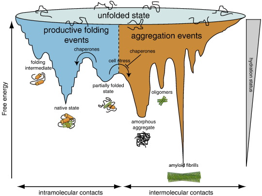

Figura. Superficie energética del plegamiento de proteı́nas desde su sı́ntesis hasta su estado final plegado o agregado. Algunas conformaciones metaestables deben superar barreras energéticas para retomar su ruta de plegamiento favorable, en ocasiones con ayuda de chaperonas (izquierda). Cuando varias moléculas se pliegan en el mismo compartimento pueden formar contactos que propicien la acumulación de agregados amorfos, oligómeros tóxicos o fibrillas amiloides (derecha). Figura tomada de Amm, Sommer, and Wolf (2014) y reproducida con permiso de los autores.

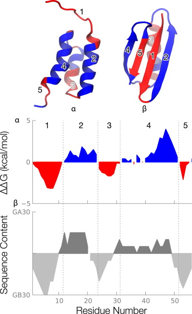

Figura. Contribuciones de cada uno de los residuos de una proteı́na camaleónica, que puede adoptar un plegamiento $\alpha$ (izquierda) u otro $\alpha + \beta$ (derecha) con muy pocos cambios en la secuencia. Arriba: los residuos que favorecen el plegamiento se empaqueten en la estructura globular correspondiente. Medio: las medidas de energı́a libre por residuo revelan las partes de la secuencia que favorecen el plegamiento. Abajo: la energı́a libre por residuo puede generalmente atribuirse a la secuencia (GA30 o GB30) que favorece cada plegamiento. Figura tomada de Roy et al. (2014) y reproducida con permiso de los autores.

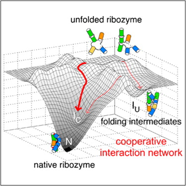

Figura. Embudo de plegamiento de una ribozima. Figura de Behrouzi et al. (2012) y reproducida con permiso de los autores.

Desde este punto de vista, la búsqueda de la conformación nativa es como buscar una aguja en un pajar. Cómo es el espacio de conformaciones? Lo veremos por medio de la paradoja de Levinthal.

## 2.4 Paradoja de Levinthal

En una proteı́na los enlaces peptı́dicos son rı́gidos pero hay 2 enlaces libres de girar por cada aminoácido, a parte de que cada cadena lateral puede orientarse de diferentes maneras. Parece por tanto que realmente es una cadena muy flexible, que puede adoptar muchas conformaciones diferentes. [Cyrus Levinthal](http://en.wikipedia.org/wiki/Levinthal's_Paradox), en 1969, fue el primero en hacer una estimación. El razonamiento es la siguiente:

- digamos que cada aminoácido de una cadena puede tomar $X$ estados diferentes
- una proteı́na de tamaño medio tiene, digamos, 100 aminoácidos
- digamos que cada cambio de estado en un medio fisiológico tarda un tiempo $t$
- entonces el tiempo $T_{expl}$ que llevarı́a explorar todos los estados serı́a de $t X^{100}$

Para $X$ pequeños, como $10$, y tiempos muy cortos, como $10^{-13} s$, $T_{expl} = 10^{-13} 10^{100} = 10^{87}s$. Ahora compárese este valor con los $5s$ que tarda la bacteria *Escherichia coli* en sintetizar una proteı́na de 100 residuos completamente funcional.

Levinthal concluyó que las proteı́nas naturales no se pliegan siempre, pues no tienen tiempo de explorar extensivamente todas las conformaciones. Propuso que hay otras conformaciones cercanas igualmente funcionales en términos fisiológicos. En la actualidad esto se ha interpretado además como una evidencia de que el plegamiento no es totalmente aleatorio, sino que es un proceso por etapas, que reduce en muchos órdenes de magnitud la búsqueda de conformaciones (Mathews, Holde, and Ahern 1999; Burra et al. 2009; Sali, Shakhnovich, and Karplus 1994).

## 2.5 Aproximaciones a la velocidad de plegamiento de proteı́nas

Desde un punto de vista químico podríamos definir el proceso de plegamiento (P) como una reacción, opuesta a la desnaturalización (D), en estos términos (donde $k$ es la constante de equilibrio):
$$k_{d}/k_{p}=[prot_{D}]/[prot_{P}] = k$$

Por otro lado, Gong et al. (2003) encontraron otra fuerte correlación entre el contenido en estructura secundaria de una secuencia de aminoácidos, su longitud, y su velocidad de plegamiento. La función que definen tiene esta forma (donde H, T y B son fracciones de residuos en esos estados de estructura secundaria y $L$ es la longitud de la secuencia):

$$ln(k_{p}) = 8{.}9T + 14H + 5{.}5B + \frac{121{.}4}{L} - 2{.}8$$

donde $k_{p}$ se mide en $1/s^{6}$. Estas correlaciones sugieren que el factor limitante del proceso de plegamiento es la formación de elementos de estructura secundaria.

El problema de estos métodos es que exigen conocer la estructura de la proteı́na en cuestión, aunque se podrı́an aplicar usando predicciones de estructura secundaria y de orden de contactos.

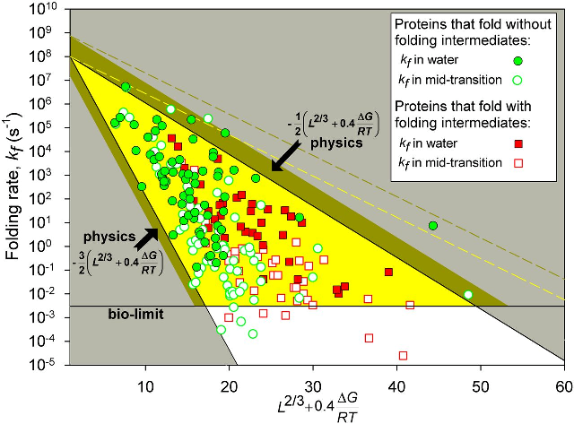

Figura. La velocidad de plegamiento medida experimentalmente para muchas proteı́nas se ciñe a una región triangular. $L$ es la longitud en residuos de cada secuencia estudiada. Figura de Garbuzynskiy et al. (2013), reproducida con permiso de los autores.

## 2.6 Algoritmos de dinámica molecular y plegamiento

Llegados a este punto ya podemos estudiar los principales algoritmos que se han aplicado al problema del plegamiento y la predicción de estructura de macromoléculas. Podemos clasificarlos por el nivel de detalle que utilizan. La escala va desde métodos que modelan cada uno de los átomos de las macromoléculas en cuestión y del solvente en que se encuentran, hasta métodos donde se manejan aminoácidos o incluso elementos de estructura secundaria como un todo indivisible y se ignora o modela de forma implı́cita el solvente. Se pueden ampliar estos contenidos en (Pascual García 2014).

### 2.6.1 Modelos bidimensionales de plegamiento de proteı́nas

Los primeros modelos bidimensionales (Dill et al. 1995; Moreno-Hernandez and Levitt 2012; Shakhnovich and Gutin 1993), que usan un alfabeto reducido donde los aminoácidos son polares (P) o hidrofóbicos (H) y donde las cadenas se pliegan en una malla bidimensional, sirvieron para aproximarse al plegamiento de una forma simplificada. En general se acepta que estos modelos reproducen las caracterı́sticas más importantes del proceso de plegamiento real con la ventaja de ser más manejables:

- se forman estructuras secundarias, que limitan la velocidad del proceso
- el plegamiento se hace por etapas y está dominado por la hidrofobicidad

Vamos a definir más formalmente este modelo, porque ilustra de forma sencilla los algoritmos de dinámica molecular que mencionaremos en la siguiente sección:

- dado el alfabeto {H,P}, una proteı́na es una secuencia de longitud N, tal como `HHHPPPHHPPPPPHHHPPPPHHH`.
- las proteı́nas viven en una malla bidimensional, como la de la figura 2.6, donde cada posición no puede estar ocupada por más de un residuo.
- cada celda de la malla tiene 4 vecinos: N, S, E y O.
- cada residuo está dado en coordenadas internas empezando por el extremo, por ejemplo el residuo 2 está al N del 1.
- hay por lo tanto un máximo de $4^{N}$ conformaciones posibles.
- no se admiten cruces en la secuencia.
- cuando dos residuos no contiguos en secuencia ocupan celdas vecinas se dice que interaccionan.
- la energı́a de cada interacción se evalúa usando la matriz de la tabla siguiente.
- la conformación nativa es aquella que minimiza la energı́a total, maximizando la estabilidad.

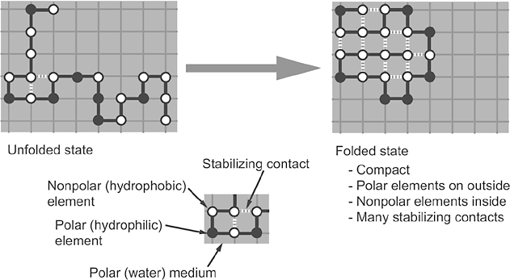

Figura. Plegamiento en dos dimensiones en el modelo HP de Dill et al. (1995). Copyright (1995) Protein Science.

|  | P | H |
| --- | --- | --- |
| P | 0 | -1 |
| H | -1 | -3 |

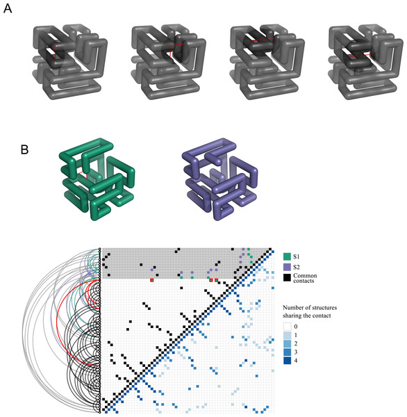

Figura. Ampliación del modelo de Dill a tres dimensiones implementada en el juego SNAKE de Nido et al. (2016). Debajo se muestran matrices de contactos correspondientes a algunos de los plegamientos. Figura reproducida con permiso de los autores.

### 2.6.2 Modelos tridimensionales de mecánica molecular

Los modelos tridimensionales de la [mecánica molecular](http://es.wikipedia.org/wiki/Modelado_molecular) son conceptualmente similares al modelo HP, pero en espacios tridimensionales, normalmente considerando al solvente de forma explı́cita o implı́cita y los enlaces entre átomos (o grupos de átomos) como muelles gobernados por la ley de Hooke. En estos modelos, la energía asociada a la conformación de una molécula se calcula en un campo de fuerzas. De esta manera, para cada conformación molecular se puede calcular su energía potencial por medio de funciones que incluyen términos que consideran las longitudes y ángulos de los enlaces, las torsiones entre grupos vecinos (diedros) y las interacciones no covalentes entre átomos (Van der Waals, Coulomb y puentes de H por ejemplo):

$$potencial(r_{N}) = w_{1} \cdot enlaces(r_{N}) + w_{2} \cdot \acute{a}ngulos(r_{N}) + w_{3} \cdot torsiones(r_{N}) + w_{4} \cdot interacciones(r_{N})
\label{eq:PnR}$$

donde $w_{1},w_{2},w_{3},w_{4}$ son los pesos de cada término y $r_{N}$ las coordenadas de $N$ átomos de la molécula.

Derivando la energía potencial entre conformaciones obtenemos la fuerza. Por tanto, una simulación de dinámica molecular (MD) es un experimento que evalúa la fuerza resultante sobre cada átomo de una molécula a lo largo de un tiempo finito. Durante el tiempo simulado la molécula va cambiando de conformación en intervalos consecutivos muy cortos, del orden de picosegundos. Actualmente se consiguen simular hasta milisegundos (Shaw et al. 2010). Éstos son experimentos muy costosos en cuanto a recursos de cómputo, pero permiten estudiar procesos poco accesibles experimentalmente, como en el trabajo de Golosov et al. (2010), donde se explora el mecanismo de translocación de la RNA polimerasa. Este problema se presta muy bien a la computación distribuida, por su elevado coste, como en el experimento [Folding@Home](http://folding.stanford.edu/) o el juego [Foldit](http://fold.it/portal/).

Este tipo de simulaciones van siendo cada vez más realistas, por ejemplo por medio de mejores modelos de solventes (S. Lee et al. 2013), y se ha demostrado que predicen de manera reproducible el plegamiento de algunas proteínas de pequeño tamaño (Lindorff-Larsen et al. 2011). Sin embargo sigue siendo complicado aplicar MD a moléculas y complejos de gran tamaño, que requiren de simulaciones muy largas y por tanto enormes recursos computacionales. Un buen texto para ampliar estos conceptos es Leach (2001) y en español Bueren-Calabuig (2014).

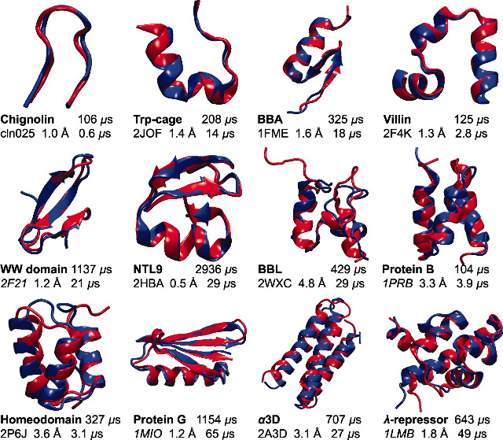

Figura. Plegamientos experimentales de 12 proteínas pequeñas (rojo) superpuestas sobre estados plegados por dinámica molecular (azul), junto con sus tiempos de plegamiento. Figura de (Lindorff-Larsen et al. 2011) reproducida con permiso.

### 2.6.3 Modelos aproximados

En contraste con los algoritmos de dinámica molecular, que no se pueden ejecutar en cualquier hardware, tenemos a nuestro alcance otros métodos más simples que no modelan necesariamente el proceso de plegamiento pero permiten obtener inferencias estructurales, a partir de la secuencia, de calidad suficiente para muchas aplicaciones biológicas. Al ser heurísticas, estas estrategias suelen tener un nicho de aplicación muy restringido, y su validación es normalmente empírica. A pesar de ello muchos de estos métodos han tenido y tienen un gran impacto y tienen la ventaja de que, en general, se pueden realizar en cualquier computador. Los siguientes capítulos del curso se centran en algunos de estos métodos.

Para proteı́nas podemos mencionar algunos ejemplos:

- Observación de los patrones de sustitución de aminoácidos en familias de proteı́nas a lo largo de la evolución, que pueden explotarse para aplicaciones tan variadas como:
  - Predicción de estructura secundaria por aprendizaje automático, normalmente por medio de redes neuronales (Jurtz et al. 2017), como se describe en la sección 4.2.
  - Algoritmos de predicción de regiones intrı́nsecamente desordenadas (Dunker et al. 2008) y de amiloides (Bryan et al. 2011; Agostini, Vendruscolo, and Tartaglia 2012). Se mencionan en la sección 4.2.
  - Modelos topológicos de proteı́nas de membrana, que predicen hélices transmembrana e infieren qué partes de la secuencia son citoplásmicas y exteriores (Perez-Aguilar and Saven 2012; Nugent and Jones 2012).
  - Predicción de efectos y fenotipos de mutaciones no sinónimas en proteı́nas (sección 5.6).
  - Definición de modelos evolutivos especı́ficos de familias de proteı́nas (Arenas et al. 2017), que son la base de los protocolos de *fold recognition* de la sección 5.2 y de predicción de contactos de la sección 5.5. Estos algoritmos están a medio camino de los de modelado estructural que se mencionan a continuación.
- Aproximación a la estructura nativa, y a su función, a partir de otras estructuras conocidas:
  - modelado de estructura terciaria por comparación con proteı́nas de estructura conocida (sección 5.3).
  - protocolos de modelado de estructura terciaria a base de fragmentos, que simulan el proceso de plegamiento (normalmente denominados *ab initio*, sección 5.4)

Dentro del ámbito de los ácidos nucleicos:

- Algoritmos de predicción de estructura secundaria de ARN (sección 4.1).
- Métodos de predicción de estabilidad de la doble hélice de ADN y predicción de promotores (sección 3.1).
- Predicción de la estructura tridimensional de un genoma (sección 1.4).

[figure not shown]

Figura. Modelo recortable de la doble hélice de ADN.

## 2.7 Foldit: jugando a plegar proteínas

Una forma divertida y amena de poner en práctica muchos de los conceptos teóricos que acabamos de repasar es jugar a [*Foldit*](https://fold.it), un juego que incluye un tutorial donde se pueden aprender de manera intuitiva las reglas del plegamiento de proteínas y cómo se empaquetan los elementos de estructura secundaria para formar dominios que cumplen una función. Una vez superado el tutorial se puede jugar en comunidad resolviendo problemas de plegamiento reales (Eiben et al. 2012; Khatib et al. 2011; Cooper et al. 2010). El juego se actualiza regularmente desde 2008.

Muestro algunas capturas de pantalla del tutorial, donde se pueden deshacer choques estéricos o favorecer la formación de puentes de hidrógeno:

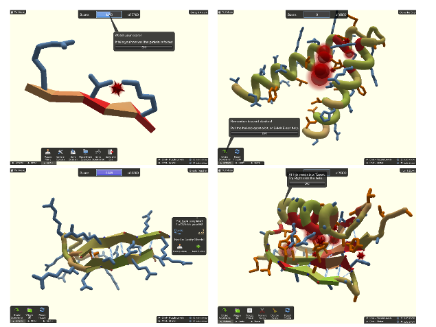

Figura. Capturas de pantalla del juego Foldit en su versión para Linux.

[figure not shown]

Figura. Capturas de pantalla del software standaloneFoldit en su versión para Windows, libre para uso académico. A diferencia del juego, que es un cliente online, esta aplicación permite importar y exportar moléculas en formato PDB y por tanto puede usarse como herramienta de modelado interactiva (Kleffner et al. 2017).

El cliente Foldit está disponible en https://fold.it/play para Linux, MacOS y Windows (en Ubuntu 24 requiere [freeglut3-dev](https://askubuntu.com/questions/1526992/is-there-a-reason-24-04-lts-noble-numbat-does-not-provide-libglut-so-3)).

Hay también una versión completa *standalone* en https://fold.it/dist/external/standalone/quickstart.html, que tiene la ventaja que puedes usar para editar tus propios ficheros en formato PDB.

Familiarizarse con las operaciones habituales para manipular y modificar estructuras moleculares de proteínas, por ejemplo con Foldit, facilita el aprendizaje de plataformas especializadas como https://sbl.inria.fr.

# 3 Estructura primaria o secuencia

En estas secciones veremos dos ejemplos de algoritmos que utilizan secuencias de DNA y proteı́nas con el objeto de estudiar procesos que dependen de propiedades estructurales.

## 3.1 Estabilidad y deformación de un dúplex de ADN: predicción de promotores

El modelo *Nearest Neighbor* (NN) aproxima la estabilidad termodinámica de un ácido nucleico en disolución a partir de su secuencia, que se analiza como una secuencia de dinucleótidos solapantes de interacciones aditivas, cuyas energías se han determinado experimentalmente (Breslauer et al. 1986; SantaLucia 1998).

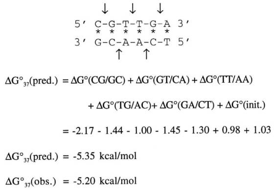

Figura. Cálculo de estabilidad (energía libre de Gibbs, $\Delta G$) a temperatura fisiológica en base al modelo NN, incluyendo un término de iniciación de dúplex, tomado de (SantaLucia 1998). Copyright (1998) National Academy of Sciences.

Inspirándose en estructuras moleculares conocidas, este tipo de modelos se han empleado para describir la lectura indirecta del DNA, por su forma, por parte de nucleosomas (Heijden et al. 2012) o factores de transcripción (Michael Gromiha et al. 2004; Espinosa Angarica et al. 2008).

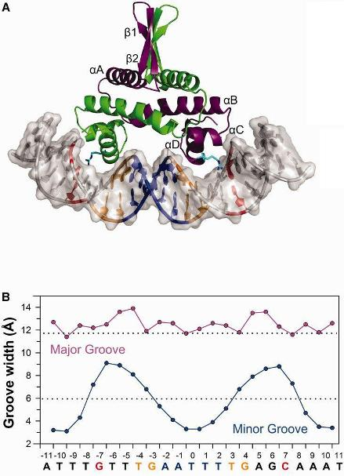

Figura. (A) Estructura de un homodímero de Fis unido a un sitio de alta afinidad (PDB: 3IV5), insertando dos hélices en dos surcos mayores consecutivos. (B) Ancho del surco mayor (magenta) y menor (MGW, azul) a lo largo de la secuencia de DNA medido entre los fosfatos más cercanos. Las lineas punteadas representan los valores canónicos para B-DNA. Figura adaptada de Hancock et al. (2013) y reproducida con permiso de los autores.

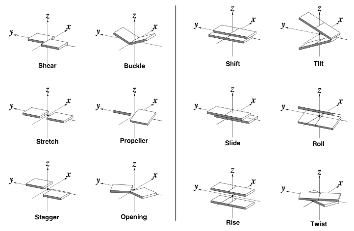

Figura. Propiedades de pares de bases (izquierda) y dinucleótidos (derecha) que se pueden estimar a partir de la estructura. Figura tomada de [x3dna.org](http://x3dna.org/articles/seeing-is-understanding-as-well-as-believing).

Otros modelos amplían el número de vecinos considerados hasta llegar, por ejemplo, a pentámeros:

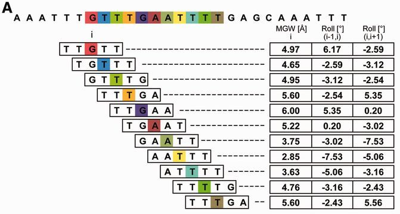

Figura. Aproximación de propiedades estructurales (MGW=minor groove width) de un dúplex de ADN por solapamiento de pentámeros, base del algoritmo [DNAshape](http://rohsdb.cmb.usc.edu). Reproducido con permiso de Zhou et al. (2013). Este tipo de aproximaciones se están usando para enriquecer motivos de DNA reconocidos por factores de transcripción (J. Yang and Ramsey 2015).

En esta sección aplicaremos el modelo NN a la predicción de promotores:

- **PROBLEMA:** disponemos de coordenadas genómicas de una colección de marcos de lectura ([*Open Reading Frames, ORFs*](http://es.wikipedia.org/wiki/Marco_abierto_de_lectura)), pero desconocemos la posición de sus secuencias promotoras
- **SOLUCIÓN PROPUESTA:** buscar los promotores en la secuencia del DNA por su menor estabilidad termodinámica

Este problema ha tenido mayor importancia en procariotas por la gran velocidad con que se han ido obteniendo sus secuencias genómicas, y el algoritmo de (Kanhere and Bansal 2005) es un ejemplo de como emplear una estrategia estructural para atacar este problema. El algoritmo consiste en estimar la estabilidad helicoidal del ADN cromosómico, que se supone es menor en las regiones promotoras, donde la maquinaria transcripcional se asienta para comenzar la síntesis de ARN. En concreto este método estima la estabilidad de una (ventana de) secuencia de ADN a ambos lados de una coordenada y define como posibles posiciones promotores aquellas donde la diferencia de estabilidad en torno a una coordenada es significativa.

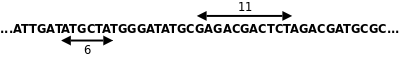

Figura. Ejemplos de ventanas de 6 y 11 nucleótidos, que sirven para promediar propiedades a lo largo de la secuencia.

Este algoritmo incluye varios parámetros libres y en el artículo original se muestra como entrenarlo para obtener valores adecuados para todos ellos.

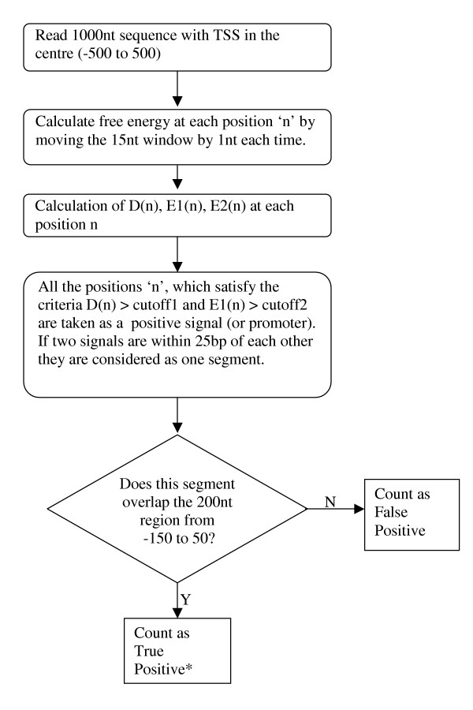

Figura. Algoritmo de (Kanhere and Bansal 2005), que se basa en calcular la diferencia de $\Delta G$ entre dos ventanas en torno a una posición $n$. Figura reproducida con permiso de los autores.

Se han propuesto otras aproximaciones estructurales, como la de (Goñi et al. 2007), que identifica regiones promotoras en base a la capacidad de deformación de los [pares de bases](http://nar.oxfordjournals.org/content/31/17/5108/F1.large.jpg), estimada por medio de extensas simulaciones moleculares precalculadas.

El repertorio de métodos para predicción de promotores en base a inferencias estructurales es limitado, pero incluye al menos: ProSOM o el algoritmo de Song (2012). Otras opciones recientes se basan en combinar diferentes fuentes por medio de algoritmos de aprendizaje (Eser and Churchman 2016).

El ejercicio de esta sección consiste en completar el siguiente programa, usando los parámetros unificados de (SantaLucia 1998), para calcular la diferencia de estabilidad $D(n)$ entre dos fragmentos de 50bp y 100bp $E1(n)$ y $E2(n)$ que flanquean una región central (de 50bp) que podría albergar el promotor. A su vez, estos framentos se calculan sobre valores de estabilidad calculados sobre ventanas de secuencia de longitud 15pb en el artículo de (Kanhere and Bansal 2005):

$$E1(n) = \frac{\sum_{n}^{n+49}\Delta G}{50}$$

$$E2(n) = \frac{\sum_{n+99}^{n+199}\Delta G}{100}$$

$$D(n) = E1(n) - E2(n)$$

Como conjunto de datos para la predicción de promotores usaremos las secuencias del fichero K12_400_50_sites, que contiene coordenadas de ORFs de *Escherichia coli* con coordenadas -400,+50, con el 0 centrado cerca del codón de inicio. Qué observas al cambiar el tamaño de la ventana? [[fuente: prog1.1.pl]](https://github.com/eead-csic-compbio/bioinformatica_estructural/blob/master/code/prog1.1.pl)

## 3.2 Diseño de primers para PCR

La reacción en cadena de la polimerasa ([PCR](http://es.wikipedia.org/wiki/Reacci%C3%B3n_en_cadena_de_la_polimerasa)) es una metodología estándar en cualquier laboratorio de biología molecular y consta fundamentalmente de 3 fases que se repiten un número de ciclos dentro de un tubo de ensayo que se encuentra en un baño:

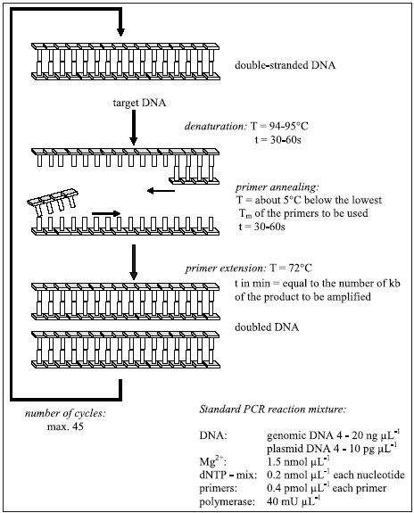

Figura. Diagrama de flujo de una reacción de PCR, que consiste en ciclos donde se repiten 3 fases: desnaturalización, apareamiento y elongación. En la primera el ADN se desnaturaliza separándose las dos hebras. En la segunda los cebadores o primers se hibridan con las hebras de ADN en posiciones donde las secuencias son complementarias y se forman puentes de H entre bases enfrentadas. Es una renaturalización parcial que se hace ajustando la temperatura a la secuencia de los cebadores. Finalmente, en la tercera etapa se ajusta la temperatura para favorecer la extensión de la nueva hebra a partir de los cebadores por parte de la polimerasa. El tiempo de extensión es proporcional a la longitud del producto de PCR (o amplicón) esperado en función de los cebadores diseñados por el usuario y el genoma en cuestión. Figura de (Konietzny and Greiner 2003) reproducida con permiso de los autores.

Para cada aplicación de la PCR es necesario ajustar las condiciones y el diseño de la reacción, por ejemplo:

- la duración de las fases de apareamiento y elongación
- el tipo de cebadores o *primers* empleados y sus temperaturas de fusión $T_{m}$ (ver sección 2.1)
- el tipo de polimerasa utilizada
- las cantidad de los reactivos y de ADN molde
- la longitud del amplicón o producto de PCR obtenido

En esta sección veremos algunos de los algoritmos habituales para el diseño de cebadores, que deben cumplir al menos tres condiciones:

- Una pareja de cebadores debe tener temperaturas de alineamiento muy cercanas para maximizar el rendimiento, lo cual suele traducirse en un contenido en GC similar, entre 50% y 60%.
- Los primers no deben favorecer horquillas (*hairpins*) ni ser complementarios. El siguiente esquema muestra un cebador con una horquilla potencial a la izquierda y un par de cebadores que se aparean a la derecha:

  ```
            5'GGGAAA                    5' GGGAAAATTCCAGGATCTAT 3'
               |||| )                       ||||  ||||
   3' TATCTAGGACCTTA            3' TATCTAGGACCTTAAAAGGG 5'
  ```

- Tras analizar una gran colección de primers publicados en la literatura, parece que conviene evitar secuencias que terminen en GGG,GGT,ATT,CGA,TAA o TTA (Onodera 2007).

Hay muchos programas que pueden ayudar en el diseño de primers en la web, como por ejemplo:

- [primer3](http://bioinfo.ut.ee/primer3/)
- [Vector NTI](http://en.wikipedia.org/wiki/Vector_NTI)
- *in silico* PCR en [procariotas](http://insilico.ehu.es/PCR/) y en [animales](http://genome.ucsc.edu/cgi-bin/hgPcr)

o estos otros para diseñar primers degenerados, que permiten reconocer y por tanto amplificar varias secuencias similares

- [amplicon](http://amplicon.sourceforge.net/)
- primers4clades (específico para aplicaciones filogenéticas, utiliza CODEHOP)

Sin embargo, más allá del software elegido, es importante saber cómo se calculan ciertas propiedades moleculares de los primers, para poder analizar con criterio los resultados obtenidos.

Por ejemplo, nos puede interesar calcular la $T_{m}$, que es la temperatura a la que la mitad de los primers se han hibridado con el ADN molde, o la cantidad de ADN bicatenario a cualquier temperatura, por ejemplo a la temperatura de apareamiento, la más crítica, que a menudo se aproxima como $T_{m} - 5$.

Una aproximación burda es llamada regla de Wallace, que se basa solamente en la secuencia, donde GC y AT son el número de nucleótidos G/C y A/T en la secuencia del cebador, respectivamente (SantaLucia 2007):
$$T_{m} \sim 4GC + 2AT$$

Otra alternativa más precisa es la siguiente ecuación, que relaciona exactamente la temperatura con la proporción de ADN bicatenario, donde $[A]$ es la concentración de hebras en exceso (los primers), $[B]$ el ADN molde que queremos amplificar, $\Delta H$ el cambio de entalpía, $\Delta S$ el cambio de entropía y $R$ la [constante de Boltzmann](http://en.wikipedia.org/wiki/Boltzmann_constant) (R=1.987 cal/mol K):
$$T_{m} = \frac{1000 \Delta H}{\Delta S + Rln([A]-\frac{[B]}{2})} - 273.15$$

En la práctica combinamos esta ecuación con el modelo *Nearest Neighbor* (NN, sección 3.1), usando valores experimentales de entalpía y entropía obtenidos para dinucleótidos.

Con el objetivo de probar estas recetas el siguiente ejercicio incluye:

- usar cualquier software que conozcas (o de los citados arriba) para diseñar varios primers
- con ayuda del siguiente código Python evaluar parejas de primers teniendo en cuenta su $T_{m}$ de fusión y su potencial de formación de horquillas
- compara las $T_{m}$ obtenidas con las que resultan de aplicar la regla de Wallace
- prueba a modificar el código para calcular temperaturas de alineamiento donde la proporción de primer hibridado sea por ejemplo del 95% [[fuente: prog1.2.py]](https://github.com/eead-csic-compbio/bioinformatica_estructural/blob/master/code/prog1.2.py)

# 4 Estructura secundaria

## 4.1 Estructura secundaria de RNA

En contraste con las moléculas de DNA, que en sus papeles más comunes actúan como dobles hélices, las moléculas de RNA pueden adoptar una mayor variedad de conformaciones, igual de complejas que las de las proteínas, que a su vez les permiten tener diferentes funciones , ya sea mensajero, RNA de transferencia, ribosomal, regulador o enzima. Por primera vez en este curso vamos a ir un poco más allá de lo que expresa una secuencia lineal:

- **PROBLEMA:** desconocemos la estructura de una molécula de hebra sencilla de RNA pero conocemos su secuencia
- **SOLUCIÓN PROPUESTA:** predecir su estructura secundaria en base a las subsecuencias complementarias que contiene

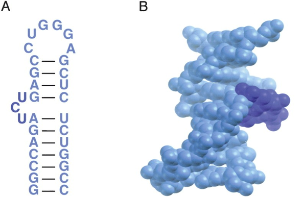

Figura. Estructura secundaria de un RNA (A) correspondiente a la estructura (B), tomada de (Noller 2004) y reproducida con permiso.

La estructura secundaria de una molécula de RNA, sostenida por medio de puentes de hidrógeno (de tipo Watson-Crick y [Hoogsteen](http://en.wikipedia.org/wiki/Hoogsteen_base_pair)) entre nucleótidos, puede aproximarse a partir del conocimiento de la secuencia, aunque obviamente se pierde parte de la complejidad del plegamiento, como sugiere la figura 4.1. Para qué sirven este tipo de predicciones? Por ejemplo, para descubrir RNAs no codificantes, que a menudo tienen funciones biológicas importantes, como se discute en el artículo de (Washietl, Hofacker, and Stadler 2005). Hay muchos programas disponibles que pueden ayudarnos en este tipo de tareas, como [MC-Fold | MC-Sym](http://www.major.iric.ca/MC-Pipeline), [UNAFold](http://www.unafold.org), [Vienna](http://www.tbi.univie.ac.at/~ivo/RNA/), [RNAz](http://www.tbi.univie.ac.at/~wash/RNAz/), [infernal](http://infernal.janelia.org/).

Un programa complementario, que asigna elementos de estructura secundaria dadas unas coordenadas en formato PDB, es [DSSR](https://x3dna.org).

Aquí nos vamos a centrar en ilustrar el algoritmo de Nussinov et al. (1978) para predecir estructura secundaria de RNA por medio de alineamientos, que usa una estrategia de programación dinámica (DP) para maximizar el número de puentes de hidrógeno que se forman dentro de la secuencia. Éste puede decirse que es el algoritmo fundamental para resolver este problema aunque tiene algunas limitaciones. Por ejemplo, no considera la posibilidad de pseudonudos ([*pseudoknots*](http://en.wikipedia.org/wiki/Pseudoknot)) ni tiene en cuenta el apilamiento de bases (*base stacking*), un tipo de interacción que favorece la estabilidad de estas estructuras, elementos que sí son proyectados en el [software actual](http://en.wikipedia.org/wiki/List_of_RNA_structure_prediction_software) (Dotu, Stich, and Aguirre 2014).

El código fuente que se muestra implementa este algoritmo, evaluando recursivamente hasta 4 situaciones en cada posición de la matrix DP (Eddy 2004):

- caso1: nuevo par de bases alineado
- caso2: indel en un extremo, se conserva score anterior
- caso3: indel en extremo opuesto, se conserva score
- caso4: bifurcación en base $k$ si hay distancia suficiente

[[fuente: prog2.1.pl]](https://github.com/eead-csic-compbio/bioinformatica_estructural/blob/master/code/prog2.1.pl)

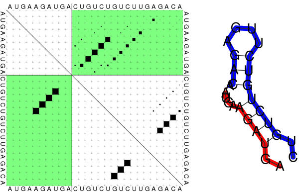

Figura. Estructura secundaria de una molécula de RNA y matriz (dot plot) que esquematiza sus puentes de hidrógeno. Figura tomada de (Bernhart et al. 2006) y reproducida con permiso.

## 4.2 (Des)estructura secundaria de proteı́nas

La estructura secundaria es una propiedad de las proteı́nas naturales en solución, que se explica por medio de una red (dinámica) de puentes de hidrógeno que conectan diferentes partes del polipéptido a escala más o menos local, formando hélices y láminas que quedan conectadas por lazos (*loops*) y regiones desordenadas, como ya recordamos en la sección 1.3.2.

Si disponemos de las coordenadas atómicas de una proteína podemos medir sus ángulos diedros para generar nuestros propios diagramas de Ramachandran, con dos fines:

- Comprobar qué residuos de la secuencia se encuentran en conformaciones (regiones) favorables, como medida de calidad de la estructura.
- Averiguar en base a la geometría del esqueleto proteico el estado de estructura secundaria de segmentos de residuos.

El procedimiento, dado unas coordenadas en formato PDB ([1LFU](https://github.com/eead-csic-compbio/bioinformatica_estructural/blob/master/code/files/1lfu.pdb)), es relativamente sencillo, haciendo un poco de álgebra y trigonometría: [[fuente: prog2.2.pl]](https://github.com/eead-csic-compbio/bioinformatica_estructural/blob/master/code/prog2.2.pl)

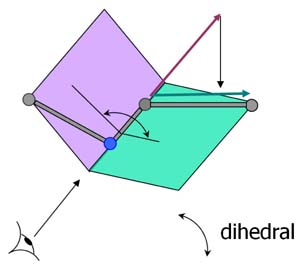

Figura. Definición de ángulo diedro, figura tomada de http://structuralbioinformatics.com.

Otras definiciones de estructura secundaria se basan en encontrar patrones de puentes de hidrógeno entre grupos $-CO$ y $-NH$ del esqueleto peptídico, como por ejemplo hace el software [DSSP](https://swift.cmbi.umcn.nl/gv/dssp) (Kabsch and Sander 1983) de acuerdo con esta definición energética, donde un puente válido debe tener $E<-0{.}5 kcal/mol$, $q_{1}=0.42e$, $q_{2}=0.20e$ y $r$ es una distancia interatómica en Angstroms:
$$E = q_{1} q_{2} \left[ \frac{1}{r_{ON}} + \frac{1}{r_{CH}} - \frac{1}{r_{OH}} - \frac{1}{r_{CN}} \right] \cdot 332 \ \mathrm{kcal/mol}
\label{eq:dssp}$$

El software [STRIDE](http://webclu.bio.wzw.tum.de/stride) (Frishman and Argos 1995) es otro programa para este fin que en experimentos de validación mejora las asignaciones de estructura secundaria de DSSP.

Sin embargo, frecuentemente el problema es todavía más complicado:

- **PROBLEMA:** tenemos una secuencia proteica pero no conocemos su estructura
- **SOLUCIÓN PROPUESTA:** reconocer en la secuencia segmentos que formen hélices y láminas, y lazos para caracterizar su topología o estructura secundaria

Si calculamos alineamientos múltiples de secuencias de proteínas homólogas, las columnas del alineamiento resultante permiten deducir patrones de sustitución de aminoácidos que son específicos de posición. Esta fuente de información evolutiva, combinada con algoritmos basados en [redes neuronales](https://en.wikipedia.org/wiki/Artificial_neural_network) más o menos [profundas](https://bioinfoperl.blogspot.com/2020/04/redes-neuronales-profundas.html), permite predecir con una precisión cercana al 75% la estructura secundaria en 3 estados (H=hélice alfa, E=lámina beta y C=coil). Es evidente que se pierde información con este alfabeto, pero la estructura inferida puede tener muchas aplicaciones a la hora de diseñar experimentos y algoritmos que trabajen sobre la estructura terciaria.

Hay una buena exposición de este tema en (Jones 1999), donde se presenta el algoritmo [PSIPRED](http://bioinf.cs.ucl.ac.uk/psipred) y se evalúa la precisión de las asignaciones de estructura secundaria de varias maneras, incluyendo la función:
$$Q_{3} = \frac{\sum\limits_{i=H,E,C}{corrpred_{i}}}{\sum\limits_{i=H,E,C}{obs_{i}}} \times 100$$

En Jurtz et al. (2017) se explica en mayor detalle cómo funcionan este tipo de predictores, incluyendo [código fuente en python2.7](https://github.com/vanessajurtz/lasagne4bio) para programar uno.

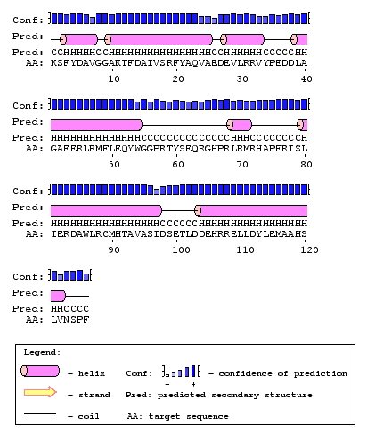

Figura. Ejemplo de predicción de estructura secundaria de PSIPRED, obtenida en el servidor [PSIPRED](http://bioinf.cs.ucl.ac.uk/psipred).

PSIPRED es aceptado como uno de los mejores predictores, pero hay muchos otros algoritmos de predicción de estructura secundaria y la mejor manera de compararlos es por medio de evaluaciones automáticas a ciegas. Desgraciadamente, este tipo de iniciativas, como LiveBench o EVA, que recolectan datos de distintos algoritmos a medida que crece el PDB, son financiadas por poco tiempo y mueren.

Tras la aparición de los primeros predictores de estructura secundaria empezó a ser evidente que muchas proteínas, sobre todo de vertebrados, no tenían aparentemente una estructura ordenada, al menos en ciertos estados fisiológicos (ver por ejemplo el repositorio [Disprot](http://www.disprot.org) (Sickmeier et al. 2007; Inmaculada Yruela 2014)). Hoy sabemos que muchas proteínas ordenadas pueden contener segmentos desordenados o dúctiles (Lobanov et al. 2010). Como resultado se diseñaron predictores para un cuarto estado, el de desorden intrínseco, y se han creado recursos para la anotación de estas secuencias como [D2P2](http://d2p2.pro).

En el caso de PSIPRED, la evolución es un software de nombre DISOPRED (Ward et al. 2004), que además de reconocer elementos de estructura secundaria estima la probabilidad de que cada residuo esté desordenado, sin pertenecer a ninguna clase de estructura secundaria.

La mayoría de predictores de estructura secundaria y desorden tienen mejores resultados cuando extraen información evolutiva de secuencias homólogas. Sin embargo, esto implica que estos algoritmos son sensibles al contenido de las bases de datos de secuencias públicas, como se muestra en la siguiente figura:

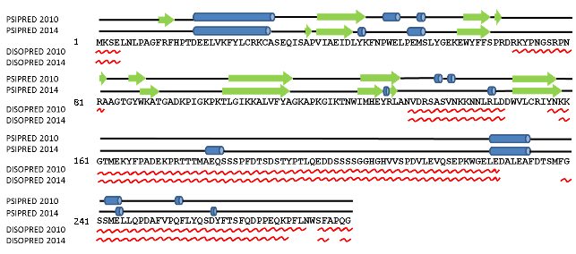

Figura. Comparación de predicciones de PSIPRED (estructura secundaria) y DISOPRED2 (desorden) para la secuencia NAC81 de Arabidopsis thaliana calculadas sobre versiones de 2010 y 2014 de la colección de secuencias [uniref90](https://www.uniprot.org/help/uniref). Se marcan en rojo los segmentos desordenados, las hélices en azul y las láminas $\beta$ en verde. Figura de I. Yruela and Contreras-Moreira (2014).

Otros predictores que combinan estructura secundaria y otras propiedades son s2D o [SSpro](http://scratch.proteomics.ics.uci.edu), rayando el %90 en las validaciones de sus autores (Magnan and Baldi 2014). Probablemente se alcanzado ya el techo para predicciones de 3 estados, pero queda espacio para mejorar las predicciones de los 8 estados de DSSP (Y. Yang et al. 2018).

De acuerdo con meta-análisis recientes los mejores predictores de desorden son [DISOPRED](http://bioinf.cs.ucl.ac.uk/psipred) y [PrDOS](http://prdos.hgc.jp/cgi-bin/top.cgi) (S. Wang, Ma, and Xu 2016; Meng, Uversky, and Kurgan 2017)

El ejercicio de esta sección consiste en calcular la estructura secundaria de una proteı́na del [Protein Data Bank](https://www.rcsb.org) de varias maneras distintas, con el fin de compararlas:

- por medio de PSIPRED, que en realidad es un predictor,
- modificando el código [fuente: prog2.2.pl](https://github.com/eead-csic-compbio/bioinformatica_estructural/blob/master/code/prog2.2.pl), calculando segmentos de secuencia que tengan el mismo estado de estructura secundaria según el diagrama de Ramachandran y
- por medio del programa [DSSP4](https://github.com/PDB-REDO/dssp), que soporta mmCIF, simplificando segmentos de estructura secundaria en 3 estados H,E,C.
- alinea las estructuras secundarias en alfabeto simplificado HEC y describe las diferencias observadas
- debes obtener los ejecutables necesarios por tu cuenta

# 5 Estructura terciaria

De ahora en adelante nos metemos un poco más en el laberinto de la estructura molecular y dejamos definitivamente atrás las representaciones de proteínas o ácidos nucleicos como secuencias lineales, puesto que no sirven para capturar las relaciones espaciales entre diferentes partes o elementos de estructura secundaria de una misma molécula.

## 5.1 Comparación de estructura terciaria entre proteínas

El hecho de que la estructura terciaria está más conservada que la secuencia (ver sección 1.3.5) podemos aprovecharlo para buscar posibles relaciones filogenéticas remotas entre proteínas:

- **PROBLEMA:** disponemos de las coordenadas de dos proteínas A y B y queremos calcular cuánto se parecen sus estructuras
- **SOLUCIÓN:** buscar las subestructuras de máximo tamaño subA y subB que minimizan la distancia entre átomos equivalentes (ver sección 1.3.5)

Repasemos algunos algoritmos fundamentales para calcular la similitud estructural entre parejas de proteínas (hay alguno más en la [WikipediA](http://en.wikipedia.org/wiki/Structural_alignment)):

- Conversión de información estructural en secuencias usando un alfabeto a medida para acelerar la comparación ([Foldseek](https://search.foldseek.com/search), [FoldMason](https://github.com/steineggerlab/foldmason)).
- Alineamiento estructural iterativo ([STAMP](http://www.compbio.dundee.ac.uk/downloads/stamp/)). El primer borrador de alineamiento se calcula con ayuda de matrices de sustitución de aminoácidos como BLOSUM. Éste sirve para calcular la superposición correspondiente y permite refinar el conjunto de residuos equivalentes, aquellos por debajo de cierto umbral de distancia. Estas iteraciones de alineamiento y definición de sobconjuntos de residuos equivalentes se repiten hasta que convergen y el RMSD no mejora (ver Chothia and Lesk (1986) y sección 1.3.5).
- Doble programación dinámica para primero) establecer fragmentos localmente similares entre ambas estructuras y segundo) estimar el subconjunto de fragmentos que producen una superposición óptima ([SSAP](http://sillitoe.cathdb.info/tools/cath-ssap)). Más detalles en este [enlace](http://en.wikipedia.org/wiki/Structural_alignment#SSAP).
- Comparación de matrices de contactos/distancias ([DALI](http://ekhidna.biocenter.helsinki.fi/dali_server)). En vez de trabajar con péptidos en 3D, algo que requiere calcular rotaciones y transforamciones, esta familia de métodos primero convierten cada estructura a su matriz de distancias correspondiente, para luego compararlas entre si.
- Minimización de la información requerida para reconstruir las coordenadas de una estructura dadas las de la otra (mmligner). La virtud de este aproximación es que prescinde de la elección subjetiva de umbrales y define de manera precisa la superposición óptima.
- Superposición de factores de transcripción para deducir el alineamiento correcto de sus sitios *cis* ([TFcompare](https://hub.docker.com/r/eeadcsiccompbio/tfcompare))

Puedes ampliar detalles de estos algoritmos en Alberto Pascual-García (2014a).

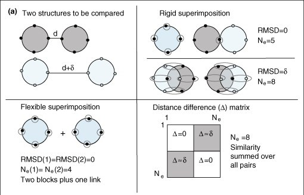

Figura. Tres estrategias (rígida, flexible y elástica) para comparar la estructura terciaria de dos proteínas con dos dominios (círculos) con 4 residuos cada uno, separados por una secuencia de longitud variable. Arriba derecha: la superposición rígida tiene dos opciones: alinear un total de 5 residuos equivalentes ($Ne$) con RMSD bajo o alinear todos ($Ne=8$) con un RMSD alto. Abajo izquierda: una superposición flexible rompe la estructura larga en dos subestucturas para optimizar el RMSD sobre 4 residuos en cada dominio. Abajo derecha: la comparación de matrices de distancias permite alinear ambos dominios maximizando $Ne$. Figura tomada de Hasegawa and Holm (2009) y reproducida con permiso.

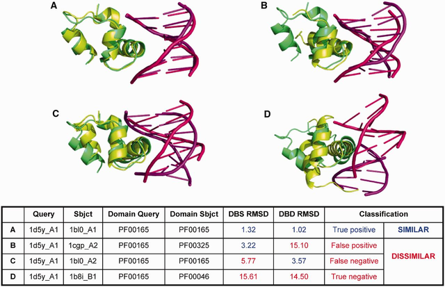

Figura. Superposiciones de dominios de unión a DNA (DBD) de factores de transcripción, que ponen de manifiesto su mecanismo, no siempre conservado, de reconocimiento de sus cis-elementos (DBS). Figura tomada de Sebastian and Contreras-Moreira (2013).

Hay disponibles muchos otros programas disponibles para la comparación estructural de proteínas, y cada usuario tiene el suyo preferido. A qué se debe esto? La razón es que no existe una definición totalmente satisfactoria del alineamiento estructural correcto, que es en definitiva la función que todos estos algoritmos tratan de optimizar. De hecho, ni siquiera está claro si las taxonomías estructurales clásicas, como [CATH](http://www.cathdb.info) o [SCOP](http://scop.berkeley.edu) (Csaba, Birzele, and Zimmer 2009), son compatibles con la evidencia disponible sobre la evolución de los plegamientos (*folds*), que actualmente se imagina como un proceso discreto sólo hasta cierto punto (Taylor 2002; A. Pascual-García et al. 2009; Sadowski and Taylor 2010; Andreeva et al. 2014). De hecho [SCOP2](http://scop2.mrc-lmb.cam.ac.uk/) se hizo para superar esas limitaciones. Otra complicación adicional es que algunos plegamientos pueden verse como permutaciones circulares de elementos de estructura secundaria de otros (Schmidt-Goenner et al. 2010). En cualquier caso siguen siendo ideas útiles como muestra el hecho de que la reciente [TED: The Encyclopedia of Domains](https://ted.cathdb.info) se publicó en 2024 para ampliar el reportorio de dominios conocidos tras la explosión de AlphaFold (Lau et al. 2024).

En general aceptamos que cada superfamilia de proteínas es un clúster de estructuras muy similares, que se pueden superponer aunque su secuencia sea muy diferente, y que cada plegamiento es un subconjunto de superfamilias que comparten una topología de estructura secundaria.

Lo habitual cuando se publica un nuevo método es compararlo con otros preexistentes. Estas comparaciones, si son rigurosas y reproducibles, pueden ayudar en la tarea de seleccionar un programa idóneo para esta tarea. El algoritmo MAMMOTH, uno de los más exitosos en la era pre-AlphaFold, se resumía en estos pasos, en palabras textuales de sus autores (Ortiz, Strauss, and Olmea 2002):

> 1.- From the Calpha trace, compute the unit-vector U-RMS between all pairs of heptapeptides of both model and experimental structure. The U-RMS is described in (Kedem, Chew, and Elber 1999; Chew et al. 1999). This is a measure sensitive to the local structure.

> 2.- Use the matrix derived in step 1 to find and alignment of local structures that maximizes the local similarity of both the model and the experimental structure. For that, use a global alignment method with zero end gaps, as described in (Needleman and Wunsch 1970).

> 3.- Find the maximum subset of similar local structures that have their corresponding Calphas close in cartesian space. “Close” is considered here as a distance less or equal than 4.0 A. The method to find this subset is a small variant of the MaxSub algorithm from the Fischer group (Siew et al. 2000).

> 4.- Obtain the probability of obtaining the given proportion of aligned residues (with respect to the shortest protein model) by chance. This metric (E-value) is then used as the final score (or the corresponding Z-score, both are equivalent for gaussian distri- butions, however the Z-score is a more manegable index). In order to obtain this value, an approach similar to that of (Levitt and Gerstein 1998) is used, as described in (Abagyan and Batalov 1997). The E-value estimation is based on extreme-value fitting. In a test set with the SCOP database, it shows rather good performance.

MAMMOTH fue comparado con varios métodos, como se ve en esta figura:

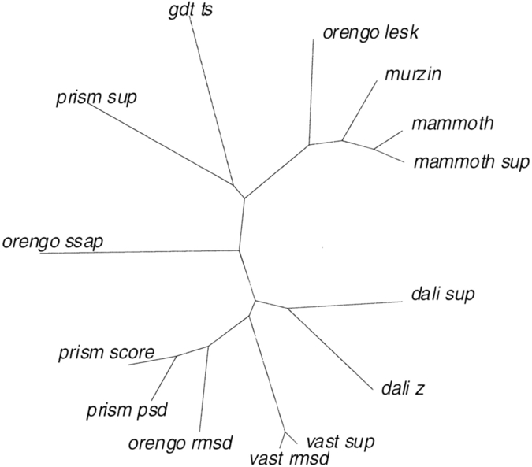

Figura. Semejanza de MAMMOTH respecto a otros algoritmos de comparación de estructura de proteínas, incluyendo el criterio de un experto humano (Murzin). Figura tomada de Ortiz, Strauss, and Olmea (2002). Copyright (2002) Protein Science.

En aquel momento MAMMOTH era junto con DALI de los mejores programas, porque además de generar superposiciones y alineamientos satisfactorios, sus medidas numéricas de similitud devuelven valores que se ajustan a la evaluación visual de la superposición obtenida. En concreto, MAMMOTH devuelve para cada alineamiento una puntuación y su valor esperado asociado (*E-value*), que podemos interpretar de manera análoga a los valores esperados de BLAST, superando las limitaciones del RMSD para comparar estructuras que solamente se parecen en algunas regiones (Siew et al. 2000). Recientemente otros algoritmos han superado a MAMMOTH, sobre todo a la hora de hacer alineamientos estructurales múltiples que combinan estructura y secuencia (Bastolla, Abia, and Piette 2023; Gilchrist, Mirdita, and Steinegger 2026), o de agrupar miles de estructuras de manera eficiente (Barrio-Hernandez et al. 2023).

Para superar las limitaciones del RMSD, que da el mismo peso a regiones del core que a regiones divergentes, Zhang and Skolnick (2004) propusieron otra función, el TM-score, que disminuye el peso de las parejas alineadas a mayor distancia, es menos sensible a la longitud de las estructuras comparadas y toma valores entre 0 y 1:

$$TMscore = max[ \frac{1}{L_{Q}} \sum_{i=1}^{L_{T}} \frac{1}{ 1 + (\frac{d_{i}}{d_{0}})^{2} } ]$$

Aquí $max$ es el valor máximo obtenido en todas las superposiciones calculadas, $L_{Q}$ es la longitud de la estructura Q o *query*, $L_{T}$ es el total de residuos alineados a la estructura T o *template*, $d_{i}$ es la distancia entre la pareja $i$ de residuos y $d_{0}$ el factor de escala para normalizar por longitud de secuencia.

Para calcularlo de manera óptima podemos usar su algoritmo TM-align (Zhang and Skolnick 2005), cuyo código fuente está [disponible](http://zhanglab.ccmb.med.umich.edu/TM-align/TM-align-C/TMalignc.tar.gz). La función TM-score es uno de los estándares para medir el parecido entre estructuras, ya que se acepta que un valor de 0.5 garantiza un plegamiento similar. Se puede calcular en línea en http://zhanglab.ccmb.med.umich.edu/TM-score .

Se han propuesto otras métricas que no requieren superposiciones, por tanto insensibles a sus limitaciones, como la función lDDT (Mariani et al. 2013). lDDT evalúa distancias locales entre átomos vecinos, dentro de un rango de radios, entre un modelo y una estructura de referencia y toma valores en el rango [0,1]. Un valor alto significa que modelo y referencia se parecen mucho (puedes leer más [aquí](https://swissmodel.expasy.org/lddt)). La métrica lDDT puede considerar todos los átomos, incluyendo cadenas laterales, o por ejemplo sólo el esqueleto peptídico.

Para aprender a hacer alineamientos/superposiciones estructurales, y a interpretarlos, podemos hacer este ejercicio:

- Visita [CATH](https://www.cathdb.info) y busca un dominio, por ejemplo ‘homeodomain’, y selecciona un grupo de 5-10 dominios relacionados; ten en cuenta que `3lnqA00` se corresponde con la estructura 3LNQ del Protein Data Bank, cadena A.
- Alinea las estructuras que contienen los dominios elegidos en https://search.foldseek.com/foldmason
- Visualiza la superposición y el correspondiente alineamento de secuencia y descarga los resultados (en formato .png, .pdb y .fasta); guarda también una captura de pantalla del alineamiento múltiple de secuencias.
- Envía los resultados a FoldSeek, ver botón al pie de la página; resume los resultados en una tabla.
- Modificando como veas necesario `foldmason.pdb`, `foldmason_aa.fa` y el código [[fuente: prog3.1.py]](https://github.com/eead-csic-compbio/bioinformatica_estructural/blob/master/code/prog3.1.py) calcula el %identidad y el RMSD de algunas parejas de estructuras superpuestas; resume los resultados en una tabla.

## 5.2 *Protein fold recognition*

Al analizar secuencias genómicas frecuentemente encontraremos marcos de lectura (teóricos) que codifican para proteínas que aparentemente no se parecen a ninguna otra (llamadas a veces *orphans* en la literatura), o que sólo tienen similitudes obvias con proteínas de función desconocida. Esto puede deberse a que de veras son moléculas observadas por primera vez, o como vimos en 1.3.5, a que la evolución ha conservado en mayor grado la estructura y topología de las proteínas homólogas que sus secuencias.

La segunda posibilidad ha justificado una familia de métodos llamados genéricamente de *Fold Recognition* (FR), que tienen como objeto reconocer a qué tipo de plegamiento (de los conocidos) se debe asignar una secuencia problema, especialmente cuando búsquedas más convencionales con [BLAST](http://blast.ncbi.nlm.nih.gov/Blast.cgi) o [FASTA](http://www.ebi.ac.uk/Tools/fasta/index.html) han fracasado. Históricamente algunos de estos métodos se han llamado de [*threading*](http://en.wikipedia.org/wiki/Threading_%28protein_sequence%29), ya que ciertos algoritmos literalmente enhebran la secuencia problema en patrones de coordenadas conocidas, normalmente un subconjunto no redundante del PDB, para ver si es compatible con alguno, como en la siguiente figura:

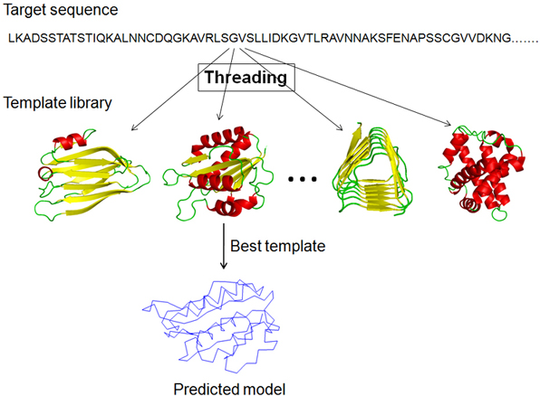

Figura. Diagrama de flujo de los algoritmos de reconocimiento de plegamiento (FR). Figura tomada de (J. T. Guo and Xu 2008). Copyright (2008) Frontiers in Bioscience.

El problema de FR lo podemos plantear así:

- **PROBLEMA:** conocemos la secuencia de una proteína, pero desconocemos su tipo de plegamiento y su función
- **SOLUCIÓN PROPUESTA:** comparar la secuencia con todos los plegamientos conocidos, calcular el grado de parecido/compatibilidad con cada uno de ellos y devolver una lista ordenada

Probablemente la mejor manera de evaluar objetivamente y elegir un método de FR son experimentos colectivos a ciegas con secuencias cuyas estructuras experimentales se hacen públicas tras las entrega de las predicciones. Hay dos tipos de experimentos de este tipo: [CASP](http://predictioncenter.org/index.cgi?page=public_serv), que mide bianualmente la competencia de los algoritmos de los grupos participantes, y [CAMEO](https://www.cameo3d.org), que hace evaluaciones continuas no supervisadas.

En palabras de Kelley et al. (2015), desarrollador principal de [Phyre2](http://www.sbg.bio.ic.ac.uk/phyre2), uno de los más completos, los mejores predictores tienen resultados indistinguibles en la mayor parte de los casos, pero en los casos mas complejos desde hace tiempo destaca por su consistencia y superiores resultados I-TASSER.

Estas herramientas web son adecuadas para estudiar unas pocas secuencias, pero si queremos hacer un experimento de FR a gran escala, entonces buena idea instalar localmente el software elegido, como por ejemplo hh-suite, el software que da vida a [HHpred](https://toolkit.tuebingen.mpg.de/#/tools/hhpred).

El siguiente programa es un prototipo de alineamiento perfil-perfil que usa además predicciones de estructura secundaria (ver figura 4.4) para guiar el alineamiento. Es un algoritmo de programación dinámica, que puedes comprender mejor con ayuda del [*Sequence Alignment Teacher*](http://protein.bio.puc.cl/websoftware/web/?sid=3) (Ibarra and Melo 2010).

Para probarlo necesitaras descargar los archivos de entrada (1ngk_A.pssm, 1s69_A.pssm, 1ngk_A.psipred, 1s69_A.psipred): [[fuente: prog3.2.pl]](https://github.com/eead-csic-compbio/bioinformatica_estructural/blob/master/code/prog3.2.pl)

## 5.3 Modelado de proteı́nas por homología

Con las herramientas que hemos estado manejando ya estamos preparados para modelar proteı́nas. En este contexto modelar significa hacer una predicción de cómo se disponen los átomos de una proteı́na conocida su secuencia, con el fin de estudiar su función molecular, su historia evolutiva o, si el modelo es bueno, diseñar o muestrear ligandos e incluso calcular sus afinidades (Singh and Dominy 2010). Asimismo este tipo de modelos se usan mucho para estudiar el efecto de mutaciones puntuales (Kellogg, Leaver-Fay, and Baker 2011).

- **PROBLEMA:** disponemos de la secuencia de una proteína A y quisiéramos conocer, aunque sea de manera aproximada, su estructura tridimensional
- **SOLUCIÓN PROPUESTA:** estimar coordenadas cartesianas para la mayoría de los átomos de A, en base a la estructura conocida de proteínas similares, que llamamos plantillas, moldes, o *templates*

- Ensamblaje de grandes fragmentos rígidos, incluso el plegamiento entero, obtenidos de estructuras similares alineadas por medio de su secuencia primaria y secundaria ([SWISS-MODEL](http://swissmodel.expasy.org) o [ROBETTA](http://robetta.bakerlab.org). Esta metodología corta y pega literalmente fragmentos del esqueleto peptídico de estructuras conocidas.
- Modelado por satisfacción de restricciones (distancias, ángulos) moleculares extraídas de bases de datos y estructuras similares alineadas ([MODELLER](https://salilab.org/modeller/)). Este método, conceptualmente similar a la resolución por NMR (ver sección 1.4), produce un conjunto de estructuras para la secuencia A, todas ellas compatibles con las restricciones observadas en los *templates*.

El algoritmo genérico de modelado comparativo puede dividirse en varios pasos, ilustrados en la figura 5.6:

- 1. Identificar por similitud de secuencia dominios $D_{1..d}$ en la proteı́na $S$ que queremos modelar.
- 2. Buscar y alinear estructuras molde $M_{1..m}$ que nos sirvan para modelar uno o más dominios de $S$. Cada dominio con al menos un molde es potencialmente modelable.
- 3. Para cada dominio $D_{i}$ modelable:
  - 3.1. Refinar el alineamiento local de cada segmento alineado del molde.
  - 3.2. Tomar las coordenadas peptídicas (o descriptores moleculares) de la estructura molde alineada.
  - 3.3. Copiar los [rotámeros](https://en.wikipedia.org/wiki/Backbone-dependent_rotamer_library) de las cadenas laterales de los aminoácidos conservados en el alineamiento.
  - 3.4. Modelar los rotámeros de los residuos que mutan respecto al molde, con ayuda de una [biblioteca](http://dunbrack.fccc.edu/lab/bbdep2010).

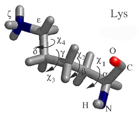

    Ángulos que definen los rotámeros de las cadenas laterales.

El paso 2 es el más determinante sobre la calidad del modelo y de hecho marca el techo de precisión de la metodología (Contreras-Moreira et al. 2005). Es además un paso crítico en el sentido de que si el alineamiento $M_{i}$ es malo, el modelo resultante será malo, como ya vislumbramos en la sección 1.3.5. Para modelos complicados será necesario explorar diferentes combinaciones de moldes y alineamientos para encontrar la mejor solución. Si la secuencia problema es multidominio o multimérica puede ser necesario modelar su estructura cuaternaria (Tramontano 2017), con herramientas especiales como [BAM](http://dunbrack.fccc.edu/lab/bam).

Con el objeto de explicar en mayor detalle el algoritmo, el siguiente código implementa los pasos 3.1 y 3.2, quizás los más fundamentales tras el el paso 2. El programa usa como ejemplo secuencias y estructuras ya utilizadas en el apartado 1.3.5 (1gd6.pdb): [[fuente: prog3.3.py]](https://github.com/eead-csic-compbio/bioinformatica_estructural/blob/master/code/prog3.3.py)

Como en otros campos de la biología computacional, el repertorio de software para modelar proteínas es muy extenso, y constantemente incluye nuevas herramientas que sustituyen a otras que envejecen. Un buen punto de partida para elegir la mejor solución son los *rankings* que actualiza cada dos años [CASP](http://predictioncenter.org/index.cgi?page=public_serv), aunque probablemente los programas de modelado preferidos por los usuarios son SWISS-MODEL en la Web y MODELLER como instalable.

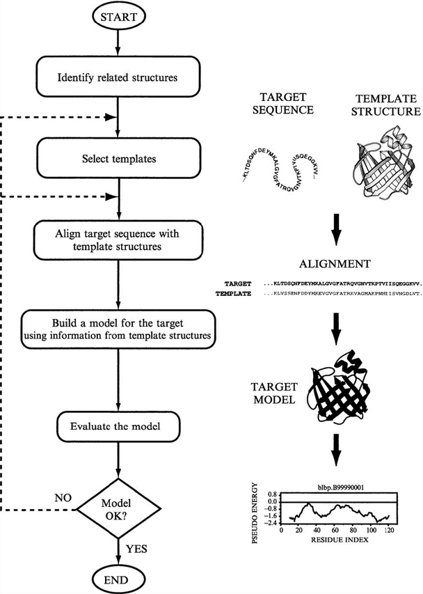

Figura. Algoritmo genérico de modelado comparativo. Figura tomada de Fiser and Sali (2003). Copyright (2003) Methods in Enzymology.

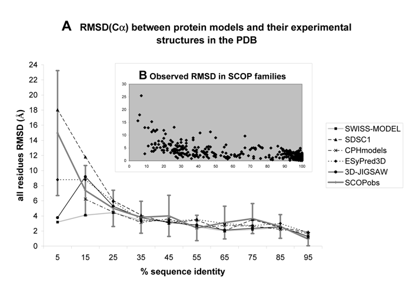

En la práctica podemos hacer nuestros modelos por homología, con la opción de controlar todos los pasos del procedimiento, por medio del programa [MODELLER](https://salilab.org/modeller) (Sali and Blundell 1993), disponible sin costo para usuarios académicos. El programa tiene [múltiples posibilidades](https://salilab.org/modeller/tutorial/), pero en este ejemplo nos centramos en el caso más sencillo consistente en hacer un modelo a partir de un sólo molde o *template*, estimando su calidad del modelo por medio de la función DOPE (Shen and Sali 2006):

- Secuencia problema: [FNR](http://www.expasy.org/uniprot/FNR_ECOLI), regulador transcripcional de *Escherichia coli*.
- Busca, por ejemplo usando PSI-BLAST, secuencias similares (probablemente homólogas) cuya estructura esté en el PDB (moldes o *templates*).
- Para cada uno de los *templates* interesantes sigue estos pasos:
  - descarga el fichero de coordenadas del [PDB](https://www.rcsb.org/pdb) y extrae la secuencia S contenida en los campos `ATOM`
  - alinea la secuencia S de las coordenadas con la secuencia problema (FNR, por ejemplo con [clustal-omega](https://www.ebi.ac.uk/Tools/msa/clustalo) o usando el mismo alineamiento de BLAST) y crea un archivo con extensión `.ali` con este formato, donde `structureX` es el molde, `sequence` es la secuencia problema o *query* y los demás campos definen el rango de residuos alineados del *template*, y su resolución:

    ```
    C; Alineamiento de muestra en formato PIR
    >P1;1PDB
    structureX:1PDB:1    :A:106  :A:nombre_template:: 1.90:
    AFVVTDNCIKCKYTDCVEVCPVDCFYEGPNFLVIHPDECIDCALCEPECPAQAIFSEDEVPEDMQEFIQLNAELA
    EVWPNITEKKDPLPDAEDWDGVKGKLQHLER*
    >P1;query
    sequence:query:::::::0.00: 0.00
    AYVINDSC--IACGACKPECPVNIIQGS--IYAIDADSCIDCGSCASVCPVGAPNPED-----------------
    -------------------------------*
    ```

  - genera un guión o *script* para MODELLER como `guion_nombre_template.py`:

    ```
    from modeller.automodel import *

    log.verbose()
    env = environ()

    # 1) directorio donde se encuentran los ficheros con coordenadas de moldes/templates,
    # con extension .pdb,.atm,.ent
    env.io.atom_files_directory = './templates/'

    # 2) prepara el modelado
    a = automodel(env,
                  alnfile  = 'alineamiento.ali',  # fichero con el alineamiento
                  knowns   = '1PDB',              # nombre del template como aparece en alnfile
                  sequence = 'query',             # nombre de secuencia problema como aparece en alnfile
                  assess_methods=(assess.DOPE))

    a.starting_model= 1                           # define cuantos modelos diferentes quieres
    a.ending_model  = 2

    # 3) accion!
    a.make()
    ```

  - ahora ejecuta MODELLER (por ejemplo poniendo en el terminal: `$ mod9v8 guion_template.py` y al terminar revisa `guion_nombre_template.log` para comprobar la evaluación empírica del modelo o modelos obtenidos

## 5.4 Modelado de proteı́nas *ab initio*

Hablamos de protocolos *ab initio* cuando tratamos de modelar el plegamiento de un polipéptido solamente a partir de su secuencia y de la fı́sica (Baker and Sali 2001). Sin embargo, los métodos de este tipo más exitosos hasta la fecha reconstruyen la estructura terciaria a base de pequeños fragmentos cortados de estructuras conocidas y seleccionados por similitud de secuencia.

El mejor ejemplo es el algoritmo Rosetta (Simons et al. 1997), implementado en el servidor web [ROBETTA](http://robetta.bakerlab.org), que permite modelar secuencias cortas cuando no hay moldes que alineen con la secuencia problema, ni siquiera por *fold recognition* (ver sección 5.2). Usa fragmentos de 9 aminoácidos de longitud. En este caso podemos definir el problema tipo de esta manera:

- **PROBLEMA:** disponemos de la secuencia de una proteína A y quisiéramos conocer, aunque esa de manera aproximada, su estructura tridimensional
- **SOLUCIÓN PROPUESTA:** combinar fragmentos tomados de estructuras del PDB, generar conformaciones alternativas y seleccionar las mejores

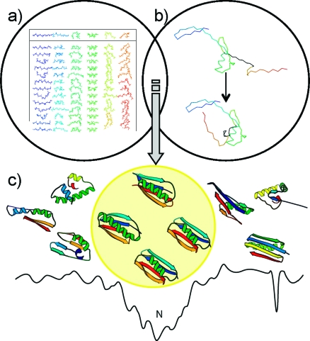

Figura. Resumen del protocolo Rosetta, tomado de Kaufmann et al. (2010). A) Se seleccionan de una biblioteca los fragmentos con secuencias mas parecidas a los $K$-meros de la secuencia problema ($K=9$). B) Combinación de fragmentos solapantes para generar muchas conformaciones alternativas. C) Optimización de conformaciones con funciones que evalúan interacciones no locales. Copyright (2010) Biochemistry.

Este tipo de algoritmos requieren tener precalculada una biblioteca de fragmentos de longitud $K$ de estructura conocida, funciones para seleccionar los mejores fragmentos para cada $K$-mero de la secuencia problema, funciones de evaluación que permitan descubrir conformaciones que se parezcan a las nativas, y muchos recursos computacionales, dado que todos estos pasos son costosos. Otro algoritmo que funciona tanto para *fold recognition* como para modelado *ab initio* es I-TASSER:

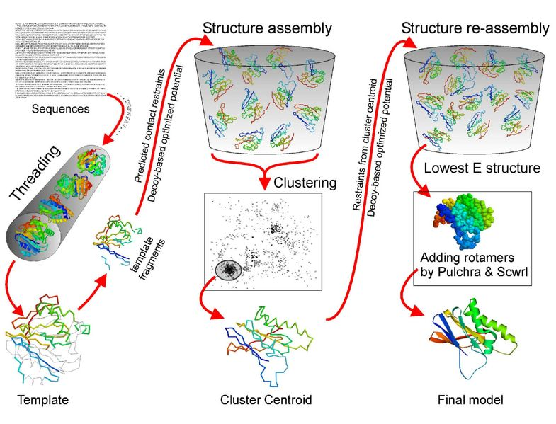

Figura. Resumen del protocolo TASSER. Figura de Wu, Skolnick, and Zhang (2007), reproducida con permiso de los autores.

## 5.5 Modelado de proteínas por predicción de contactos

Las matrices de contactos (ver sección 1.3.3) han sido durante mucho tiempo una fuente de inspiración de métodos de predicción estructural, con la idea subyacente de "si somos capaces de predecir con información evolutiva qué residuos de una secuencia contactan, entonces podremos resolver su estructura" (Gobel et al. 1994; Juan, Pazos, and Valencia 2013).

La información evolutiva en cuestión es normalmente un alineamiento múltiple de secuencias homólogas, que se espera capturen de forma implícita las limitaciones que impone la estructura terciaria de un dominio a las sustituciones de aminoácidos que contactan. La función matemática que se emplea habitualmente para estudiar esto es la [información mutua](http://es.wikipedia.org/wiki/Informaci%C3%B3n_mutua) (MI), que mide la dependencia entre dos variables, en este caso columnas de un alineamiento.

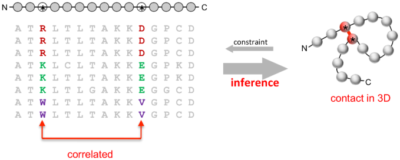

Figura. Las mutaciones correlacionadas entre columnas de un alineamiento múltiple se pueden emplear para predecir contactos entre residuos en el plegamiento. Figura tomada de (Marks et al. 2011) y reproducida con permiso de los autores.

Por tanto, el problema de la predicción de contactos se puede plantear así:

- **PROBLEMA:** conocemos la secuencia de una proteína y las de muchas secuencias homólogas
- **SOLUCIÓN PROPUESTA:** alineamos las secuencias, buscamos posiciones que muestren evidencia de coevolución y buscamos plegamientos compatibles con esos contactos

El algoritmo [EVfold](http://EVfold.org) emplea estos elementos para hacer predicciones de contactos de alta calidad, ya que es capaz de distinguir entre posiciones de la secuencia que directamente contactan (causativas) de las que correlacionan simplemente porque contactan con un mismo residuo (transitivas). Usando su terminología, MI es un modelo local de probabilidad de contactos, que ellos son capaces de corregir y convertir en un modelo global usando conceptos de la mecánica estadística y la maximización de la entropía. El modelo global se llama de Información Directa (DI) (Marks et al. 2011).

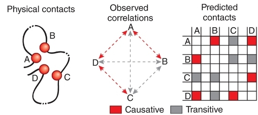

Figura. Definición de contactos entre residuos (A,B,C,D) y de correlaciones directas y transitivas. Figura tomada de (Marks, Hopf, and Sander 2012). Copyright (2012) Nature Biotechnology.

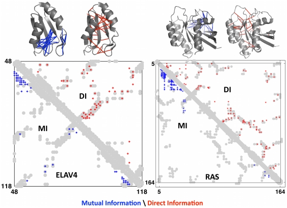

La siguiente figura muestra el diagrama de flujo completo del método [EVfold](http://EVfold.org), que ha sido posteriormente adaptado para proteínas transmembrana (Hopf et al. 2012) y también para complejos cuaternarios (Hopf et al. 2014):

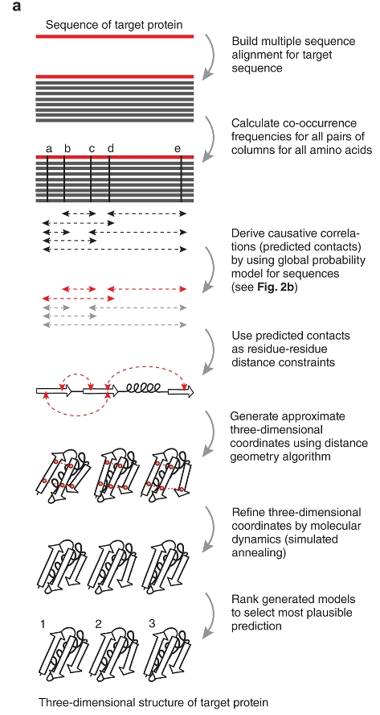

Figura. Algoritmo de plegamiento de proteínas en base a observaciones de mutaciones correlacionadas, que se transforman en predicciones de contactos, tomado de (Marks, Hopf, and Sander 2012). Copyright (2012) Nature Biotechnology.

La siguiente figura muestra los resultados de un experimento de validación de EVfold:

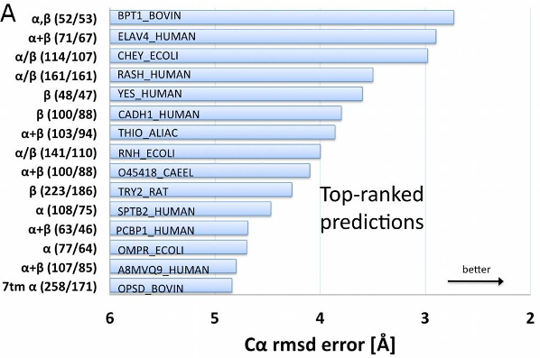

Figura. Calidad de las mejores predicciones de EVfold en un conjunto de 15 proteínas con diferentes composiciones de estructuras secundaria. Entre paréntesis se muestran el número de residuos del dominio modelado y el número de residuos sobre los que se calculó el RMSD entre el modelo y la estructura experimental. Figura tomada de (Marks et al. 2011) y reproducida con permiso de los autores.

Esta familia de métodos se está desarrollando todavía y sigue habiendo avances importantes (Buchan and Jones 2017). El más notable es que el uso de secuencias metagenómicas permite ampliar el universo de secuencias lo suficiente para mejorar las predicciones de contactos (usando por ejemplo [GREMLIN](http://gremlin.bakerlab.org/submit.php)) y obtener así estructuras, de momento bacterianas, de numerosos plegamientos desconocidos (Ovchinnikov et al. 2017). Además, Ovchinnikov et al. (2017) proponen una función para estimar la calidad de los modelos si hay suficientes secuencias para abordar este tipo de modelado:

$$N_{f} = \frac{clusters_{nr80}}{\sqrt L}$$

En esta función el numerador representa el total de clusters de secuencias homólogas no redundantes al 80% encontradas con [HHblits](https://toolkit.tuebingen.mpg.de/#/tools/hhblits) y el numerador es la longitud de la secuencia problema. Cuando $N_{f} > 64$ se obtienen modelos de buena calidad.

Para poner en práctica estos algoritmos se puede realizar el siguiente ejercicio:

- Visita [UniProt](http://www.uniprot.org/), elige una proteína y extrae su secuencia S.
- Busca secuencias similares a S y guárdalas en un archivo.
- Calcula un alineamiento múltiple A que incluya a S con sus homólogos, elimina las secuencias muy cortas y guarda el resultado en un fichero FASTA.
- Con ayuda de los [métodos suplementarios](https://doi.org/10.1371/journal.pone.0028766.s017) de (Marks et al. 2011) modifica el código [fuente: prog3.4.pl](https://github.com/eead-csic-compbio/bioinformatica_estructural/blob/master/code/prog3.4.pl) para calcular el peso de las secuencias en base a su identidad y sumar pseudoconteos y de esa manera calcular con mayor precisión MI en tu alineamiento A. Hay también código fuente disponible en [GitHub](https://github.com/debbiemarkslab/EVcouplings).
- Construye un modelo 3D para S.
- Edita el archivo PDB del modelo y marca algunas parejas de residuos con valores altos de MI. Para ello puedes usar la columna del factor B, dejando a ‘00.00’ el resto de residuos.
- Visualiza el modelo editado y discute los resultados obtenidos.

[[fuente: prog3.4.pl]](https://github.com/eead-csic-compbio/bioinformatica_estructural/blob/master/code/prog3.4.pl)

## 5.6 Mutaciones puntuales de proteínas

Un problema que se presenta con cada vez mayor frecuencia desde que llegaron las tecnologías de ultrasecuenciación es el de estimar el fenotipo molecular de un polimorfismo genético, por ejemplo un SNP que cambia la secuencia de aminoácidos de una proteína al provocar una sustitución no sinónima (*missense*). Esto es necesario porque hay muchos más genotipos que fenotipos observados, y porque cuánto más se secuencia se hace patente que los individuos de una especie son portadores de múltiples mutaciones de diferente naturaleza (Peterson, Doughty, and Kann 2013).

Esto se relaciona con los resultados de Chothia and Lesk (1986), presentados en la sección 1.3.5, que observaron que los efectos de las mutaciones sobre la estructura (y por tanto la función) dependen en parte de dónde se produzcan. No tiene el mismo efecto cambiar un aminoácido enterrado que uno en un *loop*, o uno que coevoluciona con otro de un lazo vecino. Del mismo modo, una sustitución en el interior de una hélice no se puede comparar con la eliminación de un residuo catalítico (Berrondo and Gray 2011) o de otro clave para interaccionar con otras proteínas (Juan, Pazos, and Valencia 2013). El muestreo a gran escala de Rocklin et al. (2017) estudió la estabilidad de miles de miniproteínas (hasta 50aa) sintéticas y unas 500 naturales del PDB nos ha proporcionado los mejores datos hasta la fecha. En esencia lo que hacen es medir la estabilidad de miles de secuencias de aminoácidos expresándolas y exponiéndolas a proteasas en levadura. De esa manera estiman el efecto que tienen mutaciones individuales dependiendo de su contexto de estructura secundaria, ya sea una alfa-hélice, una lámina beta o un lazo o loop:

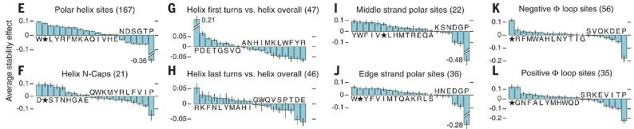

Figura. Efecto sobre la estabilidad de mutaciones en diferentes contextos estructurales. Los valores negativos, como los de la prolina en general, son desestabilizadores. Adaptada de Rocklin et al. (2017). Copyright (2017) Science.

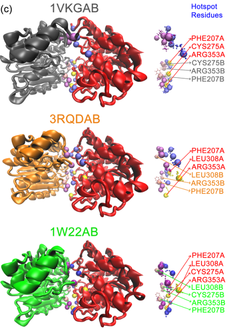

Figura. Grafo de la interfaz entre una histona-deacetilasa (en rojo) y tres parejas distintas. Figura tomada de Cukuroglu et al. (2014) y reproducida con permiso de los autores.

Como se muestra en la figura 5.17, hay una gran variedad de métodos para la inferencia del fenotipo molecular de mutaciones puntuales en proteínas, y solamente algunos usan información estructural. Probablemente el más universal de todos sea SIFT (Kumar, Henikoff, and Ng 2009), que usa como evidencia la historia evolutiva de cada familia de proteínas, que integra entre otras cosas determinantes estructurales siempre y cuando haya suficientes secuencias homólogas conocidas (Saunders and Baker 2002). Sin embargo, como ocurre a menudo en biología computacional, no es sencillo averiguar a partir de un análisis de la literatura qué métodos son mejores. Hay que probarlos y escoger, y entre los disponibles haya cada vez más alternativas que hacen un uso explícito de información estructural, en concreto del contexto del residuo sustituido, como PolyPhen-2 (Adzhubei et al. 2010), SusPect (Yates et al. 2014) o mCSM (Pires, Ascher, and Blundell 2014).

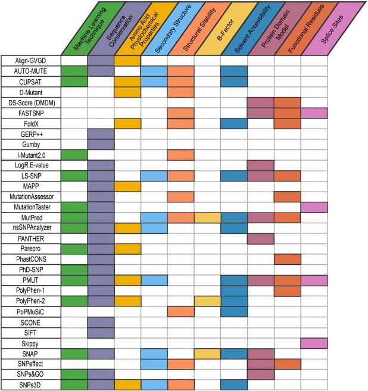

Figura. Clasificación de métodos de inferencia de fenotipos de mutaciones no sinónimas en base a los tipos de datos que emplean. Figura tomada de Peterson, Doughty, and Kann (2013) y reproducida con permiso.

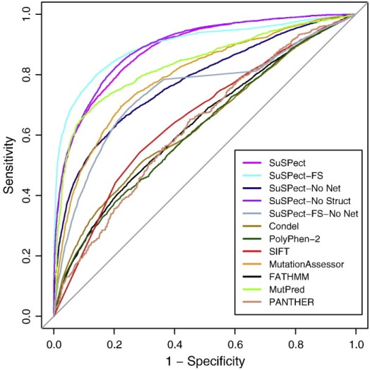

Figura. Comparación del rendimiento de SusPect prediciendo mutaciones humanas deletéreas frente a otros predictores. Figura tomada de (Yates et al. 2014) y reproducida con permiso.

Para explorar la predicción de fenotipos de mutaciones no sinónimas planteo este ejercicio:

- Visita una base de datos de mutantes, como [OMIM](http://www.omim.org), y elige una proteína P (ejemplo: OPCML).
- Obtén la secuencia silvestre de aminoácidos S y al menos otra M con una mutación deletérea.
- Construye un modelo comparativo de M y S.
- Haz predicciones de fenotipo para S y M con ayuda, por ejemplo, de: [SIFT](https://sift.bii.a-star.edu.sg/), [PolyPhen-2](http://genetics.bwh.harvard.edu/pph2/) y [SusPect](http://www.sbg.bio.ic.ac.uk/~suspect).
- Compara las predicciones obtenidas e interprétalas a la luz de las estructuras modeladas. Qué limitaciones del modelado comparativo afloran?

# 6 Estructura cuaternaria

## 6.1 Interfaces moleculares

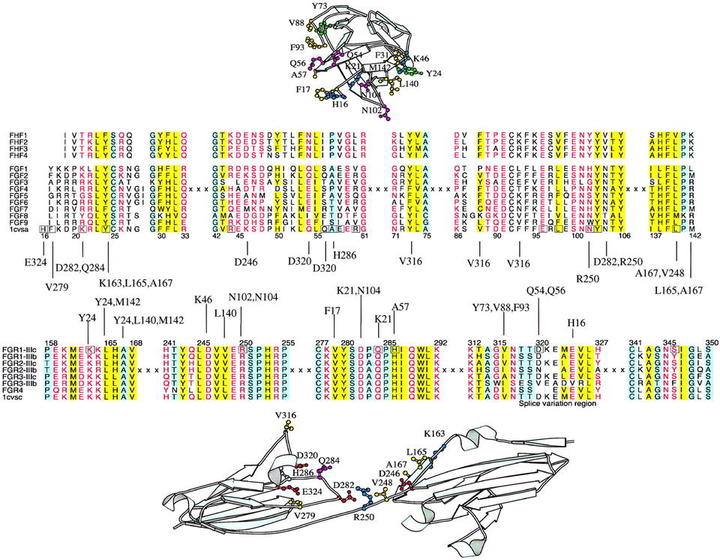

Figura. Interfaz entre dos proteı́nas que forman un heterodímero y conservación de secuencia de los que establecen contactos. Figura tomada de Aloy and Russell (2002). Copyright (2002) National Academy of Sciences.

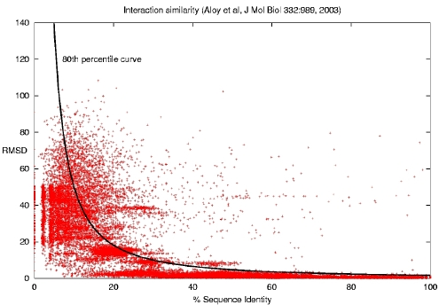

Figura. Relación entre la conservación de secuencia y estructura en las interfaces entre proteı́nas. Figura tomada de Aloy et al. (2003) y reproducida con permiso de los autores.

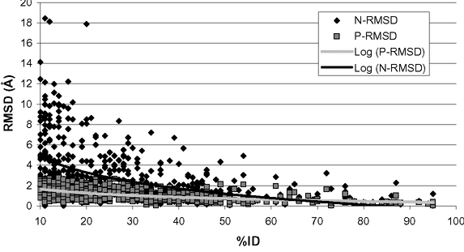

Figura. Relación entre la conservación de secuencia y estructura en las interfaces entre proteı́nas (P) y ácidos nucleicos (N). Figura tomada de Contreras-Moreira and Collado-Vides (2006) y reproducida con permiso de los autores.

Estas observaciones pueden resumirse en esta generalización: proteínas con secuencias parecidas suelen tener interfaces similares cuando forman complejos. Los algoritmos que vamos a ver a continuación, que se justifican (al menos en parte) por estas observaciones, se han aplicado para el diseño de proteínas y sus interfaces, puesto que muchas de sus funciones conocidas dependen de interacciones con otras moléculas. Su diagrama de flujo genérico podría ser éste:

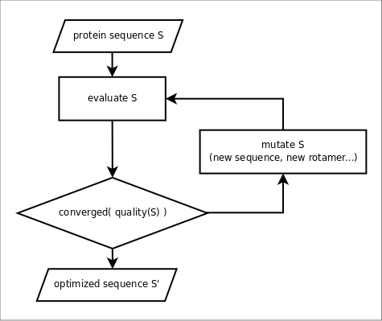

Figura. Protocolo genérico de diseño de proteínas.

De todas maneras hay que ser conscientes de que no deja de ser una simplificación centrarse solamente en la interfaz, pues sabemos que a veces los cambios en zonas lejanas de la proteína son más importantes para su función biológica, por ejemplo entre factores de transcripción parálogos (Hudson et al. 2016).

## 6.2 Optimización de cadenas laterales en interfaces

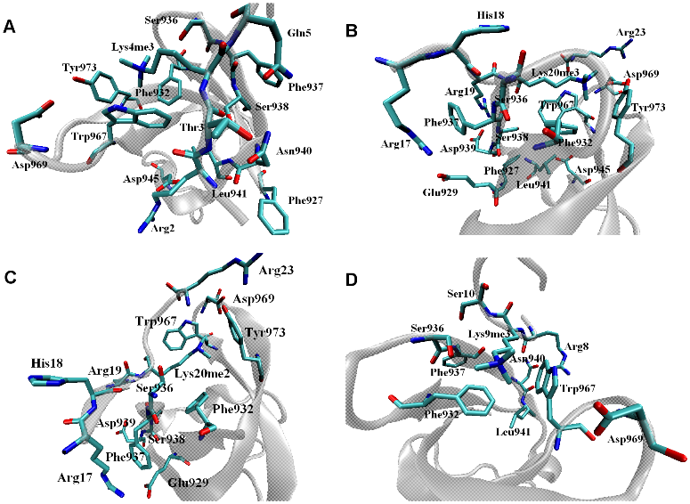

Figura. Fotogramas de simulaciones de dinámica molecular (ver sección 2.6.2) mostrando los rotámeros de residuos de la histona demetilasa JMJD2A involucrados en el reconocimiento de péptidos H3K4me3 (A), H4K20me3 (B), H4K20me2 (C) y H3K9me3 (D). Figura tomada de Ozboyaci et al. (2011) y reproducida con permiso de los autores.

Para entender en mayor detalle este experimento podemos aprender a utilizar el programa [SCWRL](http://dunbrack.fccc.edu/lab/scwrl) (Bower, Cohen, and Dunbrack 1997) (en inglés se pronuncia algo ası́ como ‘ardilla’) que calcula las conformaciones de cadenas laterales (rotámeros) de una proteı́na dada la geometría local (en concreto los ángulos $\phi$ y $\psi$) del esqueleto y las conformaciones de los residuos vecinos. SCWRL explora una biblioteca de cadenas laterales precompiladas, extraı́das del Protein Data Bank.

- Identifica y descarga las estructuras PDB utilizadas en el artı́culo de Reina et al. (2002), cuál de ellas incluye las coordenadas de un péptido? Selecciona ésa.
- Mediante SCWRL calcula los rotámeros más adecuados para el péptido y compáralos con los de las coordenadas experimentales obtenidas del PDB. Observas diferencias importantes?
- Con SCWRL muta el péptido ligando usando algunas de las secuencias del artı́culo (opción `-s`).
- Para cada péptido mutante calcula con SCWRL los rotámeros más adecuados de los residuos del dominio [PDZ](http://pfam.xfam.org/family/PF00595) que lo reconoce. Ves qué residuos han cambiado de rotámero?

Puede parecer razonable asumir que la geometría del esqueleto de la proteı́na se ve poco afectada al sustituir de manera aleatoria rotámeros. Sin embargo, hay estudios que observan que al muestrear cadenas laterales de aminoácidos se producen pequeños cambios conformacionales locales, que se pueden reproducir usando el algoritmo de *backrub* de Davis et al. (2006).

## 6.3 Modelando nucleótidos dentro de una doble hélice de DNA

Al igual que con SCWRL es posible explorar los rotámeros de ciertas posiciones de una estructura proteica (ver 6.2), con el siguiente código, parte del algoritmo DNAPROT de Espinosa Angarica et al. (2008), podemos sustituir bases nitrogenadas a lo largo de una doble hélice de DNA en formato PDB, importando el módulo [bases](https://github.com/eead-csic-compbio/bioinformatica_estructural/blob/master/code/bases.py) y descargando las coordenadas cristalográficas de la proteína dnaA ([PDB 1J1V](http://www.rcsb.org/pdb/explore.do?structureId=1j1v)):

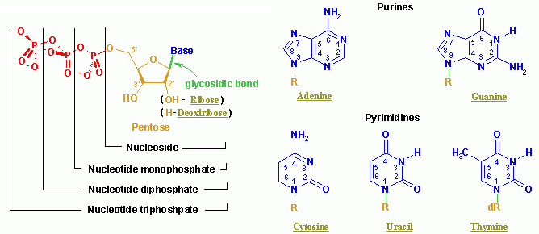

Figura. Nomenclatura y numeración de los nucleótidos y sus átomos, tal como se emplea en el formato PDB, tomada de [Wikipedia](http://en.wikipedia.org/wiki/Nucleotide) y reproducida con permiso.

[[fuente: prog4.1.py]](https://github.com/eead-csic-compbio/bioinformatica_estructural/blob/master/code/prog4.1.py)

Para este tipo de manipulaciones moleculares de ácidos nucleicos es muy recomendable el software [3DNA](http://x3dna.org), que puedes descargar o usar desde una interfaz web (Lu and Olson 2008).

## 6.4 Interacciones no covalentes: puentes de hidrógeno en la interfaz

El estudio experimental y teórico de las interacciones entre proteínas ([*protein-protein interactions*](http://en.wikipedia.org/wiki/Protein-protein_interaction)) sembró el interés por entender los mecanismos que explicaban la especificidad de su reconocimiento. Obviamente éste es un proceso termodinámico complejo, donde se conjugan [afinidades](http://en.wikipedia.org/wiki/Chemical_affinity) y especificidades, pero en muchas ocasiones los protagonistas son los puentes de hidrógeno de la interfaz, que naturalmente dependen de la secuencia o estructura primaria, puesto que no todos los aminoácidos pueden actuar como donadores o aceptores (Kortemme, Morozov, and Baker 2003).

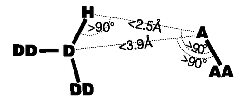

Figura. Geometría ideal de un puente de hidrógeno, donde A es el grupo aceptor, D el donador, AA es el grupo antecedente a A y H es el hidrógeno. Figura de McDonald and Thornton (1994) reproducida con permiso de los autores.

En las secciones anteriores hemos probado algoritmos para muestrear, por un lado, rotámeros de cadenas laterales de aminoácidos y, por otro, bases nitrogenadas de nucleótidos, bajo la misma premisa de que la geometría del esqueleto peptídico y de la doble hélice de DNA va a variar muy poco al sustituir un número pequeño de cadenas laterales y bases nitrogenadas. En esta sección vamos un paso más allá, puesto que además de muestrear es necesario evaluar la especificidad del reconocimiento de las interfaces modeladas, por ejemplo estimando la formación de puentes de hidrógeno.

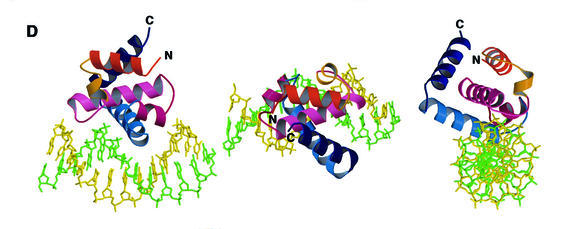

Figura. La proteína [dnaA](http://floresta.eead.csic.es/3dpwm/complexes/1j1v_A.html) en complejo con ADN. Figura tomada de (Fujikawa et al. 2003). Copyright (2003) Nucleic Acids Research.

El punto de partida para presentar este algoritmo es la estructura del complejo de dnaA y su sitio operador, tras añadir con [Open Babel](http://openbabel.org/wiki/Main_Page) los átomos de hidrógeno que puedan faltar de un fichero en formato PDB (ver [*script*](https://github.com/eead-csic-compbio/bioinformatica_estructural/blob/master/code/add_hydrogens.py)). Por ejemplo, partiendo del complejo capturado en el archivo [PDB 1J1V](http://www.rcsb.org/pdb/explore.do?structureId=1j1v), que ya usamos en el apartado 6.3, obtenemos 1j1v_withH.pdb. Una vez realizado este paso preliminar, por medio del siguiente código podemos identificar los puentes de la interfaz proteína-DNA, como haríamos con el programa HBPLUS (McDonald and Thornton 1994): [[fuente: prog4.2.py]](https://github.com/eead-csic-compbio/bioinformatica_estructural/blob/master/code/prog4.2.py)

## 6.5 Interfaces entre proteína, DNA y RNA: endonucleasas CRISPR-Cas guiadas por RNA

A veces no necesitamos modelar una interfaz molecular, pero sí comprenderla, para diseñar experimentos. Esto ocurre con las endonucleasas [CRISPR-Cas](http://wwwuser.cnb.csic.es/~montoliu/CRISPR), herramientas de edición genómica en principio más sencillas de emplear que las proteínas TALEN o las endonucleasas fusionadas con dominios Zinc Finger (ZFN).

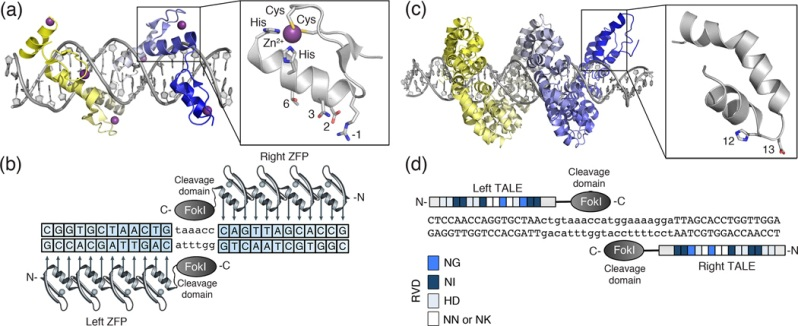

Figura. Dominios Zinc Finger (ZF, izq) y transcription activator-like effector (TALEN, dcha) fusionados con endonucleasas FokI. En ambos casos se muestran en cajas los nucleotidos reconocidos por cada dominio. Mientras cada ZF reconoce en general 3 bases, cada TALEN reconoce solamente una. Figura de (Gaj, Gersbach, and Barbas 2013) reproducida con permiso.

Estos sistemas se han usado, por ejemplo, para inducir mutaciones heredables en loci seleccionados de plantas, incluso en especies poliploides como el trigo panadero (Y. Wang et al. 2014; Lawrenson et al. 2015). Para ello es preciso hacer análisis de secuencias con el fin de elegir las secuencias adecuadas, normalmente únicas en el genoma. En el caso de las endonucleasas Cas (Stella, Alcon, and Montoya 2017), polipéptidos de más de 1000 aminoácidos, las secuencias diana deben elegirse respetando la arquitectura de la interfaz entre proteína, DNA y RNA, que requiere un motivo de entre 3 y 5b adyacente a la diana, llamado PAM (*protospacer adjacent motif*). Además de la estructura de estos complejos, normalmente es necesario determinar experimentalmente *in vitro* e *in vivo* la tasa de cortes no deseados o qué partes del RNA guía (sgRNA) son más sensibles en la hibridación (Cisse, Kim, and Ha 2012; T. Zheng et al. 2017). Se han empleado asimismo modelos de dinámica molecular para estudiar la mecánica de estos complejos (W. Zheng 2017).

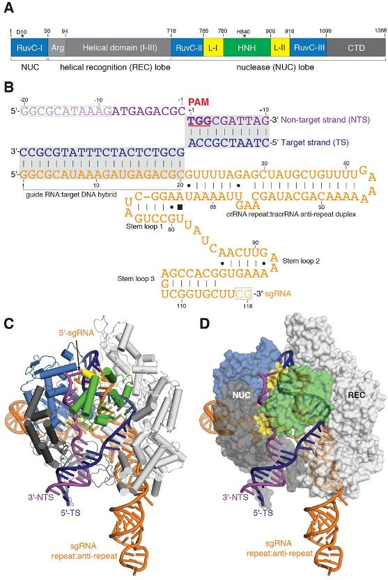

Figura. Estructura del complejo Cas9-sgRNA-dsDNA. A) Dominios de Cas9 de Streptococcus pyogenes. B) Esquema del complejo sgRNA-DNAdiana. La hebra DNA diana se muestra en azul oscuro, la secuencia PAM se subraya, y sgRNA se muestra en naranja. Los sitios de corte no se muestran, ver Stella, Alcon, and Montoya (2017). C,D) Estructuras del complejo ternario. Figura de (F. Jiang et al. 2016) reproducida con permiso.

## 6.6 Modelando interfaces moleculares por homología

Podemos aprovechar las observaciones de las figuras 6.2 y 6.3 para estudiar u optimizar una interfaz molecular en base a la estructura de otras moléculas similares.

Hay muchas herramientas disponibles para modelar interfaces entre proteínas, desde herramientas sencillas como [InterPreTS](http://www.russelllab.org/cgi-bin/tools/interprets.pl) o [PPI3D](http://bioinformatics.ibt.lt/ppi3d), que no cambian la geometría de la estructura molde usada como punto de apoyo, a protocolos más complejos que ajustan el acoplamiento por *docking*. Hay también herramientas especializadas en el estudio de interfaces en el contexto de enfermedades asociadas a mutaciones ([InteractomeINSIDER](http://interactomeinsider.yulab.org)) o en el diseño de anticuerpos (Lapidoth et al. 2015; Baran et al. 2017).

En este apartado combinamos algunas de las herramientas empleadas en otras secciones para estudiar, por ejemplo, tres diferentes [factores sigma70](http://en.wikipedia.org/wiki/Sigma_factor) de la bacteria *Rhizobium etli CFN42*, como son [SigA](http://www.uniprot.org/uniprot/Q2K619), [rpoH1](http://www.uniprot.org/uniprot/Q2K4Y1) y [rpoH2](http://www.uniprot.org/uniprot/Q2K316). De ninguna de ellas conocemos actualmente su estructura en complejo con ADN, pero sí sabemos que SigA reconoce con cierta especificidad el consenso `CTTGACN[16-23]TATNNT`, como se explica en detalle en este trabajo de (Ramirez-Romero et al. 2006), donde entre otras cosas también estiman la estabilidad de las regiones promotoras, como vimos en la sección 3.1.

Para seleccionar estructuras molde que nos sirvan para construir modelos podemos, como vimos en la sección 5.3, buscar directamente en el [PDB](https://www.rcsb.org/pdb). Sin embargo, en este caso iremos más rápido si consultamos el repositorio [3D-footprint](https://floresta.eead.csic.es/3dfootprint) (Contreras-Moreira 2010), que contiene solamente el conjunto actualizado de complejos proteína-DNA. Si pegamos en el motor de búsqueda de 3D-footprint las secuencias de estas 3 proteínas nos encontramos con que el complejo [1rio_H](http://floresta.eead.csic.es/3dfootprint/complexes/1rio_H.html) parece ser el mejor molde en todos los casos, ya que [3iyd_F](http://floresta.eead.csic.es/3dfootprint/complexes/3iyd_F.html) es un complejo resuelto por microscopía con muy poca resolución:

| factor | logo | E-value | %IID | %Isim | %Icover | organism | complex |
| --- | --- | --- | --- | --- | --- | --- | --- |
| SigA: |  | 4e-23 | 100 | 100.0 | 100 | THERMUS AQUATICUS | [1rio_H](http://floresta.eead.csic.es/3dfootprint/complexes/1rio_H.html):STRUCTURE OF BACTERIOPHAGE LAMBDA C… |

```
>1rio_H:Sigma3_and_sigma4_domains_of_RNA_polymerase_sigma_factors;
           title=STRUCTURE OF BACTERIOPHAGE LAMBDA CI-NTD IN COMPLEX WITH SIGMA-REGION4 OF THERMUS AQUATICUS BOUND TO
           DNA organism=THERMUS AQUATICUS | interface=43,44,45,46,48,49

  Expect = 4e-23, Identities = 34/59 (57%)
  Interface: identity = 6/6 (100%) , similarity = 6.0/6 (100%) , coverage = 6/6 (100%)

Query: 614 ETTTRVLASLTPREERVLRMRFGIGMNTDHTLEEVGQQFSVTRERIRQIEAKALRKLKH 672
           E   + L+ L+ RE  VL++R G+    +HTLEEVG  F VTRERIRQIE KALRKLK+
Sbjct: 2   EELEKALSKLSEREAMVLKLRKGLIDGREHTLEEVGAYFGVTRERIRQIENKALRKLKY 60
```

| rpoH1: |  | 3e-17 | 83 | 87.5 | 100 | THERMUS AQUATICUS | [1rio_H](http://floresta.eead.csic.es/3dfootprint/complexes/1rio_H.html):STRUCTURE OF BACTERIOPHAGE LAMBDA C… |
| --- | --- | --- | --- | --- | --- | --- | --- |

```
>1rio_H:Sigma3_and_sigma4...

  Expect = 3e-17, Identities = 24/56 (42%)
  Interface: identity = 5/6 (83%) , similarity = 5.2/6 (88%) , coverage = 6/6 (100%)

Query: 228 LAKAMSVLNERERRIFEARRLAED--PVTLEDLSAEFDISRERVRQIEVRAFEKVQ 281
           L KA+S L+ERE  + + R+   D    TLE++ A F ++RER+RQIE +A  K++
Sbjct: 4   LEKALSKLSEREAMVLKLRKGLIDGREHTLEEVGAYFGVTRERIRQIENKALRKLK 59
```

| rpoH2: |  | 2e-18 | 67 | 77.5 | 100 | THERMUS AQUATICUS | [1rio_H](http://floresta.eead.csic.es/3dfootprint/complexes/1rio_H.html):STRUCTURE OF BACTERIOPHAGE LAMBDA C… |
| --- | --- | --- | --- | --- | --- | --- | --- |

```
>1rio_H:Sigma3_and_sigma4...

  Expect = 2e-18, Identities = 26/56 (46%)
  Interface: identity = 4/6 (67%) , similarity = 4.7/6 (78%) , coverage = 6/6 (100%)

Query: 220 LASALKHLNEREMKIISARRLAEDGA--TLEELGADLGISKERVRQIESRAMEKLR 273
           L  AL  L+ERE  ++  R+   DG   TLEE+GA  G+++ER+RQIE++A+ KL+
Sbjct: 4   LEKALSKLSEREAMVLKLRKGLIDGREHTLEEVGAYFGVTRERIRQIENKALRKLK 59
```

Asimismo podemos observar que el logo de [1rio_H](http://floresta.eead.csic.es/3dfootprint/complexes/1rio_H.html) se corresponde bastante bien con la caja -35 descrita en el artículo de (Ramirez-Romero et al. 2006):

`cTTGACT`  
`||||||+`  
`CTTGACN`

lo cual no es sorprendente dado que SigA tiene un conjunto de residuos de interfaz, aquellos que contactan con las bases nitrogenadas, conservado respecto al de [1rio_H](http://floresta.eead.csic.es/3dfootprint/complexes/1rio_H.html). Sin embargo, no ocurre lo mismo con rpoH1 y rpoH2, que presentan mutaciones en la interfaz.

El ejercicio de esta sección consiste en:

- Construir modelos por homología de [rpoH1](http://www.uniprot.org/uniprot/Q2K4Y1) y [rpoH2](http://www.uniprot.org/uniprot/Q2K316), en presencia de la molécula de ADN de [1rio_H](http://floresta.eead.csic.es/3dfootprint/complexes/1rio_H.html). Puedes probar MODELLER, como avanzamos en la sección 5.3, siguiendo el [tutorial avanzado](http://salilab.org/modeller/tutorial/advanced.html), que contiene una parte sobre *Modeling ligands in the binding site*, la herramienta web [TFmodeller](http://www.ccg.unam.mx/tfmodeller/), o cualquier método que se te ocurra, pero es esencial que el modelo contenga las coordenadas de ADN del molde.
- Escribir un programa, que puede aprovechar código de otras secciones de este curso, para analizar las interfaces moleculares de los modelos rpoH1 y rpoH2, con el fin de elucidar si se conservan las interacciones no covalentes de reconocimiento de bases nitrogenadas.
- Si cambiase alguna de las interacciones, qué posiciones del consenso de [1rio_H](http://floresta.eead.csic.es/3dfootprint/complexes/1rio_H.html) esperas que cambien?

## 6.7 Modelando interfaces moleculares mediante docking

En la sección 6.6 aprovechábamos las coordenadas de un complejo molecular conocido para aproximar la interfaz de una secuencia homóloga. Cuando no disponemos de estructuras de referencia, el estudio de las conformaciones que adoptan las macromoléculas cuando interaccionan de forma transitoria es aun más difícil, con costes computacionales poco asumibles. La razón de esto es que hay muchos grados de libertad y un gran número de átomos del sistema pueden moverse. Por tanto, los algoritmos de [*docking*](http://en.wikipedia.org/wiki/Macromolecular_docking) suelen emplear estrategias para ahorrar recursos, como por ejemplo el uso de transformadas de Fourier en vez del empleo explícito de matrices de rotación y traslación (Katchalski-Katzir et al. 1992).

Un subproblema específico es el acoplamiento entre una enzima y su sustrato, una tarea para la que la información genómica (operones) puede ser muy valiosa (Zhao et al. 2013).

Además de bancos de pruebas publicados por algunos desarrolladores (Yu and Guerois 2016), desde el año 2001 hay en marcha un experimento colectivo ([CAPRI](https://www.ebi.ac.uk/pdbe/complex-pred/capri)) donde regularmente se ponen a prueba los diferentes algoritmos existentes para predecir, antes de su publicación, las poses de complejos proteicos cuyas estructuras se han resuelto experimentalmente (normalmente por cristalografía).

La lista de programas de acoplamiento molecular o *docking* es muy amplia, por lo que puede ser buena idea consultar los resultados recientes de CAPRI para seleccionar el software adecuado para nuestras necesidades. Un problema añadido es que en mi experiencia éstos son programas hechos por definición para usuarios avanzados, que requieren de cierta experiencia sobre todo a la hora de interpretar los resultados.

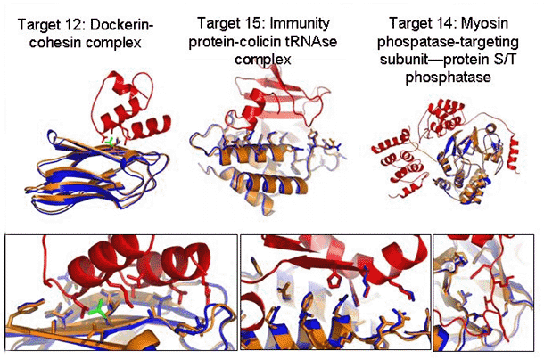

Figura. Algunas predicciones de dímeros en CAPRI. Se muestran superposiciones de complejos predichos (azul) y resueltos experimentalmente por rayos X (rojo y naranja). En verde se destaca una cadena lateral que se reorienta al formarse el complejo. Figura tomada de https://boinc.bakerlab.org/rosetta/rah/rah_docking.php.

Una buena manera de empezar a jugar con software de *docking* puede ser instalando el software [PyRosetta](http://pyrosetta.org) (Chaudhury, Lyskov, and Gray 2010). Este software nos permite hacer, de forma programática, una simulación *docking* en miniatura, en este caso entre un dúplex de ADN y el factor de transcripción DnaA , algo que puede plantearse simultáneamente como un problema clásico de *docking* y como un problema de especificidad de reconocimiento: [[fuente: prog4.3.py]](https://github.com/eead-csic-compbio/bioinformatica_estructural/blob/master/code/prog4.3.py)

Como resultado de las simulaciones de *docking* tendremos una serie de complejos, que pueden o no mostrar interfaces relevantes en términos biológicos, dependiendo de la profundidad del muestreo realizado y el análisis posterior de los resultados, que obviamente requiere de cierta experiencia y sobre todo conocimiento de las moléculas implicadas. En concreto en el ejemplo 4.3, posiblemente como consecuencia del limitado muestreo (N=10), ninguna de las interfaces resultantes de mis simulaciones docking_output.tgz consigue reconstruir la interfaz descrita experimentalmente:

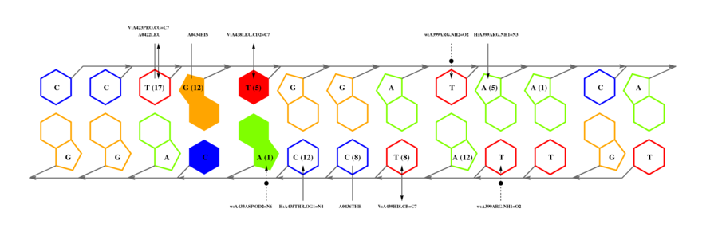

Figura. Esquema del reconocimiento específico de ADN en la interfaz de DnaA ([PDB 1J1V](http://www.rcsb.org/pdb/explore.do?structureId=1j1v)), tomado del repositorio [3D-footprint](http://floresta.eead.csic.es/3dfootprint/complexes/1j1v_A.html).

# 7 AlphaFold y la revolución del aprendizaje automático

Las metodologías descritas en los capítulos anteriores son el resultado de décadas de trabajo de la comunidad científica. A hombros de estos gigantes, y aprovechando el enorme número de secuencias (~10E8) y estructuras (~10E5) de proteínas conocidas en la actualidad, se han ido publicando desde 2020 herramientas basadas en el [aprendizaje automático](https://es.wikipedia.org/wiki/Aprendizaje_autom%C3%A1tico) (AU, *machine learning* (ML) en inglés) que han permitido dar un salto cualitativo en la predicción de la estructura de las proteínas. La más famosa de todas es [AlphaFold](https://alphafold.ebi.ac.uk) (AF), merecedora del [Nobel](https://bioinfoperl.blogspot.com/2024/10/nobel-diseno-prediccion-proteinas.html), pero hay muchas otras. Vayamos por partes.

## 7.1 La revolución del aprendizaje automático

El experimento bianual CASP, del que ya hablamos en la sección de Fold recognition, ha permitido medir de manera objetiva el impacto del AA en la predicción estructural. En las siguientes figuras se puede ver el salto que supuso la aparición de AlphaFold y otros métodos de AA:

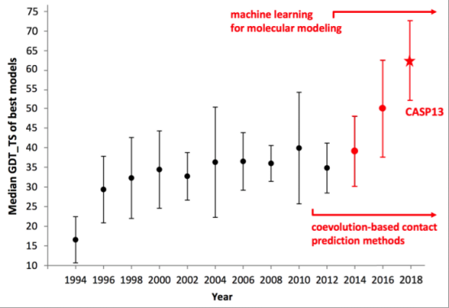

Figura. Calidad de los mejores modelos evaluados en CASP a lo largo de los años usando la métrica GDT_TS (Zemla 2003). Los evaluadores de CASP13 achacaron la mejoría a que algunos de los mejores algoritmos fueron capaces de estimar distancias entre aminoácidos a partir de información evolutiva implícita en alineamientos múltiples de secuencia muy profundos (Abriata, Tamò, and Dal Peraro 2019). Figura tomada del [blog del SIB](https://www.sib.swiss/about/news/10307-deep-learning-a-leap-forward-for-protein-structure-prediction).

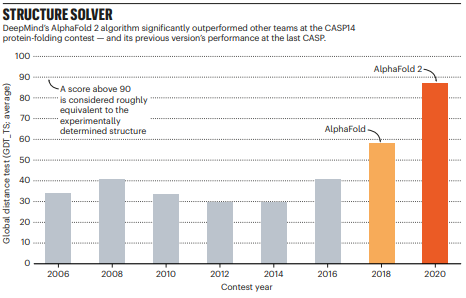

Figura. Calidad de los mejores modelos evaluados en CASP hasta la participación del predictor AlphaFold2 (AF2). Figura tomada de (Callaway 2020). Puedes leer más detalles en el [blog](https://bioinfoperl.blogspot.com/2020/11/alphafold-resuelve-plegamiento-proteinas.html).

Es evidente que los nuevos métodos de AA han aumentado de manera significativa nuestra capacidad de predecir la estructura de las proteínas. Como decía al principio de este capítulo, los investigadores de la compañía DeepMind han avanzado a hombros de gigantes y han tenido a su disposición enormes recursos de cálculo. Pero ojo, aunque el algoritmo AF haga predicciones de alta calidad en muchos casos, esto no significa que sepamos simular el proceso de plagamiento de proteínas todavía.

## 7.2 Cómo funciona AlphaFold2

Las redes neuronales se han estado aplicando en nuestro campo desde hace décadas para la predicción de estructura secundaria o para predecir contactos entre aminoácidos de proteínas plegadas. En ambas aplicaciones aprovechamos que para muchas familias de proteínas conocemos tantas secuencias diferentes que podemos usar esa información evolutia para inferir qué partes de la estructura plegada se tocan entre sí y por tanto restringen el espacio de mutaciones.

AF2 usa el mismo tipo de información de partida, la secuencia de aminoácidos problema P y un alineamiento múltiple de P con otras secuencias no redundantes de proteínas homólogas, pero va más allá por que en vez de predecir contactos extrae información estructural más concreta cómo distancias y ángulos. Su sistema comprende varios módulos que se ejecutan secuencialmente y realizan las siguientes tareas:

- Extración de correlaciones evolutivas entre residuos de una proteína a partir de perfiles de secuencias homólogas obtenidas con PSIBLAST o HHblits con el algoritmo CCMpred (Seemayer, Gruber, and Söding 2014), similar a otros presentados en la sección 5.5.
- Predicción de información estructural con redes neuronales [profundas](https://bioinfoperl.blogspot.com/2020/04/redes-neuronales-profundas.html), con al menos dos variantes:
  - Predicción de distancias reales entre C-$beta$, no contactos, a partir de histogramas precalculados en el rango de 2 a 22 Ansgtrom, inspirado en RaptorX. Las distancias estimadas les permiten asignar estructura secundaria con una precisión Q3 del 84% usando datos de CASP11.
  - Predicción de ángulos diedros $phi$ y $psi$ (ver sección 1.3.2).
- Diferenciación del potencial de distancias/ángulos por métodos de minimización de gradientes con la secuencia entera.
- Relajación del esqueleto obtenido con el campo de fuerzas AMBER (ver sección 2.6), seguido de modelado de cadenas laterales completas con Rosetta, aunque esto no mejore el modelo de manera significativa.

En resumen, el modelo AF2 consta de 4 etapas, resumidas en la figura siguiente:

- Secuencia problema P /**input sequence** en formato FASTA.
- Búsqueda de bases de datos.
  - Para cada P se construye un alineamiento múltiple (MSA) con las secuencias similares encontradas en colecciones como [Mgnify](https://www.ebi.ac.uk/metagenomics/) , UniRef90 y [UniClust30](https://uniclust.mmseqs.com).
  - Además se hace una búsqueda de estructuras molde / **template** que se pueden usar como punto de partida para los modelos.
- Predicción de 5 modelos con el mismo **input** y cinco redes profundas entrenadas de manera independiente.
- Relajación y evaluación de los modelos.

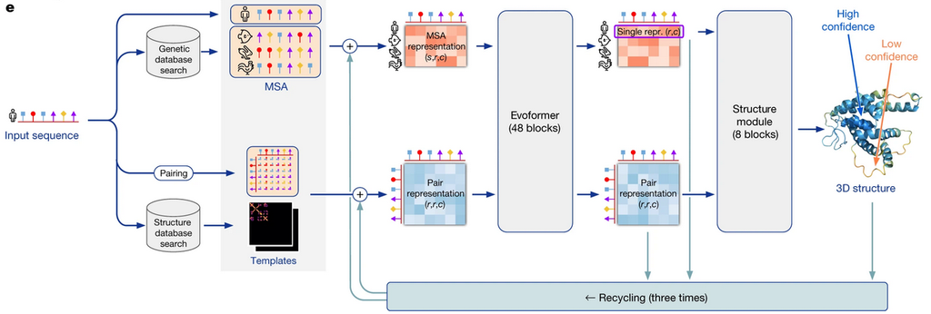

Figura. Arquitectura del modelo AlphaFold2 (AF2), donde se describe que los datos de partida se representan de dos formas complementarias: alineamiento múltiple de secuencias (MSA) y parejas de residuos correlacionados. Estas dos representaciones sirven de entrada para dos tipos de redes profundas diferentes. La red Evoformer hace inferencia directa de relaciones espaciales y evolutivas usando mecanismos de ‘atención’ entre capas de la red Rubiera (2021) y triángulos entre residuos. A continuación el módulo estructural sirve para modelar en 3D de manera explícita por medio de matrices de rotación y traslación cada aminoácido. Las flechas muestran el flujo de información y las dimensiones de las matrices se dan como $s$ (número de secuencias), $r$ (número de residuos) y $c$ (número de canales). El proceso se repite tres veces para ir refinando/reciclando las predicciones y producir los modelos finales. Figura tomada de (Jumper et al. 2021). El proceso se explica en detalle en un vídeo creado por los autores de AF2 (Tunyasuvunakool 2022).

AF2 se construye sobre [Tensorflow](https://www.tensorflow.org), [JAX](https://github.com/google/jax), [TPU](https://en.wikipedia.org/wiki/Tensor_Processing_Unit) y [Colab](https://colab.research.google.com). Puedes ver la lista completa de dependencias en su [repositorio](https://github.com/deepmind/alphafold#acknowledgements).

### 7.2.1 Métricas de calidad de AlphaFold2 (AF2)

Los modelos 3D producidos por AF2 se ordenan por su puntuación **pLDDT** (*predicted Local Distance Difference Test*). Es una predicción por residuo de la función lDDT-C$alpha$, una medida de confianza para cada residuo basada en el porcentaje de distancias interatómicas que caen dentro de valores esperados. Por tanto es una medida que informa de la calidad local (ver sección 5.1.

A diferencia de lDDT, pLDDT toma valores de 0 a 100 que se guardan como factores de temperatura en los modelos generados en formato PDB (ver sección 1.5. Los valores [70-90] se interpretan como de alta confianza y los mayores de 90 de muy alta confianza. Valores por debajo de 50 se consideran propios de estructuras desordenadas, como pasa frecuentemente en los extremos de los polipéptidos.

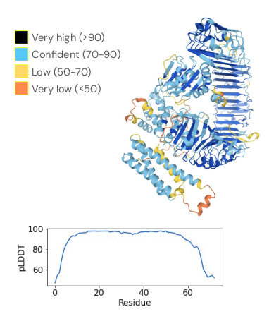

Figura. Ejemplos de pLDDT de modelos AF2. El esquema de arriba muestra una proteínas con varios dominios. La gráfica de abajo muestra los valores en un dominio solo. Figura adaptada de (Tunyasuvunakool 2022) .

Otra medida independiente de la calidad de un modelo AF2 es **PAE** (*Predicted Aligned Error*), que se mide en Angstrom. Esta métrica mide el error de las posiciones de los residuos de un modelo si se pudiera superponer con la estructura experimental. Se usa sobre todo para evaluar las posiciones de los diferentes dominios de una proteína multidominio.

## 7.3 Evaluación de calidad de las predicciones de AlphaFold2 (AF2)

Entre las **fortalezas** de AF2 destaca su notable precisión promedio de 1.5 Å de RMSD para todos los átomos modelados, no sólo carbonos $\alpha$, tanto en CASP14 como en un conjunto de 3144 estructuras recientemente publicadas en el *Protein Data Bank* tras descartar las estructuras conocidas con identidad de secuencia > 40%. Además, AF2 es capaz de estimar bien la calidad los modelos que genera:

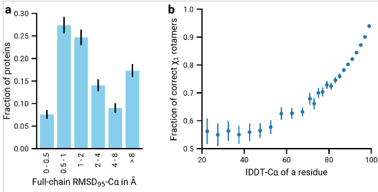

Figura. Banco de pruebas de AF2 sobre un conjunto de 3144 estructuras del PDB: a) RMSD del esqueleto peptídico modelado comparado con la estructura experimental. b) Correlación entre la precisión del esqueleto, calculada con la función lDDT (Mariani et al. 2013), y la correcta elección de rotámeros de la cadenas laterales. Figura tomada de (Jumper et al. 2021).

Otra fortaleza es que la [AlphaFold Protein Structure Database](https://alphafold.ebi.ac.uk) (Fleming et al. 2025) va creciendo y al inicio de 2026 incluye 214M de estructuras predichas para múltiples especies. Si en julio de 2021 agregó los proteomas de 20 especies modelo, incluyendo varias [plantas](https://bioinfoperl.blogspot.com/2022/09/plantas-beneficiadas-alphafold.html), desde septiembre de 2025 incluye todas las secuencias de [UniProt](https://www.uniprot.org) 2025_03.

Al analizar estos modelos de AF2 la mayoría se pueden asignar a superfamilias ya existentes en la clasificación de plegamientos, pero enriqueciendo de manera significativa las conformaciones de las superfamilias conocidas en CATH, y revelando nuevos plegamientos (Varadi et al. 2022; Bordin et al. 2022; Koehler et al. 2023; Durairaj et al. 2023; Lau et al. 2024).

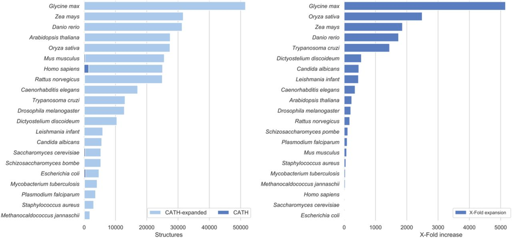

Figura. Crecimiento en conocimiento estructural en número de dominios (izquierda) y en proporción (derecha) para 21 especies en 2021. Figura tomada de (Bordin et al. 2022).

Entre las **limitaciones** destacan:

- La calidad de las predicciones cae de manera significativa si el alineamiento múltiple de secuencias homólogas a la de interés tiene una profundidad < 30 (ver sección de predicción de contactos)
- Las estructuras de AF2 son de menor calidad para dominios poco compactos, con pocos contactos, como las regiones puente.

## 7.4 Qué cambia con AlphaFold3

AlphaFold3 (AF3) es una modificación sustancial de AF2 que durante el entrenamiento aprende más rápido y que, al soportar una mayor variedad de moléculas (ADN, ARN, ligandos), permite predecir estructuras cuaternarias y estudiar interacciones proteína-proteína, proteína-ADN y proteína-ARN. Desde el punto de vista algorítmico, AF3 i) reduce el procesamiento de alineamientos múltiples de secuencias y ii) predice directamente coordenadas atómicas por medio de un nuevo módulo de difusión que elimina la necesidad de trabajar sobre la base de aminoácidos y cadenas laterales, dado que es un modelo generativo que genera imágenes tridimensionales de proteínas.

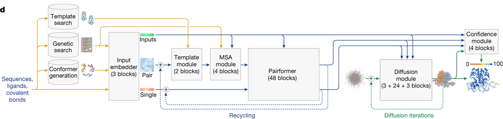

Figura. Arquitectura de AF3, una evolución de AF2 especializada en interacciones de proteínas. Figura tomada de (Abramson et al. 2024).

## 7.5 Otros algoritmos alternativos a AF

El fenómeno que ha supuesto la llegada de AF va más allá y prueba de ello es que otros autores están publicando soluciones similares usando algoritmos distintos, lo cual nos dice mucho del potencial actual del AA en este campo.

Los dos principales algoritmos alternativos hasta la fecha creo que son RoseTTAFold y [ESMFold](https://github.com/facebookresearch/esm). El primero se describe en detalle en (Baek et al. 2021) y en el [blog](https://bioinfoperl.blogspot.com/2021/07/rosettafold-modelado-open-source-proteinas.html). El segundo se describe en (Lin et al. 2023).

RFdiffusion2 es un algoritmo de diseño de proteínas basado en RoseTTAFold (Ahern et al. 2026) que se ha aplicado a problemas de diseño de enzimas con función a la carta.

Otros algoritmos que usan aprendizaje profundo son por ejemplo D-I-TASSER (Wei Zheng et al. 2025) o DMPfold (Greener, Kandathil, and Jones 2019).

Otra alternativa interesante es el algoritmo [RGNA2](https://github.com/aqlaboratory/rgn2), una red geométrica recurrente descrita en (Chowdhury et al. 2022). A diferencia de AF2 y RoseTTAFold, RGN2 no calcula alineamientos múltiples y por tanto se puede aplicar a cualquier secuencia, incluso a aquellas que llamamos huérfanas porque no tienen secuencias similares homólogas en las bases de datos. En cambio, RGN2 es un modelo de lenguaje, derivado de los que se usan cotidianamente para procesar lenguaje natural o para completar una frase cuando escribes en tu móvil. Aunque los autores recomiendan AF2 para los casos que sí tienen homólogos, sus resultados muestran que RGN2 supera a AF2 y RoseTTAFold en secuencias huérfanas gastando cien veces menos tiempo de cálculo.

[ProteinSGM](https://gitlab.com/mjslee0921/proteinsgm) es un modelo de difusión capaz de generar estructuras *de novo* (J. S. Lee, Kim, and Kim 2023).

## 7.6 Aplicaciones de AlphaFold y algoritmos similares

Tras la publicación de los primeros resultados de AF2 y AF3 la comunidad se puso manos a la obra para explorar las aplicaciones reales que podría tener. Muchos de esos esfuerzos se discutieron y diseminaron en Twitter. Por ejemplo, en este [hilo](https://twitter.com/_BalintMeszaros/status/1419579483921731591) se habla de la capacidad de predecir regiones desordenadas en proteínas con AF2, en [éste](https://twitter.com/DeepMind/status/1455589083611271169?s=20) de predicciones para multímeros o este [otro](https://twitter.com/MoAlQuraishi/status/1459188604723351552) de cómo reimplementar AF2 por completo para poder entrenarlo tú mismo.

El trabajo de (Akdel et al. 2022) surgió de manera similar y evaluó de manera objetiva el potencial de AF2 para resolver problemas clásicos de la bioinformática estructural:

- **Predicción del efecto fenotípico de variantes/SNPs**. Para ellos modelaron 33 proteínas con más de cien mil mutaciones en total resultantes de experimentos de mutagénesis profunda. Tras calcular correlaciones entre los efectos predichos y los medidos experimentalmente observaron que las obtenidas con AF2 eran en promedio iguales o mejores que las obtenidas por métodos experimentales. Otros trabajos más recientes proponen diferentes algoritmos (Brandes et al. 2023; Cheng et al. 2023; Lacoste et al. 2024), pero a menudo se centran en proteínas humanas.
- **Predicción de cavidades de unión a ligandos**. En este caso usaron un conjunto de 225 proteínas para las cuales había estructuras disponibles en conformación unida al ligando (holo) y también sin unir (apo). En sus manos no apreciaron diferencia entre las cavidades obtenidas experimentalmente y las derivadas de modelos AF2 con **pLDDT > 90**. En cambio, observaron que los modelos AF2 con pLDDT < 90 no son fiables para buscar cavidades. [AlphaFill](https://github.com/PDB-REDO/alphafill) se puede usar para agregar ligandos en esas cavidades.
- **Predicción de homo-oligómeros**. En su banco de pruebas observaron que en 71 de 87 casos los modelos de AF2 con el estado correcto de oligomerización tenían la puntuación más alta. Hay otra evaluación más completa em (Evans et al. 2022).
- **Reemplazamiento molecular**. Con dos ejemplos mostraron que los modelos AF2 se pueden usar para refinar modelos obtenidos datos experimentales de cryo-EM y cristalográficos.

Otras aplicaciones son:

- **Diseño de proteínas con función a la carta**, como se explica por ejemplo en (Madani et al. 2023; A. B. Guo et al. 2025)
- **Predicción de sitios activos**, como se explica por ejemplo en (Tang and Wang 2025)
- **Predicción de interacciones entre proteínas**, por ejemplo con [proteínas de defensa de plantas](https://bioinfoperl.blogspot.com/2024/09/protocolo-parejas-proteinas%20con%20AlphaFold.html) y o en interfaces mediadas por proteínas desordenadas (Homma, Huang, and Hoorn 2023; Homma, Lyu, and Hoorn 2024; Ginell et al. 2025; Varga, Ovchinnikov, and Schueler-Furman 2025)
- **Predicción de complejos proteína-ADN**, como se explica por ejemplo en (Gerasimavicius, Biddie, and Marsh 2026)

## 7.7 Cómo obtener y usar modelos de AlphaFold y algoritmos similares

La manera más rápida de explorar modelos de AF es acceder a los que están precalculados en https://alphafold.ebi.ac.uk. En la interfaz Web puedes buscar proteínas por identificador de UniProt, pegando una secuencia, o descargar todos los modelos de un organismo o de SwissProt en la sección de descargas https://alphafold.ebi.ac.uk/download.

Si quieres calcular tus propios modelos hay varias opciones:

- El servidor Web de AF3 https://alphafoldserver.com permite modelar monómeros, multímeros e incluso complejos [proteína-ADN](https://bioinfoperl.blogspot.com/2024/05/logo-protein-DNA-complex-alphafold.html).
- Un contenedor Docker de AF2 descrito en https://github.com/deepmind/alphafold que requiere 2.2TB de espacio si instalas todas las bases de datos ([BFD](https://bfd.mmseqs.com), MGnify, PDB70, PDB, Uniclust30, UniProt, UniRef90). No te olvides de revisar las [licencias](https://github.com/deepmind/alphafold#license-and-disclaimer).
- Los cuadernos Colab de https://github.com/sokrypton/ColabFold permiten combinar las prestaciones de MMseqs2 para encontrar secuencias homólogas con diferentes predictores como AlphaFold2, RoseTTAFold o ESMFold.
- El cuaderno Colab de https://colab.research.google.com/github/aqlaboratory/openfold/blob/main/notebooks/OpenFold.ipynb, una reimplementación de AF2, sin moldes/*templates* y una versión reducida de BFD, construida sobre [PyTorch](https://pytorch.org). Puedes ver en [Twitter](https://twitter.com/MoAlQuraishi/status/1539589308893597698) los resultados de la comparación con AF2 según los propios autores y en el [blog](https://bioinfoperl.blogspot.com/2022/06/openfold-open-source-alphafold.html) otras formas de ejecutarlo.

[figure not shown]

Figura. La búsqueda de secuencias homólogas en AF2 Colab tarda 43min para una secuencia de 413 aminoácidos.

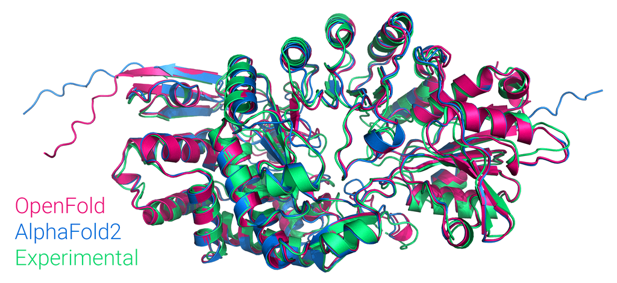

Figura. Comparación de predicciones de AF2 y OpenFold para la estructura [7KDX:B](https://www.rcsb.org/structure/7KDX). Figura tomada de https://github.com/aqlaboratory/openfold.

### 7.7.1 Ejercicio con AF2 y algoritmos similares

El ejercicio de esta sección consiste en:

- elegir una secuencia de aminoácidos de una proteína de cualquier colección,
- modelar su estructura terciaria con algoritmos disponibles en ColabFold u [OpenFold](https://colab.research.google.com/github/aqlaboratory/openfold/blob/main/notebooks/OpenFold.ipynb),
- estimar su calidad con las distintas métricas y https://swissmodel.expasy.org/assess

### 7.7.2 Ejercicio con AF3

En esta sección se trata de modelar un complejo proteína-ADN con AF3. Para ello necesitarás:

- la secuencia de aminoácidos de un factor de transcripción; si es un dímero necesitarás dos secuencias
- la secuencia de ADN (20-30 pares de bases) que contenga un sitio conocido o esperado de unión del factor de transcripción
- si conoces iones necesarios para la unión, como Zn, puedes incluirlos también
- lanzar la predicción en https://alphafoldserver.com
- estimar su calidad con las distintas métricas y https://swissmodel.expasy.org/assess
- opcionalmente puedes estudiar la especificidad del complejo obtenido como se explica en el [blog](https://bioinfoperl.blogspot.com/2024/05/logo-protein-DNA-complex-alphafold.html)

# 8 Apéndices

## 8.1 Abreviaturas

| AA | Aprendizaje Automático |
| --- | --- |
| AF | AlphaFold |
| CASP | Critical Assessment of Techniques for Protein Structure Prediction |
| CATH | Protein Structure Classification database |
| CM | Comparative Modelling |
| DSSP | Define Secondary Structure of Proteins |
| FR | Fold Recognition |
| LDDT | Local Distance Difference Test |
| NMR | Nuclear Magnetic Resonance |
| NN | Nearest Neighbor |
| PCR | Polymerase Chain Reaction |
| PDB | Protein Data Bank |
| RMSD | Root Mean Square Difference |
| SCOP | Structural Classification of Proteins |
| TF | Transcription Factor |
| SS | Secondary Structure |

# Bibliografía

Abagyan, R A, and S Batalov. 1997. “Do Aligned Sequences Share the Same Fold?” *J. Mol. Biol.* 273 (1): 355–68. https://doi.org/10.1006/jmbi.1997.1287.

Abramson, Josh, Jonas Adler, Jack Dunger, Richard Evans, Tim Green, Alexander Pritzel, Olaf Ronneberger, et al. 2024. “Accurate Structure Prediction of Biomolecular Interactions with AlphaFold 3.” *Nature* 630 (8016): 493—500. https://doi.org/10.1038/s41586-024-07487-w.

Abriata, L. A., G. E. Tamò, and M. Dal Peraro. 2019. “A further leap of improvement in tertiary structure prediction in CASP13 prompts new routes for future assessments.” *Proteins* 87 (12): 1100–1112. https://doi.org/10.1002/prot.25787.

Adzhubei, I. A., S. Schmidt, L. Peshkin, V. E. Ramensky, A. Gerasimova, P. Bork, A. S. Kondrashov, and S. R. Sunyaev. 2010. “A method and server for predicting damaging missense mutations.” *Nat. Methods* 7 (4): 248–49. http://www.ncbi.nlm.nih.gov/pmc/articles/PMC2855889/.

Agostini, F., M. Vendruscolo, and G. G. Tartaglia. 2012. “Sequence-based prediction of protein solubility.” *J. Mol. Biol.* 421 (2-3): 237–41. http://www.ncbi.nlm.nih.gov/pubmed/22172487.

Ahern, Woody, Jason Yim, Doug Tischer, Saman Salike, Seth M Woodbury, Donghyo Kim, Indrek Kalvet, et al. 2026. “Atom-Level Enzyme Active Site Scaffolding Using RFdiffusion2.” *Nat. Methods* 23 (1): 96–105. https://doi.org/10.1038/s41592-025-02975-x.

Akdel, M., D. E. V. Pires, E. P. Pardo, J. Jänes, A. O. Zalevsky, B. Mészáros, P. Bryant, et al. 2022. “A structural biology community assessment of AlphaFold2 applications.” *Nat Struct Mol Biol*, November. https://doi.org/10.1038/s41594-022-00849-w.

Aloy, P., H. Ceulemans, A. Stark, and R. B. Russell. 2003. “The relationship between sequence and interaction divergence in proteins.” *J. Mol. Biol.* 332 (5): 989–98. https://www.ncbi.nlm.nih.gov/pubmed/14499603.

Aloy, P., and R. B. Russell. 2002. “Interrogating Protein Interaction Networks Through Structural Biology.” *PNAS* 99 (9): 5896–5901. http://www.pnas.org/content/99/9/5896.short.

Amm, I., T. Sommer, and D. H. Wolf. 2014. “Protein quality control and elimination of protein waste: the role of the ubiquitin-proteasome system.” *Biochim. Biophys. Acta* 1843 (1): 182–96. https://www.ncbi.nlm.nih.gov/pubmed/23850760.

Andreeva, A., D. Howorth, C. Chothia, E. Kulesha, and A. G. Murzin. 2014. “SCOP2 prototype: a new approach to protein structure mining.” *Nucleic Acids Res.* 42 (Database issue): D310–314. https://www.ncbi.nlm.nih.gov/pmc/articles/PMC3964979.

Anfinsen, C. B., E. Haber, M. Sela, and F. H. White Jr. 1961. “The kynetics of formation of native ribonuclease during oxidation of the reduced polypeptide chain.” *PNAS* 47 (9): 1309–14. http://www.ncbi.nlm.nih.gov/pmc/articles/PMC223141/.

Arenas, M., C. C. Weber, D. A. Liberles, and U. Bastolla. 2017. “ProtASR: An Evolutionary Framework for Ancestral Protein Reconstruction with Selection on Folding Stability.” *Syst. Biol.* 66 (6): 1054–64. https://www.ncbi.nlm.nih.gov/pubmed/28057858.

Baek, M., F. DiMaio, I. Anishchenko, J. Dauparas, S. Ovchinnikov, G. R. Lee, J. Wang, et al. 2021. “Accurate prediction of protein structures and interactions using a three-track neural network.” *Science* 373 (6557): 871–76. https://doi.org/10.1126/science.abj8754.

Baker, D., and A. Sali. 2001. “Protein Structure Prediction and Structural Genomics.” *Science* 294 (5540): 93–96. http://www.ncbi.nlm.nih.gov/pubmed/11588250.

Balaji, G. A., H. G. Nagendra, V. N. Balaji, and S. N. Rao. 2017. “Experimental conformational energy maps of proteins and peptides.” *Proteins* 85 (6): 979–1001. https://www.ncbi.nlm.nih.gov/pubmed/28168743.

Baran, D., M. G. Pszolla, G. D. Lapidoth, C. Norn, O. Dym, T. Unger, S. Albeck, M. D. Tyka, and S. J. Fleishman. 2017. “Principles for computational design of binding antibodies.” *Proc. Natl. Acad. Sci. U.S.A.* 114 (41): 10900–10905. https://www.ncbi.nlm.nih.gov/pubmed/28973872.

Barrio-Hernandez, Inigo, Jingi Yeo, Jürgen Jänes, Milot Mirdita, Cameron L M Gilchrist, Tanita Wein, Mihaly Varadi, Sameer Velankar, Pedro Beltrao, and Martin Steinegger. 2023. “Clustering Predicted Structures at the Scale of the Known Protein Universe.” *Nature* 622 (7983): 637–45. https://doi.org/10.1038/s41586-023-06510-w.

Bastolla, Ugo, David Abia, and Oscar Piette. 2023. “PC_ali: A Tool for Improved Multiple Alignments and Evolutionary Inference Based on a Hybrid Protein Sequence and Structure Similarity Score.” *Bioinformatics* 39 (11): btad630. https://doi.org/10.1093/bioinformatics/btad630.

Bau, Davide. 2014. “Estructura y Organización de DNA.” https://doi.org/10.5281/zenodo.1066356.

Behrouzi, R., J. H. Roh, D. Kilburn, R. M. Briber, and S. A. Woodson. 2012. “Cooperative tertiary interaction network guides RNA folding.” *Cell* 149 (2): 348–57. http://www.ncbi.nlm.nih.gov/pmc/articles/PMC3384715/.

Bernhart, S. H., H. Tafer, U. Muckstein, C. Flamm, P. F. Stadler, and I. L. Hofacker. 2006. “Partition function and base pairing probabilities of RNA heterodimers.” *Algorithms Mol Biol* 1: 3. http://www.almob.org/content/1/1/3.

Berrondo, M., and J. J. Gray. 2011. “Computed structures of point deletion mutants and their enzymatic activities.” *Proteins* 79 (10): 2844–60. http://www.ncbi.nlm.nih.gov/pmc/articles/PMC3170519/.

Bordin, Nicola, Ian Sillitoe, Vamsi Nallapareddy, Clemens Rauer, Su Datt Lam, Vaishali P. Waman, Neeladri Sen, et al. 2022. “AlphaFold2 Reveals Commonalities and Novelties in Protein Structure Space for 21 Model Organisms.” *bioRxiv*. https://doi.org/10.1101/2022.06.02.494367.

Bower, M. J., F. E. Cohen, and Jr. Dunbrack R. L. 1997. “Prediction of Protein Side-Chain Rotamers from a Backbone-Dependent Rotamer Library: A New Homology Modeling Tool.” *J.Mol.Biol.* 267 (5): 1268–1282. http://linkinghub.elsevier.com/retrieve/pii/S0022-2836(97)90926-8.

Branden, Carl-Ivar, and John Tooze. 1999. *Introduction to Protein Structure*. 2nd ed. New York: Garland Pub. https://www.crcpress.com/Introduction-to-Protein-Structure/Branden-Tooze/p/book/9780815323051.

Brandes, Nadav, Grant Goldman, Charlotte H Wang, Chun Jimmie Ye, and Vasilis Ntranos. 2023. “Genome-Wide Prediction of Disease Variant Effects with a Deep Protein Language Model.” *Nature Genetics* 55 (9): 1512—1522. https://doi.org/10.1038/s41588-023-01465-0.

Breslauer, K. J., R. Frank, H. Blocker, and L. A. Marky. 1986. “Predicting DNA duplex stability from the base sequence.” *Proc. Natl. Acad. Sci. U.S.A.* 83: 3746–50. http://www.pnas.org/content/83/11/3746.

Brunger, A. T. 1997. “X-Ray Crystallography and NMR Reveal Complementary Views of Structure and Dynamics.” *Nat.Struct.Biol.* 4 Suppl: 862–825. http://www.ncbi.nlm.nih.gov/pubmed/9377160.

Bryan, A. W., C. W. O’Donnell, M. Menke, L. J. Cowen, S. Lindquist, and B. Berger. 2011. “STITCHER: Dynamic assembly of likely amyloid and prion structures from secondary structure predictions.” *Proteins* 80(2): 410–20. http://www.ncbi.nlm.nih.gov/pmc/articles/PMC3298606/.

Buchan, D. W. A., and D. T. Jones. 2017. “Improved protein contact predictions with the MetaPSICOV2 server in CASP12.” *Proteins*, September. https://www.ncbi.nlm.nih.gov/pubmed/28901583.

Bueren-Calabuig, Juan A. 2014. “Dinámica Molecular.” https://doi.org/10.5281/zenodo.1066360.

Burra, P. V., Y. Zhang, A. Godzik, and B. Stec. 2009. “Global distribution of conformational states derived from redundant models in the PDB points to non-uniqueness of the protein structure.” *Proc. Natl. Acad. Sci. U.S.A.* 106: 10505–10. http://www.pnas.org/content/106/26/10505.long.

Butterfield, G. L., M. J. Lajoie, H. H. Gustafson, D. L. Sellers, U. Nattermann, D. Ellis, J. B. Bale, et al. 2017. “Evolution of a designed protein assembly encapsulating its own RNA genome.” *Nature* 552 (7685): 415–20. https://www.ncbi.nlm.nih.gov/pubmed/29236688.

Callaway, E. 2015. “The revolution will not be crystallized: a new method sweeps through structural biology.” *Nature* 525 (7568): 172–74. http://www.ncbi.nlm.nih.gov/pubmed/26354465.

———. 2020. “‘It Will Change Everything’: DeepMind’s AI Makes Gigantic Leap in Solving Protein Structures.” *Nature*, no. 588: 203–2020. https://doi.org/10.1038/d41586-020-03348-4.

Cavanagh, J., W. J. Fairbrother, A.G. Palmer, M. Rance, and N.J. Skelton. 2005. *Protein NMR Spectroscopy: Principles & Practice*. 2nd ed. New York: Academic Press. http://www.sciencedirect.com/science/book/9780121644918.

Cech, P., and D. Svozil. 2011. “mmView: A Web-Based Viewer of the mmCIF Format.” *BMC Res Notes* 4 (121). https://doi.org/doi:10.1186/1756-0500-4-121.

Chaudhury, S., S. Lyskov, and J.J. Gray. 2010. “PyRosetta: A Script-Based Interface for Implementing Molecular Modeling Algorithms Using Rosetta.” *Bioinformatics* 26(5): 689–91. http://bioinformatics.oxfordjournals.org/content/26/5/689.abstract.

Cheng, Jun, Guido Novati, Joshua Pan, Clare Bycroft, Akvilė Žemgulytė, Taylor Applebaum, Alexander Pritzel, et al. 2023. “Accurate Proteome-Wide Missense Variant Effect Prediction with AlphaMissense.” *Science (New York, N.Y.)* 381 (6664): eadg7492. https://doi.org/10.1126/science.adg7492.

Chew, L P, D Huttenlocher, K Kedem, and J Kleinberg. 1999. “Fast Detection of Common Geometric Substructure in Proteins.” *J. Comput. Biol.* 6 (3-4): 313–25. https://doi.org/10.1089/106652799318292.

Chothia, C., and A. M. Lesk. 1986. “The Relation Between the Divergence of Sequence and Structure in Proteins.” *EMBO J.* 5 (4): 823–826. http://www.ncbi.nlm.nih.gov/pmc/articles/PMC1166865/.

Chowdhury, R., N. Bouatta, S. Biswas, C. Floristean, A. Kharkar, K. Roy, C. Rochereau, et al. 2022. “Single-sequence protein structure prediction using a language model and deep learning.” *Nat Biotechnol* 40 (11): 1617–23. https://doi.org/10.1038/s41587-022-01432-w.

Cisse, I. I., H. Kim, and T. Ha. 2012. “A rule of seven in Watson-Crick base-pairing of mismatched sequences.” *Nat. Struct. Mol. Biol.* 19 (6): 623–27. https://www.ncbi.nlm.nih.gov/pubmed/22580558.

Contreras-Moreira, B. 2010. “3D-Footprint: A Database for the Structural Analysis of Protein-DNA Complexes.” *Nucleic Acids Research* 38: D91–97. http://nar.oxfordjournals.org/content/38/suppl\_1/D91.

Contreras-Moreira, B., and J. Collado-Vides. 2006. “Comparative footprinting of DNA-binding proteins.” *Bioinformatics* 22(14): e74. http://bioinformatics.oxfordjournals.org/content/22/14/e74.short.

Contreras-Moreira, B., I. Ezkurdia, M.L. Tress, and A. Valencia. 2005. “Empirical limits for template-based protein structure prediction: the CASP5 example.” *FEBS Letters* 579(5): 1203–7. http://linkinghub.elsevier.com/retrieve/pii/S0014579305000773.

Contreras-Moreira, B., P. W. Fitzjohn, and P. A. Bates. 2002. “Comparative Modelling: An Essential Methodology for Protein Structure Prediction in the Post-Genomic Era.” *Applied Bioinformatics* 1(4): 177–90. https://www.researchgate.net/publication/8574562_Comparative_modelling_an_essential_methodology_for_protein_structure_prediction_in_the_post-genomic_era.

Cooper, S., F. Khatib, A. Treuille, J. Barbero, J. Lee, M. Beenen, A. Leaver-Fay, D. Baker, Z. Popovic, and F. Players. 2010. “Predicting protein structures with a multiplayer online game.” *Nature* 466: 756–60. http://www.ncbi.nlm.nih.gov/pmc/articles/PMC2956414.

Csaba, G., F. Birzele, and R. Zimmer. 2009. “Systematic comparison of SCOP and CATH: a new gold standard for protein structure analysis.” *BMC Struct. Biol.* 9 (April): 23. https://www.ncbi.nlm.nih.gov/pubmed/19374763.

Cukuroglu, E., A. Gursoy, R. Nussinov, and O. Keskin. 2014. “Non-redundant unique interface structures as templates for modeling protein interactions.” *PLoS ONE* 9 (1): e86738. http://journals.plos.org/plosone/article?id=10.1371/journal.pone.0086738.

Davis, I.W., W.B. Arendall, D.C. Richardson, and J.S. Richardson. 2006. “The Backrub Motion: How Protein Backbone Shrugs When a Sidechain Dances.” *Structure* 14(2): 265–74. https://www.cell.com/structure/abstract/S0969-2126(06)00040-2.

Dekker, J., M. A. Marti-Renom, and L. A. Mirny. 2013. “Exploring the three-dimensional organization of genomes: interpreting chromatin interaction data.” *Nat. Rev. Genet.* 14: 390–403. http://www.ncbi.nlm.nih.gov/pubmed/23657480.

Dill, K. A. 1990. “The meaning of hydrophobicity.” *Science* 250 (4978): 297–98. http://www.sciencemag.org/content/250/4978/297.2.extract.

Dill, K. A., S. Bromberg, K. Yue, K.M. Fiebig, D.P. Yee, P.D. Thomas, and H.S. Chan. 1995. “Principles of protein folding–a perspective from simple exact models.” *Protein Science* 4(4): 561–602. http://www.ncbi.nlm.nih.gov/pmc/articles/PMC2143098/.

Dill, K. A., and J. L. MacCallum. 2012. “The protein-folding problem, 50 years on.” *Science* 338 (6110): 1042–46. http://www.ncbi.nlm.nih.gov/pubmed/23180855.

Donald, J. E., D. W. Kulp, and W. F. DeGrado. 2011. “Salt bridges: geometrically specific, designable interactions.” *Proteins* 79: 898–915. https://doi.org/10.1002/prot.22927.

DotCSV. 2021. “Las REDES NEURONALES Ahora Prestan ATENCIÓN! - TRANSFORMERS ¿Cómo Funcionan?” Youtube. 2021. https://www.youtube.com/watch?v=aL-EmKuB078.

Dotu, I., M. Stich, and J. Aguirre. 2014. “Estructura, Plegamiento y Evolución de RNA.” https://doi.org/10.5281/zenodo.1066354.

Dunker, A.K., I. Silman, V.N. Uversky, and J.L. Sussman. 2008. “Function and Structure of Inherently Disordered Proteins.” *Curr Opin Struct Biol.* 18(6): 756–64. http://www.ncbi.nlm.nih.gov/pubmed/18952168.

Durairaj, Janani, Andrew M Waterhouse, Toomas Mets, Tetiana Brodiazhenko, Minhal Abdullah, Gabriel Studer, Gerardo Tauriello, et al. 2023. “Uncovering New Families and Folds in the Natural Protein Universe.” *Nature* 622 (7983): 646—653. https://doi.org/10.1038/s41586-023-06622-3.

Eddy, S. R. 2004. “How do RNA folding algorithms work?” *Nat. Biotechnol.* 22 (11): 1457–58. http://www.ncbi.nlm.nih.gov/pubmed/15529172.

Eiben, C. B., J. B. Siegel, J. B. Bale, S. Cooper, F. Khatib, B. W. Shen, F. Players, B. L. Stoddard, Z. Popovic, and D. Baker. 2012. “Increased Diels-Alderase activity through backbone remodeling guided by Foldit players.” *Nat. Biotechnol.* 30: 190–92. http://www.nature.com/nbt/journal/v30/n2/full/nbt.2109.html.

Escobedo, Albert, Gesa Voigt, Andre J. Faure, and Ben Lehner. 2025. “Genetics, Energetics, and Allostery in Proteins with Randomized Cores and Surfaces.” *Science* 389 (6758): eadq3948. https://doi.org/10.1126/science.adq3948.

Eser, U., and L. S. Churchman. 2016. “FIDDLE: An integrative deep learning framework for functional genomic data inference.” *Biorxiv* 10 (17): 081380. http://biorxiv.org/content/early/2016/10/17/081380.

Espinosa Angarica, V., A. González Pérez, A.T. Vasconcelos, J. Collado-Vides, and B. Contreras-Moreira. 2008. “Prediction of TF Target Sites Based on Atomistic Models of Protein-DNA Complexes.” *BMC Bioinformatics* 9: 436. http://www.biomedcentral.com/1471-2105/9/436.

Evans, Richard, Michael O’Neill, Alexander Pritzel, Natasha Antropova, Andrew Senior, Tim Green, Augustin Žı́dek, et al. 2022. “Protein Complex Prediction with AlphaFold-Multimer.” *bioRxiv*. https://doi.org/10.1101/2021.10.04.463034.

Fiser, A., and A. Sali. 2003. “Modeller: Generation and Refinement of Homology-Based Protein Structure Models.” *Methods in Enzymology* 374: 461–91. http://linkinghub.elsevier.com/retrieve/pii/S0076687903740208.

Fleming, Jennifer, Paulyna Magana, Sreenath Nair, Maxim Tsenkov, Damian Bertoni, Ivanna Pidruchna, Marcelo Querino Lima Afonso, et al. 2025. “AlphaFold Protein Structure Database and 3D-Beacons: New Data and Capabilities.” *Journal of Molecular Biology* 437 (15): 168967. https://doi.org/https://doi.org/10.1016/j.jmb.2025.168967.

Flock, T., R. J. Weatheritt, N. S. Latysheva, and M. M. Babu. 2014. “Controlling entropy to tune the functions of intrinsically disordered regions.” *Curr. Opin. Struct. Biol.* 26: 62–72. http://www.ncbi.nlm.nih.gov/pubmed/24930020.

Frishman, D., and P. Argos. 1995. “Knowledge-based protein secondary structure assignment.” *Proteins* 23 (4): 566–79. http://onlinelibrary.wiley.com/doi/10.1002/prot.340230412/abstract.

Fujikawa, N., H. Kurumizaka, O. Nureki, T. Terada, M. Shirouzu, T. Katayama, and S. Yokoyama. 2003. “Structural basis of replication origin recognition by the DnaA protein.” *Nucleic Acids Res.* 31: 2077–86. http://www.ncbi.nlm.nih.gov/pmc/articles/PMC153737.

Gaj, T., C. A. Gersbach, and C. F. Barbas. 2013. “ZFN, TALEN, and CRISPR/Cas-based methods for genome engineering.” *Trends Biotechnol.* 31 (7): 397–405. https://www.ncbi.nlm.nih.gov/pubmed/23664777.

Garbuzynskiy, S. O., D. N. Ivankov, N. S. Bogatyreva, and A. V. Finkelstein. 2013. “Golden triangle for folding rates of globular proteins.” *Proc. Natl. Acad. Sci. U.S.A.* 110 (1): 147–50. http://www.pnas.org/content/110/1/147.long.

Garcia-Seisdedos, H., C. Empereur-Mot, N. Elad, and E. D. Levy. 2017. “Proteins evolve on the edge of supramolecular self-assembly.” *Nature* 548 (7666): 244–47. https://www.ncbi.nlm.nih.gov/pubmed/28783726.

Gerasimavicius, Lukas, Simon C Biddie, and Joseph A Marsh. 2026. “A Structure-Guided Approach to Noncoding Variant Evaluation for Transcription Factor Binding Using AlphaFold 3.” *Nucleic Acids Research* 54 (1): gkaf1417. https://doi.org/10.1093/nar/gkaf1417.

Gilchrist, Cameron L. M., Milot Mirdita, and Martin Steinegger. 2026. “Multiple Protein Structure Alignment at Scale with FoldMason.” *Science* 391 (6784): 485–88. https://doi.org/10.1126/science.ads6733.

Ginell, Garrett M, Ryan J Emenecker, Jeffrey M Lotthammer, Alex T Keeley, Stephen P Plassmeyer, Nicholas Razo, Emery T Usher, Jaqueline F Pelham, and Alex S Holehouse. 2025. “Sequence-Based Prediction of Intermolecular Interactions Driven by Disordered Regions.” *Science (New York, N.Y.)* 388 (6749): eadq8381. https://doi.org/10.1126/science.adq8381.

Gobel, U., C. Sander, R. Schneider, and A. Valencia. 1994. “Correlated mutations and residue contacts in proteins.” *Proteins* 18 (4): 309–17. http://www.ncbi.nlm.nih.gov/pubmed/8208723.

Golosov, A.A., J.J. Warren, L.S. Beese, and M. Karplus. 2010. “The Mechanism of the Translocation Step in DNA Replication by DNA Polymerase I: A Computer Simulation Analysis.” *Structure* 18(1): 83–93. http://www.ncbi.nlm.nih.gov/pubmed/20152155.

Gong, Haipeng., Daniel. G. Isom, Rajgopal. Srinivasan, and George. D. Rose. 2003. “Local secondary structure content predicts folding rates for simple, two-state proteins.” *J.Mol.Biol.* 327 (5): 1149–54. http://www.ncbi.nlm.nih.gov/pubmed/12662937.

Goñi, J. R., A. Pérez, D. Torrents, and M. Orozco. 2007. “Determining promoter location based on DNA structure first-principles calculations.” *Genome Biol.* 8: R263. http://genomebiology.com/content/8/12/R263.

Granata, D., L. Ponzoni, C. Micheletti, and V. Carnevale. 2017. “Patterns of coevolving amino acids unveil structural and dynamical domains.” *Proc. Natl. Acad. Sci. U.S.A.* 114 (50): E10612–21. https://www.ncbi.nlm.nih.gov/pubmed/29183970.

Granold, M., P. Hajieva, M. I. To?a, F. D. Irimie, and B. Moosmann. 2018. “Modern diversification of the amino acid repertoire driven by oxygen.” *Proc. Natl. Acad. Sci. U.S.A.* 115 (1): 41–46. https://www.ncbi.nlm.nih.gov/pubmed/29259120.

Greener, J. G., S. M. Kandathil, and D. T. Jones. 2019. “Deep learning extends de novo protein modelling coverage of genomes using iteratively predicted structural constraints.” *Nat Commun* 10 (1): 3977. https://doi.org/10.1038/s41467-019-11994-0.

Gribskov, M., A. D. McLachlan, and D. Eisenberg. 1987. “Profile Analysis: Detection of Distantly Related Proteins.” *PNAS* 84 (13): 4355–4358. http://www.pnas.org/content/84/13/4355.long.

Guo, Amy B, Deniz Akpinaroglu, Christina A Stephens, Michael Grabe, Colin A Smith, Mark J S Kelly, and Tanja Kortemme. 2025. “Deep Learning-Guided Design of Dynamic Proteins.” *Science (New York, N.Y.)* 388 (6749): eadr7094. https://doi.org/10.1126/science.adr7094.

Guo, J. T., and Y. Xu. 2008. “Towards modeling of amyloid fibril structures.” *Front. Biosci.* 13: 4039–50. https://www.ncbi.nlm.nih.gov/pubmed/18508498.

Hancock, S. P., T. Ghane, D. Cascio, R. Rohs, R. Di Felice, and R. C. Johnson. 2013. “Control of DNA minor groove width and Fis protein binding by the purine 2-amino group.” *Nucleic Acids Res.* 41 (13): 6750–60. https://www.ncbi.nlm.nih.gov/pubmed/23661683.

Hartl, F. Ulrich., and Manajit. Hayer-Hartl. 2002. “Molecular chaperones in the cytosol: from nascent chain to folded protein.” *Science* 295 (5561): 1852–58. http://www.sciencemag.org/content/295/5561/1852.abstract.

Hasegawa, H., and L. Holm. 2009. “Advances and pitfalls of protein structural alignment.” *Curr. Opin. Struct. Biol.* 19 (3): 341–48. https://www.ncbi.nlm.nih.gov/pubmed/19481444.

Heijden, T. van der, J. J. van Vugt, C. Logie, and J. van Noort. 2012. “Sequence-based prediction of single nucleosome positioning and genome-wide nucleosome occupancy.” *Proc. Natl. Acad. Sci. U.S.A.* 109 (38): E2514–2522. https://www.ncbi.nlm.nih.gov/pubmed/22908247.

Hernandez-Lemus, E., L. A. Nicasio-Collazo, and R. Castaneda-Priego. 2012. “Hysteresis in pressure-driven DNA denaturation.” *PLoS ONE* 7 (4): e33789. https://www.ncbi.nlm.nih.gov/pubmed/22496765.

Homma, Felix, Jie Huang, and Renier A L van der Hoorn. 2023. “AlphaFold-Multimer Predicts Cross-Kingdom Interactions at the Plant-Pathogen Interface.” *Nat. Commun.* 14 (1): 6040. https://doi.org/10.1038/s41467-023-41721-9.

Homma, Felix, Joy Lyu, and Renier A. L. van der Hoorn. 2024. “Using AlphaFold Multimer to Discover Interkingdom Protein–Protein Interactions.” *The Plant Journal* 120 (1): 19–28. https://doi.org/https://doi.org/10.1111/tpj.16969.

Hopf, T. A., L. J. Colwell, R. Sheridan, B. Rost, C. Sander, and D. S. Marks. 2012. “Three-dimensional structures of membrane proteins from genomic sequencing.” *Cell* 149 (7): 1607–21. http://www.ncbi.nlm.nih.gov/pubmed/22579045.

Hopf, T. A., C. P. Scharfe, J. P. Rodrigues, A. G. Green, O. Kohlbacher, C. Sander, A. M. Bonvin, and D. S. Marks. 2014. “Sequence co-evolution gives 3D contacts and structures of protein complexes.” *Elife* 3. http://elifesciences.org/content/3/e03430.

Hou, J., S. R. Jun, C. Zhang, and S. H. Kim. 2005. “Global mapping of the protein structure space and application in structure-based inference of protein function.” *Proc. Natl. Acad. Sci. U.S.A.* 102: 3651–56. http://www.pnas.org/content/102/10/3651.

Hrabe, T., Z. Li, M. Sedova, P. Rotkiewicz, L. Jaroszewski, and A. Godzik. 2016. “PDBFlex: exploring flexibility in protein structures.” *Nucleic Acids Res.* 44 (D1): D423–428. https://www.ncbi.nlm.nih.gov/pmc/articles/PMC4702920.

Hudson, W. H., B. R. Kossmann, I. M. de Vera, S. W. Chuo, E. R. Weikum, G. N. Eick, J. W. Thornton, I. N. Ivanov, D. J. Kojetin, and E. A. Ortlund. 2016. “Distal substitutions drive divergent DNA specificity among paralogous transcription factors through subdivision of conformational space.” *Proc. Natl. Acad. Sci. U.S.A.* 113 (2): 326–31. http://www.ncbi.nlm.nih.gov/pubmed/26715749.

Ibarra, I. L., and F. Melo. 2010. “Interactive software tool to comprehend the calculation of optimal sequence alignments with dynamic programming.” *Bioinformatics* 26: 1664–65. http://bioinformatics.oxfordjournals.org/content/26/13/1664.long.

Illergard, K., D.H. Ardell, and A. Elofsson. 2009. “Structure Is Three to Ten Times More Conserved Than Sequence–a Study of Structural Response in Protein Cores.” *Proteins* 77(3): 499–508. http://onlinelibrary.wiley.com/doi/10.1002/prot.22458/abstract.

Ingles-Prieto, A., B. Ibarra-Molero, A. Delgado-Delgado, R. Perez-Jimenez, J. M. Fernandez, E. A. Gaucher, J. M. Sanchez-Ruiz, and J. A. Gavira. 2013. “Conservation of protein structure over four billion years.” *Structure* 21 (9): 1690–97. https://www.ncbi.nlm.nih.gov/pmc/articles/PMC3774310.

Isom, D. G., C. A. Castaneda, B. R. Cannon, P. D. Velu, and B. Garcia-Moreno E. 2010. “Charges in the hydrophobic interior of proteins.” *Proc. Natl. Acad. Sci. U.S.A.* 107: 16096–100. http://www.pnas.org/content/107/37/16096.abstract.

Jiang, F., D. W. Taylor, J. S. Chen, J. E. Kornfeld, K. Zhou, A. J. Thompson, E. Nogales, and J. A. Doudna. 2016. “Structures of a CRISPR-Cas9 R-loop complex primed for DNA cleavage.” *Science* 351 (6275): 867–71. https://www.ncbi.nlm.nih.gov/pubmed/26841432.

Jiang, Y., and C. G. Kalodimos. 2017. “NMR Studies of Large Proteins.” *J. Mol. Biol.* 429 (17): 2667–76. https://www.ncbi.nlm.nih.gov/pubmed/28728982.

Jones, D. T. 1999. “Protein Secondary Structure Prediction Based on Position-Specific Scoring Matrices.” *J.Mol.Biol.* 292 (2): 195–202. http://www.ncbi.nlm.nih.gov/pubmed/10493868.

Jones, D. T., W. R. Taylor, and J. M. Thornton. 1992. “A new approach to protein fold recognition.” *Nature* 358 (6381): 86–89. http://www.nature.com/nature/journal/v358/n6381/abs/358086a0.html.

Juan, D. de, F. Pazos, and A. Valencia. 2013. “Emerging methods in protein co-evolution.” *Nat. Rev. Genet.* 14 (4): 249–61. http://www.ncbi.nlm.nih.gov/pubmed/23458856.

Jumper, J., R. Evans, A. Pritzel, T. Green, M. Figurnov, O. Ronneberger, K. Tunyasuvunakool, et al. 2021. “Highly accurate protein structure prediction with AlphaFold.” *Nature* 596 (7873): 583–89. https://doi.org/10.1038/s41586-021-03819-2.

Jurtz, V. I., A. R. Johansen, M. Nielsen, J. J. Almagro Armenteros, H. Nielsen, C. K. Sonderby, O. Winther, and S. K. Sonderby. 2017. “An introduction to deep learning on biological sequence data: examples and solutions.” *Bioinformatics* 33 (22): 3685–90. https://www.ncbi.nlm.nih.gov/pubmed/28961695.

Kabsch, W., and C. Sander. 1983. “Dictionary of Protein Secondary Structure: Pattern Recognition of Hydrogen-Bonded and Geometrical Features.” *Biopolymers* 22 (12): 2577–637. http://onlinelibrary.wiley.com/doi/10.1002/bip.360221211/abstract.

Kanhere, Aditi, and Manju Bansal. 2005. “A novel method for prokaryotic promoter prediction based on DNA stability.” *BMC Bioinformatics* 6 (1): 1. http://www.biomedcentral.com/1471-2105/6/1.

Katchalski-Katzir, E., I. Shariv, M. Eisenstein, A. A. Friesem, C. Aflalo, and I. A. Vakser. 1992. “Molecular surface recognition: determination of geometric fit between proteins and their ligands by correlation techniques.” *Proc. Natl. Acad. Sci. U.S.A.* 89: 2195–99. http://www.pnas.org/content/89/6/2195.abstract.

Kaufmann, K. W., G. H. Lemmon, S. L. Deluca, J. H. Sheehan, and J. Meiler. 2010. “Practically useful: what the Rosetta protein modeling suite can do for you.” *Biochemistry* 49 (14): 2987–98. https://www.ncbi.nlm.nih.gov/pmc/articles/PMC2850155/.

Kedem, K, L P Chew, and R Elber. 1999. “Unit-Vector RMS (URMS) as a Tool to Analyze Molecular Dynamics Trajectories.” *Proteins* 37 (December): 554–64. https://doi.org/10.1002/(SICI)1097-0134(19991201)37:4%3C554::AID-PROT6%3E3.0.CO;2-1.

Kelley, L. A., S. Mezulis, C. M. Yates, M. N. Wass, and M. J. Sternberg. 2015. “The Phyre2 web portal for protein modeling, prediction and analysis.” *Nat Protoc* 10 (6): 845–58. http://www.nature.com/nprot/journal/v10/n6/full/nprot.2015.053.html.

Kellogg, E. H., A. Leaver-Fay, and D. Baker. 2011. “Role of conformational sampling in computing mutation-induced changes in protein structure and stability.” *Proteins* 79: 830–38. http://onlinelibrary.wiley.com/doi/10.1002/prot.22921/abstract.

Kendrew, J. C., G. Bodo, H. M. Dintzis, R. G. Parrish, H. Wyckoff, and D. C. Phillips. 1958. “A three-dimensional model of the myoglobin molecule obtained by x-ray analysis.” *Nature* 181 (4610): 662–66. http://www.nature.com/nature/journal/v181/n4610/abs/181662a0.html.

Khatib, F., S. Cooper, M. D. Tyka, K. Xu, I. Makedon, Z. Popovic, D. Baker, and F. Players. 2011. “Algorithm discovery by protein folding game players.” *Proc. Natl. Acad. Sci. U.S.A.* 108: 18949–53. http://www.pnas.org/content/108/47/18949.long.

King, N. P., A. W. Jacobitz, M. R. Sawaya, L. Goldschmidt, and T. O. Yeates. 2010. “Structure and folding of a designed knotted protein.” *Proc. Natl. Acad. Sci. U.S.A.* 107: 20732–37. http://www.pnas.org/content/107/48/20732.abstract.

Kleffner, R., J. Flatten, A. Leaver-Fay, D. Baker, J. B. Siegel, F. Khatib, and S. Cooper. 2017. “Foldit Standalone: a video game-derived protein structure manipulation interface using Rosetta.” *Bioinformatics* 33 (17): 2765–67. https://www.ncbi.nlm.nih.gov/pubmed/28481970.

Koehler, Julia, Pawel Szczerbiak, P Douglas Renfrew, Vladimir Gligorijevic, Daniel Berenberg, Tommi Vatanen, Bryn C Taylor, et al. 2023. “Sequence-Structure-Function Relationships in the Microbial Protein Universe.” *Nature Communications* 14 (1): 2351. https://doi.org/10.1038/s41467-023-37896-w.

Koehler Leman, J., A. R. D’Avino, Y. Bhatnagar, and J. J. Gray. 2018. “Comparison of NMR and crystal structures of membrane proteins and computational refinement to improve model quality.” *Proteins* 86 (1): 57–74. https://www.ncbi.nlm.nih.gov/pubmed/29044728.

Konietzny, U., and R. Greiner. 2003. “The application of PCR in the detection of mycotoxigenic fungi in foods.” *Braz. J. Microbiol.* 34(4) (February): 283–300. https://doi.org/10.1590/S1517-83822003000400001.

Koretke, K. K., R. B. Russell, and A. N. Lupas. 2002. “Fold recognition without folds.” *Protein Sci.* 11: 1575–79. http://dx.doi.org/10.1110/ps.3590102.

Kortemme, T., A.V. Morozov, and David Baker. 2003. “An Orientation-Dependent Hydrogen Bonding Potential Improves Prediction of Specificity and Structure for Proteins and Protein-Protein Complexes.” *Journal of Molecular Biology* 326(4): 1239–59. http://www.ncbi.nlm.nih.gov/pubmed/12589766.

Kosloff, M., and R. Kolodny. 2008. “Sequence-similar, structure-dissimilar protein pairs in the PDB.” *Proteins* 71: 891–902. http://onlinelibrary.wiley.com/doi/10.1002/prot.21770/abstract.

Kumar, P., S. Henikoff, and P. C. Ng. 2009. “Predicting the effects of coding non-synonymous variants on protein function using the SIFT algorithm.” *Nat Protoc* 4 (7): 1073–81. http://www.ncbi.nlm.nih.gov/pubmed/19561590.

Kyte, R. F., J.and Doolittle. 1982. “A simple method for displaying the hydropathic character of a protein.” *J.Mol.Biol.* 157: 105–32. http://www.ncbi.nlm.nih.gov/pubmed/7108955.

Lacoste, Jessica, Marzieh Haghighi, Shahan Haider, Chloe Reno, Zhen-Yuan Lin, Dmitri Segal, Wesley Wei Qian, et al. 2024. “Pervasive Mislocalization of Pathogenic Coding Variants Underlying Human Disorders.” *Cell* 187 (23): 6725—6741.e13. https://doi.org/10.1016/j.cell.2024.09.003.

Lapidoth, G. D., D. Baran, G. M. Pszolla, C. Norn, A. Alon, M. D. Tyka, and S. J. Fleishman. 2015. “AbDesign: An algorithm for combinatorial backbone design guided by natural conformations and sequences.” *Proteins* 83 (8): 1385–1406. https://www.ncbi.nlm.nih.gov/pubmed/25670500.

Lau, Andy M., Nicola Bordin, Shaun M. Kandathil, Ian Sillitoe, Vaishali P. Waman, Jude Wells, Christine A. Orengo, and David T. Jones. 2024. “Exploring Structural Diversity Across the Protein Universe with the Encyclopedia of Domains.” *Science* 386 (6721): eadq4946. https://doi.org/10.1126/science.adq4946.

Lawrenson, T., O. Shorinola, N. Stacey, C. Li, L. ?stergaard, N. Patron, C. Uauy, and W. Harwood. 2015. “Induction of targeted, heritable mutations in barley and Brassica oleracea using RNA-guided Cas9 nuclease.” *Genome Biol.* 16 (November): 258. https://www.ncbi.nlm.nih.gov/pubmed/26616834.

Leach, Andrew R. 2001. *Molecular Modelling: Principles and Applications*. 2nd ed. Prentice Hall. http://books.google.com/books?id=kB7jsbV-uhkC\&pg=PA305.

Lee, Jin Sub, Jisun Kim, and Philip M Kim. 2023. “Score-Based Generative Modeling for de Novo Protein Design.” *Nat. Comput. Sci.* 3 (5): 382–92. https://doi.org/10.1038/s43588-023-00440-3.

Lee, S., K. H. Cho, Y. M. Kang, H. A. Scheraga, and K. T. No. 2013. “A generalized G-SFED continuum solvation free energy calculation model.” *Proc. Natl. Acad. Sci. U.S.A.* 110 (8): E662–667. http://www.pnas.org/content/110/8/E662.full.

Lehninger, Albert L. 1982. *Principles of Biochemistry*. 1st ed. New York: Worth Pub.

Levitt, Michael, and Mark Gerstein. 1998. “A Unified Statistical Framework for Sequence Comparison and Structure Comparison.” *Proceedings of the National Academy of Sciences* 95 (11): 5913–20. https://doi.org/10.1073/pnas.95.11.5913.

Lin, Zeming, Halil Akin, Roshan Rao, Brian Hie, Zhongkai Zhu, Wenting Lu, Nikita Smetanin, et al. 2023. “Evolutionary-Scale Prediction of Atomic-Level Protein Structure with a Language Model.” *Science (New York, N.Y.)* 379 (6637): 1123—1130. https://doi.org/10.1126/science.ade2574.

Lindorff-Larsen, K., S. Piana, R. O. Dror, and D. E. Shaw. 2011. “How fast-folding proteins fold.” *Science* 334 (6055): 517–20. http://www.ncbi.nlm.nih.gov/pubmed/22034434.

Liu, Y., J. Sauri, E. Mevers, M. W. Peczuh, H. Hiemstra, J. Clardy, G. E. Martin, and R. T. Williamson. 2017. “Unequivocal determination of complex molecular structures using anisotropic NMR measurements.” *Science* 356 (6333). https://www.ncbi.nlm.nih.gov/pubmed/28385960.

Lobanov, M. Y., E. I. Furletova, N. S. Bogatyreva, M. A. Roytberg, and O. V. Galzitskaya. 2010. “Library of disordered patterns in 3D protein structures.” *PLoS Comput. Biol.* 6: e1000958. http://dx.plos.org/10.1371/journal.pcbi.1000958.

Lu, X. J., and W. K. Olson. 2008. “3DNA: a versatile, integrated software system for the analysis, rebuilding and visualization of three-dimensional nucleic-acid structures.” *Nat Protoc* 3: 1213–27. http://www.nature.com/nprot/journal/v3/n7/full/nprot.2008.104.html.

Mackenzie, C. O., J. Zhou, and G. Grigoryan. 2016. “Tertiary alphabet for the observable protein structural universe.” *Proc. Natl. Acad. Sci. U.S.A.* 113 (47): E7438–47. https://www.ncbi.nlm.nih.gov/pubmed/27810958.

Madani, Ali, Ben Krause, Eric R Greene, Subu Subramanian, Benjamin P Mohr, James M Holton, Jose Luis Olmos, et al. 2023. “Large Language Models Generate Functional Protein Sequences Across Diverse Families.” *Nature Biotechnology* 41 (8): 1099—1106. https://doi.org/10.1038/s41587-022-01618-2.

Magnan, C. N., and P. Baldi. 2014. “SSpro/ACCpro 5: almost perfect prediction of protein secondary structure and relative solvent accessibility using profiles, machine learning and structural similarity.” *Bioinformatics* 30 (18): 2592–97. http://bioinformatics.oxfordjournals.org/content/30/18/2592.full.

Mariani, V., M. Biasini, A. Barbato, and T. Schwede. 2013. “lDDT: a local superposition-free score for comparing protein structures and models using distance difference tests.” *Bioinformatics* 29 (21): 2722–28. https://pubmed.ncbi.nlm.nih.gov/23986568.

Marks, D. S., L. J. Colwell, R. Sheridan, T. A. Hopf, A. Pagnani, R. Zecchina, and C. Sander. 2011. “Protein 3D structure computed from evolutionary sequence variation.” *PLoS ONE* 6 (12): e28766. http://www.ncbi.nlm.nih.gov/pubmed/22163331.

Marks, D. S., T. A. Hopf, and C. Sander. 2012. “Protein structure prediction from sequence variation.” *Nat. Biotechnol.* 30 (11): 1072–80. http://www.ncbi.nlm.nih.gov/pubmed/23138306.

Marx, V. 2014. “Structural biology: ’seeing’ crystals the XFEL way.” *Nat. Methods* 11 (9): 903–8. https://www.ncbi.nlm.nih.gov/pubmed/25166870.

Mathews, C. K., K. E. van Holde, and K. G. Ahern. 1999. *Biochemistry*. 3rd ed. Addison Wesley Longman.

Mavridis, L., and R. W. Janes. 2017. “PDB2CD: a web-based application for the generation of circular dichroism spectra from protein atomic coordinates.” *Bioinformatics* 33 (1): 56–63. https://academic.oup.com/bioinformatics/article-lookup/doi/10.1093/bioinformatics/btw554.

McDonald, I.K., and J.M. Thornton. 1994. “Satisfying Hydrogen Bonding Potential in Proteins.” *Journal of Molecular Biology* 238(5): 777–93. http://www.ncbi.nlm.nih.gov/pubmed/8182748.

McLachlan, A. D. 1979. “Gene duplications in the structural evolution of chymotrypsin.” *J.Mol.Biol.* 128 (1): 49–79. http://linkinghub.elsevier.com/retrieve/pii/0022283679903085.

Meng, F., V. N. Uversky, and L. Kurgan. 2017. “Comprehensive review of methods for prediction of intrinsic disorder and its molecular functions.” *Cell. Mol. Life Sci.* 74 (17): 3069–90. https://www.ncbi.nlm.nih.gov/pubmed/28589442.

Michael Gromiha, M., J.G. Siebers, S. Selvaraj, H. Kono, and A. Sarai. 2004. “Intermolecular and intramolecular readout mechanisms in protein-DNA recognition.” *J.Mol.Biol.* 337(2): 285–94. https://doi.org/10.1016/j.jmb.2004.01.033.

Moreno-Hernandez, S., and M. Levitt. 2012. “Comparative modeling and protein-like features of hydrophobic-polar models on a two-dimensional lattice.” *Proteins* 80 (6): 1683–93. http://onlinelibrary.wiley.com/doi/10.1002/prot.24067/abstract.

Mower, J. P., and L. Bonen. 2009. “Ribosomal protein L10 is encoded in the mitochondrial genome of many land plants and green algae.” *BMC Evol. Biol.* 9 (November): 265. https://www.ncbi.nlm.nih.gov/pubmed/19917118.

Needleman, S. B., and C. D. Wunsch. 1970. “A General Method Applicable to the Search for Similarities in the Amino Acid Sequence of Two Proteins.” *J.Mol.Biol.* 48: 443–53. https://www.ncbi.nlm.nih.gov/pubmed/5420325.

Nepomnyachiy, S., N. Ben-Tal, and R. Kolodny. 2014. “Global view of the protein universe.” *Proc. Natl. Acad. Sci. U.S.A.* 111 (32): 11691–96. http://www.ncbi.nlm.nih.gov/pubmed/25071170.

Nido, G. S., L. Bachschmid-Romano, U. Bastolla, and A. Pascual-García. 2016. “Learning structural bioinformatics and evolution with a snake puzzle.” *PeerJ Computer Science* 2: e100. https://doi.org/10.7717/peerj-cs.100.

Noller, H. F. 2004. “The driving force for molecular evolution of translation.” *RNA* 10: 1833–37. http://rnajournal.cshlp.org/content/10/12/1833.full.

Nugent, T., and D. T. Jones. 2012. “Membrane protein structural bioinformatics.” *J. Struct. Biol.* 179 (3): 327–37. http://www.ncbi.nlm.nih.gov/pubmed/22075226.

Nussinov, R., G. Piecznik, J.R. Grigg, and D.J. Kleitman. 1978. “Algorithms for loop matchings.” *SIAM Journal on Applied Mathematics* 35(1): 68–82. http://www.jstor.org/stable/2101031.

Onodera, K. 2007. “Selection for 3’-End Triplets for Polymerase Chain Reaction Primers.” In *PCR Primer Design*, edited by A. Yuryev, 61–74. Humana Press. http://books.google.com/books?id=prgbLkMNy9wC&pg=PA61.

Ortiz, AR, CEM Strauss, and O Olmea. 2002. “MAMMOTH (matching molecular models obtained from theory): an automated method for model comparison.” *Protein Sci* 11 (11): 2606–21. http://dx.doi.org/10.1110/ps.0215902.

Ota, M., R. Koike, T. Amemiya, T. Tenno, P. R. Romero, H. Hiroaki, A. K. Dunker, and S. Fukuchi. 2013. “An assignment of intrinsically disordered regions of proteins based on NMR structures.” *J. Struct. Biol.* 181 (1): 29–36. http://www.ncbi.nlm.nih.gov/pmc/articles/PMC3529935.

Ovchinnikov, S., H. Park, N. Varghese, P. S. Huang, G. A. Pavlopoulos, D. E. Kim, H. Kamisetty, N. C. Kyrpides, and D. Baker. 2017. “Protein structure determination using metagenome sequence data.” *Science* 355 (6322): 294–98. https://www.ncbi.nlm.nih.gov/pubmed/28104891.

Ozboyaci, M., A. Gursoy, B. Erman, and O. Keskin. 2011. “Molecular recognition of H3/H4 histone tails by the tudor domains of JMJD2A: a comparative molecular dynamics simulations study.” *PLoS ONE* 6 (3): e14765. http://journals.plos.org/plosone/article?id=10.1371/journal.pone.0014765.

Pascual García, Alberto. 2014. “Modelos Simplificados de Plegamiento de Proteínas.” https://doi.org/10.5281/zenodo.1066348.

Pascual-Garcia, A., D. Abia, R. Mendez, G. S. Nido, and U. Bastolla. 2010. “Quantifying the evolutionary divergence of protein structures: the role of function change and function conservation.” *Proteins* 78 (1): 181–96. https://www.ncbi.nlm.nih.gov/pubmed/19830831.

Pascual-García, A., D. Abia, A.R. Ortiz, and U. Bastolla. 2009. “Cross-over Between Discrete and Continuous Protein Structure Space: Insights into Automatic Classification and Networks of Protein Structures.” *PLoS Computational Biology* 5(3): e1000331. http://dx.plos.org/10.1371/journal.pcbi.1000331.

Pascual-García, Alberto. 2014a. “Alineamiento de Estructura de Proteínas.” https://doi.org/10.5281/zenodo.1066346.

———. 2014b. “Evolución de Estructura de Proteínas.” https://doi.org/10.5281/zenodo.1066350.

Perez-Aguilar, J. M., and J. G. Saven. 2012. “Computational design of membrane proteins.” *Structure* 20 (1): 5–14. http://www.ncbi.nlm.nih.gov/pubmed/22244752.

Peterson, T. A., E. Doughty, and M. G. Kann. 2013. “Towards precision medicine: advances in computational approaches for the analysis of human variants.” *J. Mol. Biol.* 425 (21): 4047–63. http://www.ncbi.nlm.nih.gov/pmc/articles/PMC3807015/.

Pires, D. E., D. B. Ascher, and T. L. Blundell. 2014. “mCSM: predicting the effects of mutations in proteins using graph-based signatures.” *Bioinformatics* 30 (3): 335–42. http://www.ncbi.nlm.nih.gov/pmc/articles/PMC3904523/.

Plaxco, K. W., K. T. Simmons, and D. Baker. 1998. “Contact order, transition state placement and refolding rates of single domain proteins.” *J.Mol.Biol.* 277: 985–94. http://www.ncbi.nlm.nih.gov/pubmed/9545386.

Porter, L. L., and L. L. Looger. 2018. “Extant fold-switching proteins are widespread.” *Proc. Natl. Acad. Sci. U.S.A.* 115 (23): 5968–73. https://www.ncbi.nlm.nih.gov/pubmed/29784778.

Porter, L. L., and G. D. Rose. 2012. “A thermodynamic definition of protein domains.” *Proc. Natl. Acad. Sci. U.S.A.* 109 (24): 9420–25. http://www.pnas.org/content/109/24/9420.long.

Potestio, R., C. Micheletti, and H. Orland. 2010. “Knotted vs. unknotted proteins: evidence of knot-promoting loops.” *PLoS Comput. Biol.* 6: e1000864. http://www.ploscompbiol.org/article/info\%3Adoi\%2F10.1371\%2Fjournal.pcbi.1000864.

Ramachandran, G. N., and V. Sasisekharan. 1968. “Conformation of polypeptides and proteins.” *Adv.Protein Chem.* 23: 283–438. http://linkinghub.elsevier.com/retrieve/pii/S0065323308604027.

Ramirez-Romero, M. A., I. Masulis, M. A. Cevallos, V. Gonzalez, and G. Davila. 2006. “The Rhizobium etli sigma70 (SigA) factor recognizes a lax consensus promoter.” *Nucleic Acids Res.* 34: 1470–80. http://nar.oxfordjournals.org/content/34/5/1470.long.

Rappsilber, J. 2011. “The beginning of a beautiful friendship: cross-linking/mass spectrometry and modelling of proteins and multi-protein complexes.” *J. Struct. Biol.* 173 (3): 530–40. https://www.ncbi.nlm.nih.gov/pmc/articles/PMC3043253.

Ravarani, C. N., T. Y. Erkina, G. De Baets, D. C. Dudman, A. M. Erkine, and M. M. Babu. 2018. “High-throughput discovery of functional disordered regions: investigation of transactivation domains.” *Mol. Syst. Biol.* 14 (5): e8190. https://www.ncbi.nlm.nih.gov/pubmed/29759983.

Reina, Jose., Emmanuel. Lacroix, Scott. D. Hobson, Gregorio. Fernandez-Ballester, Vladimir. Rybin, Markus. S. Schwab, Luis. Serrano, and Cayetano. Gonzalez. 2002. “Computer-aided design of a PDZ domain to recognize new target sequences.” *Nat.Struct.Biol.* 9 (8): 621–27. http://www.nature.com/nsmb/journal/v9/n8/abs/nsb815.html.

Rhodes, Gale. 2000. *Crystallography Made Crystal Clear*. 2nd ed. New York: Academic Press. http://www.sciencedirect.com/science/book/9780125870733.

Riback, J. A., M. A. Bowman, A. M. Zmyslowski, C. R. Knoverek, J. M. Jumper, J. R. Hinshaw, E. B. Kaye, K. F. Freed, P. L. Clark, and T. R. Sosnick. 2017. “Innovative scattering analysis shows that hydrophobic disordered proteins are expanded in water.” *Science* 358 (6360): 238–41. https://www.ncbi.nlm.nih.gov/pubmed/29026044.

Rocklin, G. J., T. M. Chidyausiku, I. Goreshnik, A. Ford, S. Houliston, A. Lemak, L. Carter, et al. 2017. “Global analysis of protein folding using massively parallel design, synthesis, and testing.” *Science* 357 (6347): 168–75. https://www.ncbi.nlm.nih.gov/pubmed/28706065.

Rosato, A., J. M. Aramini, C. Arrowsmith, A. Bagaria, D. Baker, A. Cavalli, J. F. Doreleijers, et al. 2012. “Blind testing of routine, fully automated determination of protein structures from NMR data.” *Structure* 20: 227–36. http://www.sciencedirect.com/science/article/pii/S0969212612000081.

Roy, A., A. Perez, K. A. Dill, and J. L. Maccallum. 2014. “Computing the relative stabilities and the per-residue components in protein conformational changes.” *Structure* 22 (1): 168–75. http://www.ncbi.nlm.nih.gov/pmc/articles/PMC3905753/.

Rubiera, Carlos Outeiral. 2021. “AlphaFold 2 Is Here: What’s Behind the Structure Prediction Miracle.” Youtube. 2021. https://www.blopig.com/blog/2021/07/alphafold-2-is-here-whats-behind-the-structure-prediction-miracle.

Sabate, R., F. Rousseau, J. Schymkowitz, and S. Ventura. 2015. “What makes a protein sequence a prion?” *PLoS Comput. Biol.* 11 (1): e1004013. https://doi.org/10.1371/journal.pcbi.1004013.

Sadowski, M. I., and W. R. Taylor. 2010. “: a study of topological convergence and divergence in mixed alpha-beta domains.” *J. Struct. Biol.* 172: 244–52. http://www.sciencedirect.com/science/article/pii/S1047847710002315.

Sali, A., and T. L. Blundell. 1993. “Comparative Protein Modelling by Satisfaction of Spatial Restraints.” *J.Mol.Biol.* 234 (3): 779–815. http://www.ncbi.nlm.nih.gov/pubmed/8254673.

Sali, A., E. Shakhnovich, and M. Karplus. 1994. “How does a protein fold?” *Nature* 369 (6477): 248–51. https://www.ncbi.nlm.nih.gov/pubmed/7710478.

SantaLucia, J. 1998. “A unified view of polymer, dumbbell, and oligonucleotide DNA nearest-neighbor thermodynamics.” *Proc. Natl. Acad. Sci. U.S.A.* 95: 1460–65. http://www.ncbi.nlm.nih.gov/pmc/articles/PMC19045/.

———. 2007. “Physical principles and visual-OMP software for optimal PCR design.” *Methods Mol. Biol.* 402: 3–34. https://www.ncbi.nlm.nih.gov/pubmed/17951788.

Santesmasses, D., M. Mariotti, and R. Guigo. 2017. “Computational identification of the selenocysteine tRNA (tRNASec) in genomes.” *PLoS Comput. Biol.* 13 (2): e1005383. http://journals.plos.org/ploscompbiol/article?id=10.1371/journal.pcbi.1005383.

Saunders, C. T., and D. Baker. 2002. “Evaluation of structural and evolutionary contributions to deleterious mutation prediction.” *J. Mol. Biol.* 322 (4): 891–901. http://www.ncbi.nlm.nih.gov/pubmed/12270722.

Schmidt-Goenner, T., A. Guerler, B. Kolbeck, and E. W. Knapp. 2010. “Circular permuted proteins in the universe of protein folds.” *Proteins* 78 (7): 1618–30. http://www.ncbi.nlm.nih.gov/pubmed/20112421.

Schnabel, J. 2010. “Protein folding: The dark side of proteins.” *Nature* 464: 828–29. http://www.nature.com/news/2010/100407/full/464828a.html.

Sebastian, A., and B. Contreras-Moreira. 2013. “The twilight zone of cis element alignments.” *Nucleic Acids Res.* 41 (3): 1438–49. http://nar.oxfordjournals.org/content/41/3/1438.long.

Seemayer, S., M. Gruber, and J. Söding. 2014. “CCMpred–fast and precise prediction of protein residue-residue contacts from correlated mutations.” *Bioinformatics* 30 (21): 3128–30. https://doi.org/10.1093/bioinformatics/btu500.

Shakhnovich, E. I., and A. M. Gutin. 1993. “Engineering of stable and fast-folding sequences of model proteins.” *Proc. Natl. Acad. Sci. U.S.A.* 90 (15): 7195–99. https://www.ncbi.nlm.nih.gov/pubmed/8346235.

Shaw, D. E., P. Maragakis, K. Lindorff-Larsen, S. Piana, R. O. Dror, M. P. Eastwood, J. A. Bank, et al. 2010. “Atomic-level characterization of the structural dynamics of proteins.” *Science* 330: 341–46. http://www.sciencemag.org/content/330/6002/341.abstract.

Shen, M. Y., and A. Sali. 2006. “Statistical Potential for Assessment and Prediction of Protein Structures.” *Protein Science* 15: 2507–24. http://onlinelibrary.wiley.com/doi/10.1110/ps.062416606/abstract.

Sickmeier, M., J. A. Hamilton, T. LeGall, V. Vacic, M. S. Cortese, A. Tantos, B. Szabo, et al. 2007. “DisProt: the Database of Disordered Proteins.” *Nucleic Acids Res.* 35: D786–793. http://nar.oxfordjournals.org/content/35/suppl_1/D786.abstract.

Siew, N., A. Elofsson, L. Rychlewski, and D. Fischer. 2000. “MaxSub: an automated measure for the assessment of protein structure prediction quality.” *Bioinformatics* 16 (9): 776–85. http://bioinformatics.oxfordjournals.org/content/16/9/776.long.

Sikic, K., S. Tomic, and O. Carugo. 2010. “Systematic comparison of crystal and NMR protein structures deposited in the protein data bank.” *Open Biochem J* 4: 83–95. http://www.ncbi.nlm.nih.gov/pmc/articles/PMC3032220.

Simons, K. T., C. Kooperberg, E. Huang, and D. Baker. 1997. “Assembly of Protein Tertiary Structures from Fragments with Similar Local Sequences Using Simulated Annealing and Bayesian Scoring Functions.” *J.Mol.Biol.* 268 (1): 209–225. https://www.ncbi.nlm.nih.gov/pubmed/9149153.

Singh, M. K., and B. N. Dominy. 2010. “Thermodynamic resolution: how do errors in modeled protein structures affect binding affinity predictions?” *Proteins* 78: 1613–17. http://onlinelibrary.wiley.com/doi/10.1002/prot.22691/abstract.

Soding, J. 2005. “Protein homology detection by HMM-HMM comparison.” *Bioinformatics* 21: 951–60. http://www.ncbi.nlm.nih.gov/pubmed/15531603.

Song, K. 2012. “Recognition of prokaryotic promoters based on a novel variable-window Z-curve method.” *Nucleic Acids Res.* 40: 963–71. http://nar.oxfordjournals.org/content/40/3/963.abstract.

Stella, S., P. Alcon, and G. Montoya. 2017. “Class 2 CRISPR-Cas RNA-guided endonucleases: Swiss Army knives of genome editing.” *Nat. Struct. Mol. Biol.* 24 (11): 882–92. https://www.ncbi.nlm.nih.gov/pubmed/29035385.

Sun, T., F. H. Lin, R. L. Campbell, J. S. Allingham, and P. L. Davies. 2014. “An antifreeze protein folds with an interior network of more than 400 semi-clathrate waters.” *Science* 343 (6172): 795–98. http://www.ncbi.nlm.nih.gov/pubmed/24531972.

Tang, Haocheng, and Junmei Wang. 2025. “Accurate Site-Specific Folding via Conditional Diffusion Based on AlphaFold3.” *Proceedings of the National Academy of Sciences* 122 (44): e2521048122. https://doi.org/10.1073/pnas.2521048122.

Taylor, W. R. 2002. “A ’periodic table’ for protein structures.” *Nature* 416: 657–60. http://www.ncbi.nlm.nih.gov/pubmed/11948354.

Tramontano, A. 2017. “The computational prediction of protein assemblies.” *Curr. Opin. Struct. Biol.* 46 (October): 170–75. https://www.ncbi.nlm.nih.gov/pubmed/29102305.

Trudeau, T., R. Nassar, A. Cumberworth, E. T. Wong, G. Woollard, and J. Gsponer. 2013. “Structure and intrinsic disorder in protein autoinhibition.” *Structure* 21 (3): 332–41. https://www.ncbi.nlm.nih.gov/pubmed/23375259.

Tunyasuvunakool, Kathryn. 2022. “Highly Accurate Protein Structure Prediction with Al.” Youtube. 2022. https://www.youtube.com/watch?v=U0TrYZkIqb0.

Varadi, M., S. Anyango, M. Deshpande, S. Nair, C. Natassia, G. Yordanova, D. Yuan, et al. 2022. “AlphaFold Protein Structure Database: massively expanding the structural coverage of protein-sequence space with high-accuracy models.” *Nucleic Acids Res* 50 (D1): D439–44. https://doi.org/10.1093/nar/gkab1061.

Varga, Julia K, Sergey Ovchinnikov, and Ora Schueler-Furman. 2025. “actifpTM: A Refined Confidence Metric of AlphaFold2 Predictions Involving Flexible Regions.” *Bioinformatics* 41 (3): btaf107. https://doi.org/10.1093/bioinformatics/btaf107.

Wang, Shuai, Merritt Khaipho-Burch, Lynn C Johnson, Zachary R Miller, Peter J Bradbury, Doug Speed, William J Allen, et al. 2026. “Predicted Protein 3D Structures Provide Essential Insights into the Genetic Architecture Underlying Phenotypic Diversity in Maize.” *Genome Res.* 36 (1): 214–25. https://doi.org/10.1101/gr.280514.125.

Wang, S., J. Ma, and J. Xu. 2016. “AUCpreD: proteome-level protein disorder prediction by AUC-maximized deep convolutional neural fields.” *Bioinformatics* 32 (17): i672–79. https://www.ncbi.nlm.nih.gov/pmc/articles/PMC5013916/.

Wang, Y., X. Cheng, Q. Shan, Y. Zhang, J. Liu, C. Gao, and J. L. Qiu. 2014. “Simultaneous editing of three homoeoalleles in hexaploid bread wheat confers heritable resistance to powdery mildew.” *Nat. Biotechnol.* 32 (9): 947–51. https://www.ncbi.nlm.nih.gov/pubmed/25038773.

Ward, J. J., L. J. McGuffin, K. Bryson, B. F. Buxton, and D. T. Jones. 2004. “The DISOPRED server for the prediction of protein disorder.” *Bioinformatics* 20: 2138–39. http://bioinformatics.oxfordjournals.org/content/20/13/2138.abstract.

Washietl, S., I. L. Hofacker, and P. F. Stadler. 2005. “Fast and reliable prediction of noncoding RNAs.” *PNAS* 102 (7): 2454–59. http://www.pnas.org/content/102/7/2454.abstract.

Wrenbeck, E. E., M. S. Faber, and T. A. Whitehead. 2017. “Deep sequencing methods for protein engineering and design.” *Curr. Opin. Struct. Biol.* 45 (August): 36–44. https://www.ncbi.nlm.nih.gov/pubmed/27886568.

Wright, P. E., and H. J. Dyson. 1999. “Intrinsically unstructured proteins: re-assessing the the protein structure-function paradigm.” *J.Mol.Biol.* 293: 321–31. http://www.ncbi.nlm.nih.gov/pubmed/10550212.

Wu, S., J. Skolnick, and Y. Zhang. 2007. “Ab initio modeling of small proteins by iterative TASSER simulations.” *BMC Biol.* 5 (May): 17. https://bmcbiol.biomedcentral.com/articles/10.1186/1741-7007-5-17.

Yang, J., and S. A. Ramsey. 2015. “A DNA shape-based regulatory score improves position-weight matrix-based recognition of transcription factor binding sites.” *Bioinformatics* 31 (21): 3445–50. http://www.ncbi.nlm.nih.gov/pubmed/26130577.

Yang, Y., J. Gao, J. Wang, R. Heffernan, J. Hanson, K. Paliwal, and Y. Zhou. 2018. “Sixty-five years of the long march in protein secondary structure prediction: the final stretch?” *Brief. Bioinformatics* 19 (3): 482–94. https://www.ncbi.nlm.nih.gov/pubmed/28040746.

Yates, C. M., I. Filippis, L. A. Kelley, and M. J. Sternberg. 2014. “SuSPect: enhanced prediction of single amino acid variant (SAV) phenotype using network features.” *J. Mol. Biol.* 426 (14): 2692–2701. http://www.ncbi.nlm.nih.gov/pmc/articles/PMC4087249/.

Yruela, I., and B. Contreras-Moreira. 2014. “Protein Structure Features Inferred from Sequence Can Change Significantly with Database Growth over Time.” Seville, Spain: XII Symposiun on Bioinformatics, 21-24 September. https://www.elixir-europe.org/events/xii-symposium-bioinformatics.

Yruela, Inmaculada. 2014. “Proteínas Desordenadas.” https://doi.org/10.5281/zenodo.1066352.

Yruela, Inmaculada, and Álvaro Sebastián. 2014. “Macromoléculas Biológicas: Proteínas, DNA y RNA.” https://doi.org/10.5281/zenodo.1067867.

Yruela, I., C. J. Oldfield, K. J. Niklas, and A. K. Dunker. 2017. “Evidence for a Strong Correlation Between Transcription Factor Protein Disorder and Organismic Complexity.” *Genome Biol Evol* 9 (5): 1248–65. https://www.ncbi.nlm.nih.gov/pubmed/28430951.

Yu, Jinchao, and Raphael Guerois. 2016. “PPI4DOCK: Large Scale Assessment of the Use of Homology Models in Free Docking over More Than 1000 Realistic Targets.” *Bioinformatics* 32 (24): 3760–67. https://doi.org/10.1093/bioinformatics/btw533.

Zemla, Adam. 2003. “LGA: A method for finding 3D similarities in protein structures.” *Nucl.Acids Res.* 31 (13): 3370–74. https://doi.org/10.1093/nar/gkg571.

Zhang, Y., and J. Skolnick. 2004. “Scoring function for automated assessment of protein structure template quality.” *Proteins* 57: 702–10. http://www.ncbi.nlm.nih.gov/pubmed/15476259.

———. 2005. “TM-align: a protein structure alignment algorithm based on the TM-score.” *Nucleic Acids Res.* 33 (7): 2302–9. https://www.ncbi.nlm.nih.gov/pubmed/15849316.

Zhao, S., R. Kumar, A. Sakai, M. W. Vetting, B. M. Wood, S. Brown, J. B. Bonanno, et al. 2013. “Discovery of new enzymes and metabolic pathways by using structure and genome context.” *Nature* 502 (7473): 698–702. https://www.ncbi.nlm.nih.gov/pubmed/24056934.

Zheng, T., Y. Hou, P. Zhang, Z. Zhang, Y. Xu, L. Zhang, L. Niu, et al. 2017. “Profiling single-guide RNA specificity reveals a mismatch sensitive core sequence.” *Sci Rep* 7 (January): 40638. https://www.ncbi.nlm.nih.gov/pmc/articles/PMC5241822.

Zheng, W. 2017. “Probing the structural dynamics of the CRISPR-Cas9 RNA-guided DNA-cleavage system by coarse-grained modeling.” *Proteins* 85 (2): 342–53. https://www.ncbi.nlm.nih.gov/pubmed/27936513.

Zheng, Wei, Qiqige Wuyun, Yang Li, Quancheng Liu, Xiaogen Zhou, Chunxiang Peng, Yiheng Zhu, Lydia Freddolino, and Yang Zhang. 2025. “Deep-Learning-Based Single-Domain and Multidomain Protein Structure Prediction with d-i-TASSER.” *Nature Biotechnology*, May. https://doi.org/10.1038/s41587-025-02654-4.

Zhou, T., L. Yang, Y. Lu, I. Dror, A. C. Dantas Machado, T. Ghane, R. Di Felice, and R. Rohs. 2013. “DNAshape: a method for the high-throughput prediction of DNA structural features on a genomic scale.” *Nucleic Acids Res.* 41 (Web Server issue): 56–62. http://www.ncbi.nlm.nih.gov/pubmed/23703209.